# Weather and Climate Related Analysis of the New York City Area

Generating the plots:

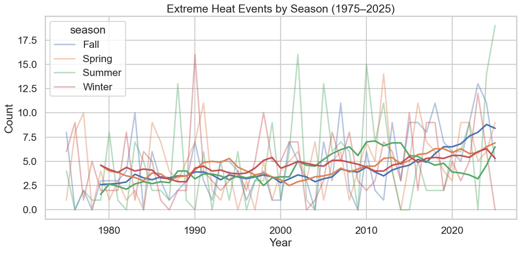

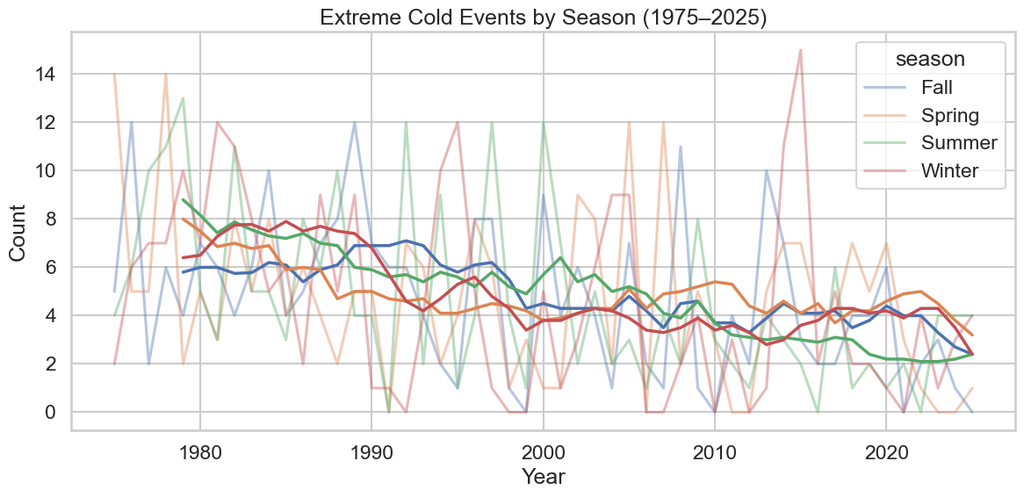

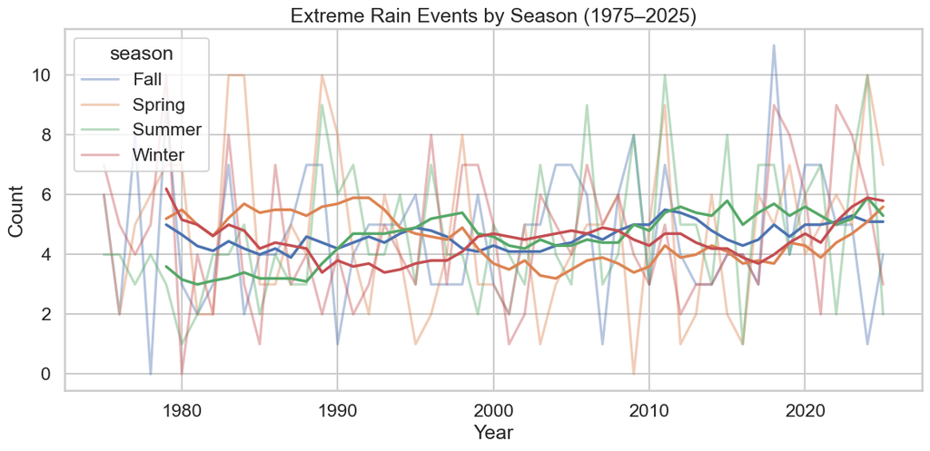

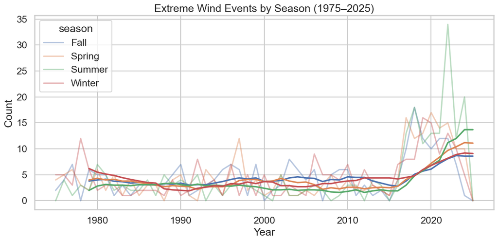

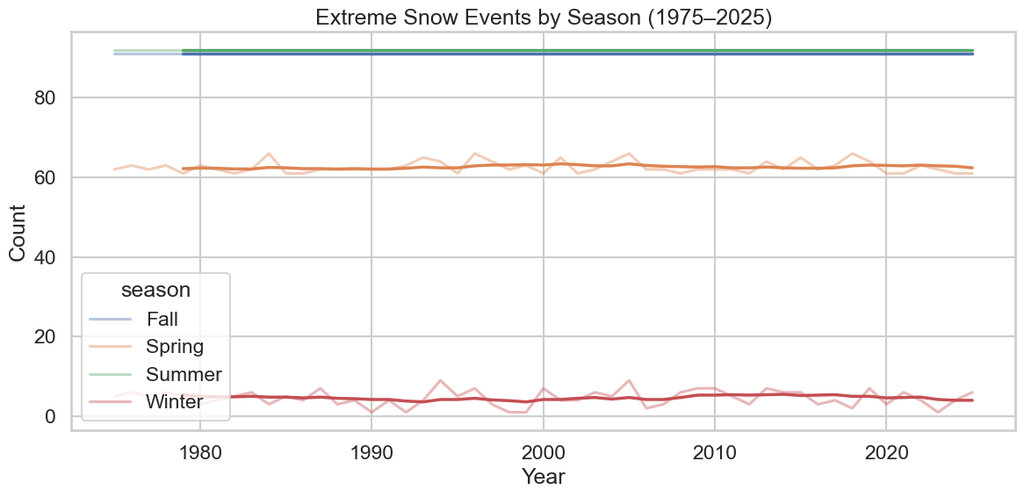

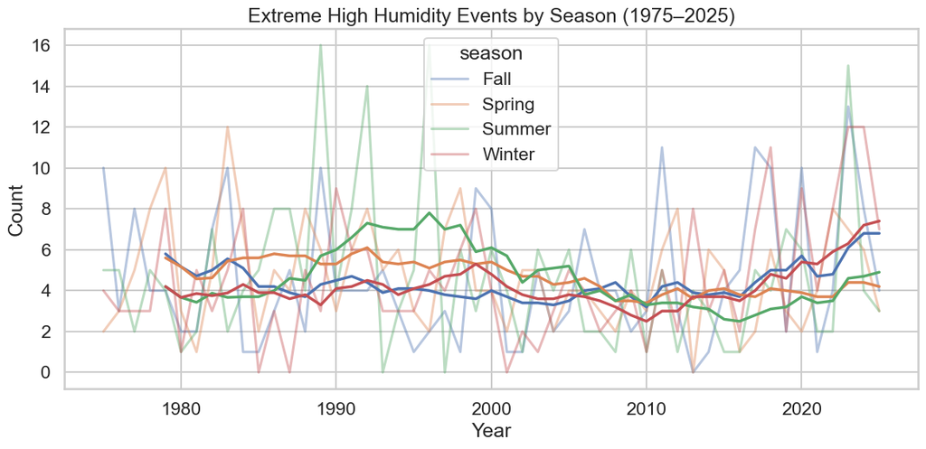

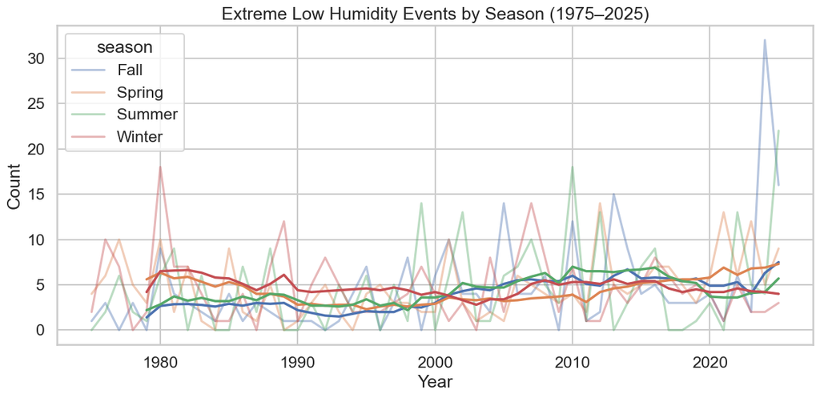

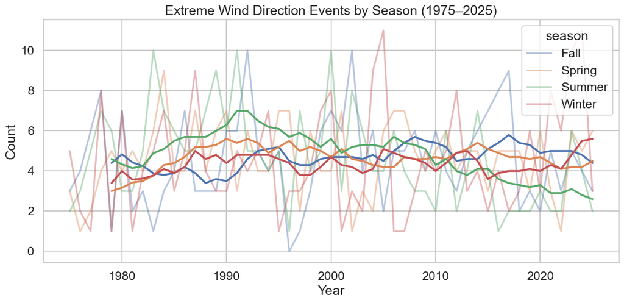

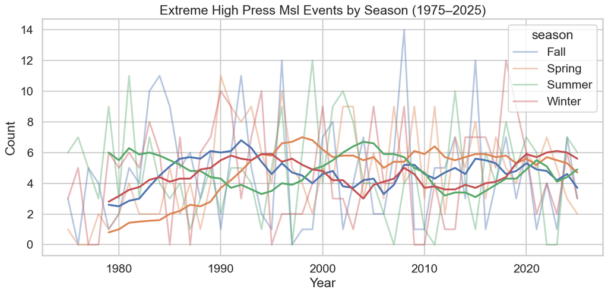

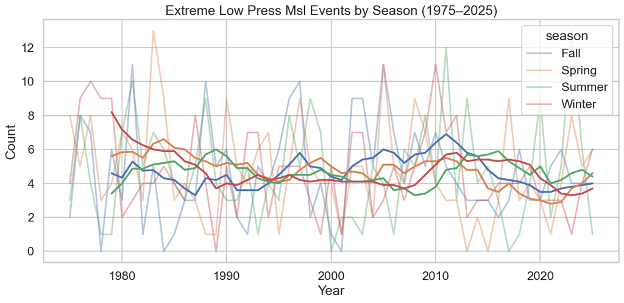

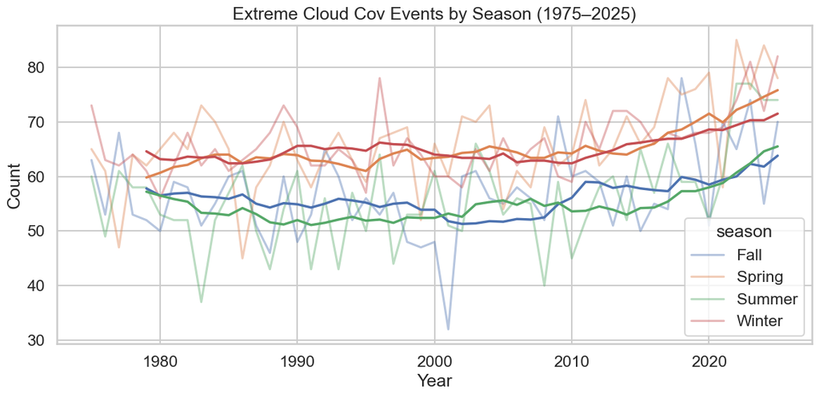

```python
for col in extreme_cols:
    fig, ax = plt.subplots(figsize=(12,6))

    sns.lineplot(data=seasonal_extremes_all,
                 x='year',
                 y=col,
                 hue='season',
                 alpha=0.4,
                 ax=ax)

    # Rolling mean
    seasonal_extremes_all[f'{col}_roll'] = (
        seasonal_extremes_all.groupby('season')[col]
        .transform(lambda x: x.rolling(10, min_periods=5).mean())
    )

    sns.lineplot(data=seasonal_extremes_all,
                 x='year',
                 y=f'{col}_roll',
                 hue='season',
                 linewidth=2.5,
                 legend=False,
                 ax=ax)

    ax.set_title(f"{pretty_names[col]} Events by Season (1975–2025)")
    ax.set_ylabel("Count")
    ax.set_xlabel("Year")

    plt.tight_layout()
    plt.show()
```

**Normalisation for Temporal Comparison:**

Shifting the perspective from counting to probability. For example, instead of asking "How many hot days did we have?", you are asking "What were the chances of a hot day occurring in that specific season?"

**Establishing the "Global" Denominator:**

In any scientific study, time series data is rarely perfect—some years might have missing sensor data (**fortunately not this case**, or months might be shorter than others. Mathematically, we define the Total Observation Window ($N$):

$$N_{y,s} = \text{Count of all recorded days in Year } y, \text{ Season } s$$

Without this step, a year with 365 days of data would look "more extreme" than a year with 200 days of data, simply because there were more opportunities to record an event. **Yet again**, not in our case since that are no missing values **....but mathematically or scientifically sensible in the general case**.

**The Normalization Transform (The "Ratio"):**

$$P_{y,s} = \frac{E_{y,s}}{N_{y,s}}$$

Where:

$E_{y,s}$: The number of extreme events (e.g., Extreme Heat) in that period.

$N_{y,s}$: The total days recorded in that same period.

**Visualizing the "Seasonal Drift":**

By using hue='season', the line plot isn't just showing trends; it’s showing divergence.

The "Gap" Analysis: If the lines for Summer and Fall are moving closer together over the years, it suggests that Fall is "becoming" the old Summer.

The "Volatility" Check: If the lines are jagged, the extremes are erratic year-to-year. If they are smoothing out upward, the climate is shifting to a new, more extreme baseline.

**Summary of the Logic Flow:**

| Logic Step | Mathematical Action | Analytical Intuition |
| --- | --- | --- |
| Grouping | Define the "Whole" ($N$) | Ensures we aren't tricked by missing data |
| Division | Calculate the Ratio ($P$) | Moves from "How many?" to "How likely?" |
| Plotting | Compare Proportions | Visualizes if seasons are losing their distinct boundaries |

Generation of the plots:

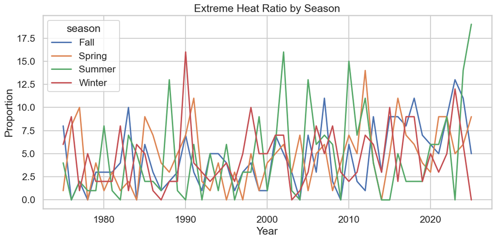

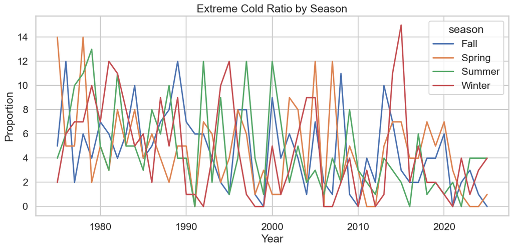

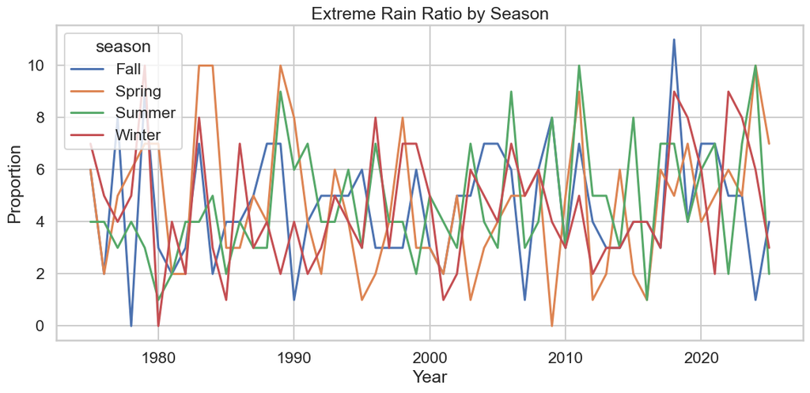

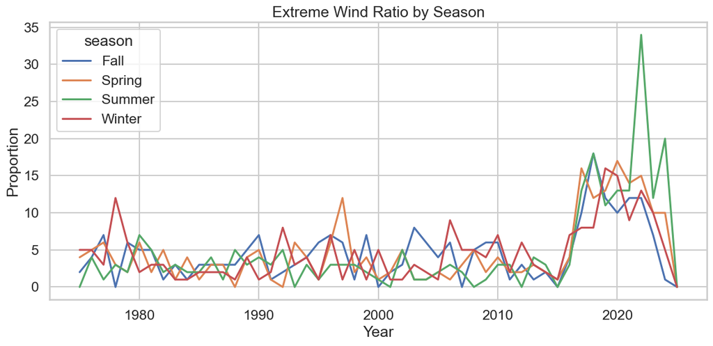

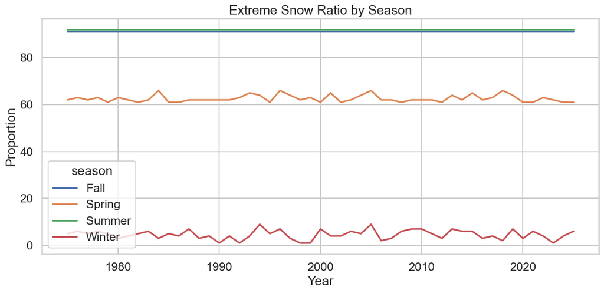

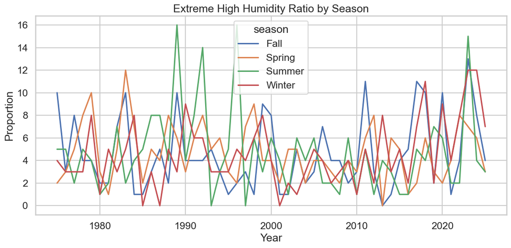

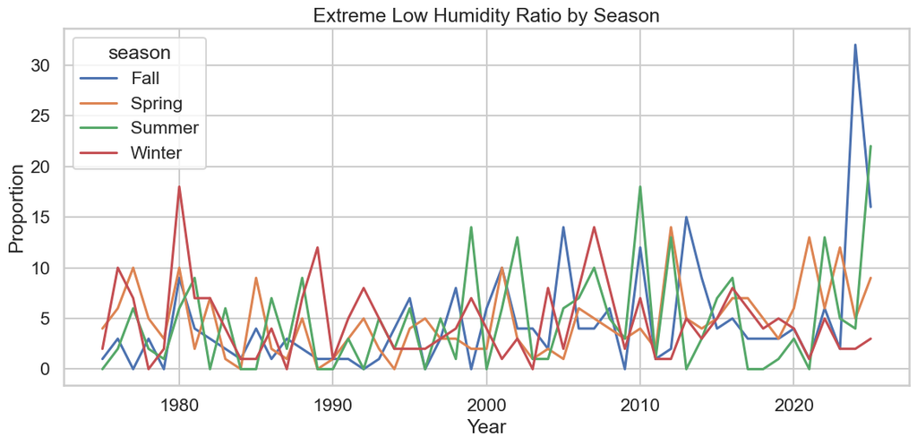

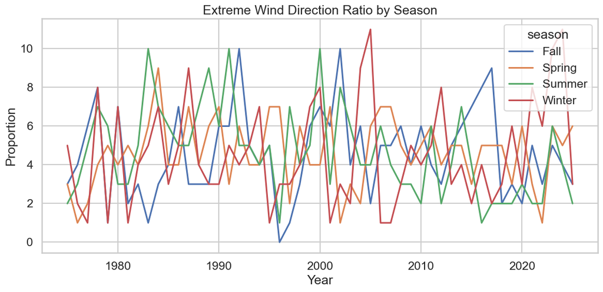

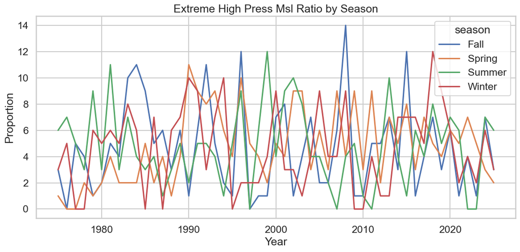

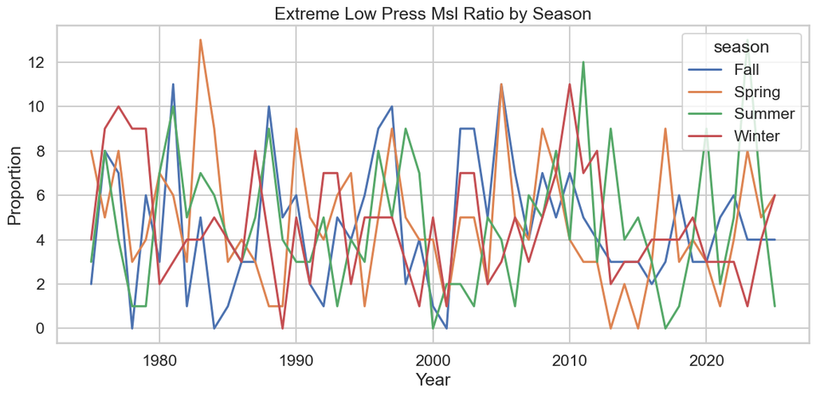

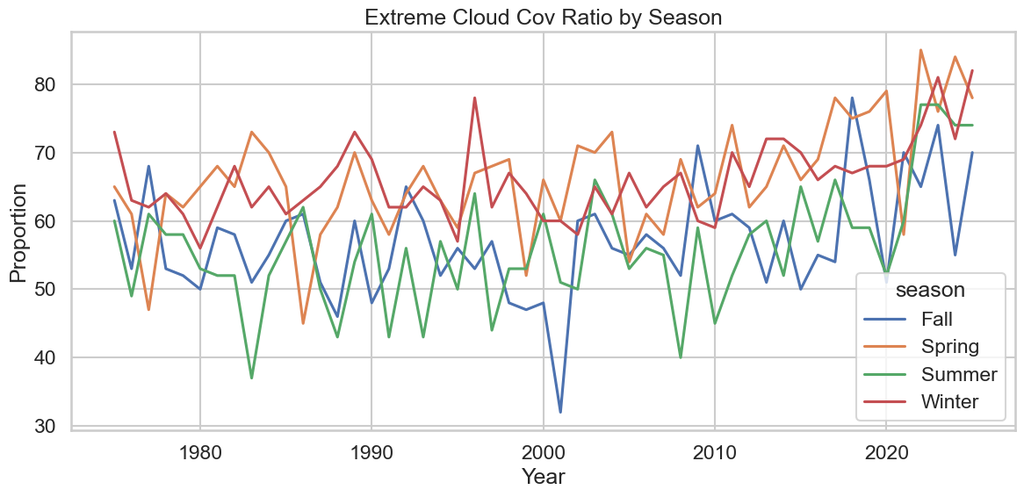

```python
season_counts = seasonal_extremes.groupby(['year','season']).size().reset_index(name='total_days')

for col in extreme_cols:
    temp = seasonal_extremes_all[['year','season',col]].merge(
        season_counts, on=['year','season']
    )

    temp[f'{col}_ratio'] = temp[col] / temp['total_days']

    plt.figure(figsize=(12,6))
    sns.lineplot(data=temp,
                 x='year',
                 y=f'{col}_ratio',
                 hue='season')

    plt.title(f"{pretty_names[col]} Ratio by Season")
    plt.ylabel("Proportion")
    plt.xlabel("Year")

    plt.tight_layout()
    plt.show()
```

### Trend Analysis - Climate Signal (Regression)

To now determine whether the frequency or intensity of a specific extreme is moving up or down relative to the chronological sequence of years.

For example:

Is extreme heat increasing in summers?

Are cold extremes disappearing in winters?

**Applying a Simple Linear Regression (Ordinary Least Squares) to identify how weather extremes change over time:**

For a extreme type (e.g., extreme_heat), using the assumption of a linear relationship between time ($x$) and the occurrence of the extreme event ($y$):

$$y_i = \beta_0 + \beta_1 x_i + \epsilon_i$$

Where:

$y_i$: The value of the extreme column for a specific year/season.

$x_i$: The time index (represented in the code by range(len(y))).

$\beta_0$: The intercept (the value of $y$ when time is 0).

$\beta_1$: The slope (the rate of change over time).

$\epsilon_i$: The error term (residuals).

The function (to be developed) **trend_test** extracts two primary mathematical values:

The Slope ($\beta_1$) - calculated by minimizing the sum of squared residuals:

$$\hat{\beta}_1 = \frac{\sum (x_i - \bar{x})(y_i - \bar{y})}{\sum (x_i - \bar{x})^2}$$

Interpretation: If $\beta_1 > 0$, the extreme event is increasing over time. If $\beta_1 < 0$, it is decreasing.

The p-value ($p$) - for testing the null hypothesis ($H_0: \beta_1 = 0$), which assumes there is no trend.

Significance: If $p < 0.05$, the code labels the trend as "SIGNIFICANT," meaning there is a statistically detectable change over time that is unlikely to have occurred by chance.

```python
import statsmodels.api as sm
import pandas as pd

# 1. Define the list of extreme columns to test
extreme_cols = [
    'extreme_heat', 'extreme_cold', 'extreme_rain', 'extreme_wind',
    'extreme_snow', 'extreme_high_humidity', 'extreme_low_humidity',
    'extreme_wind_direction', 'extreme_high_press_msl',
    'extreme_low_press_msl', 'extreme_cloud_cov'
]

def trend_test(series):
    y = series.values
    # Ensure we have enough data and variation to avoid NaNs;
    # Checking if there is any change in the data. No interest in single or zero unique cases
    if len(y) < 2 or series.nunique() <= 1:
        return 0.0, float('nan')

    X = sm.add_constant(range(len(y)))
    model = sm.OLS(y, X).fit()
    return model.params[1], model.pvalues[1]

# 2. Nested Loop with clear labeling
for col in extreme_cols:
    print(f"\n--- ANALYZING TREND: {col.replace('_', ' ').upper()} ---")

    for season in seasonal_extremes['season'].unique():
        subset = seasonal_extremes[seasonal_extremes['season'] == season]

        # We sort by year to ensure the X-axis (time) is chronological
        subset = subset.sort_values('year')

        slope, pval = trend_test(subset[col])

        # Formatting the output for readability
        status = "SIGNIFICANT" if pval < 0.05 else "not sig."
        if pd.isna(pval):
            print(f"{season:10}: No variation (Constant data)")
        else:
            print(f"{season:10}: Slope = {slope:6.3f} | p = {pval:6.3f} ({status})")
```

```
--- ANALYZING TREND: EXTREME HEAT ---
Fall      : Slope =  0.109 | p =  0.001 (SIGNIFICANT)
Spring    : Slope =  0.066 | p =  0.035 (SIGNIFICANT)
Summer    : Slope =  0.103 | p =  0.023 (SIGNIFICANT)
Winter    : Slope =  0.033 | p =  0.302 (not sig.)

--- ANALYZING TREND: EXTREME COLD ---
Fall      : Slope = -0.090 | p =  0.003 (SIGNIFICANT)
Spring    : Slope = -0.073 | p =  0.029 (SIGNIFICANT)
Summer    : Slope = -0.119 | p =  0.000 (SIGNIFICANT)
Winter    : Slope = -0.091 | p =  0.014 (SIGNIFICANT)

--- ANALYZING TREND: EXTREME RAIN ---
Fall      : Slope =  0.013 | p =  0.550 (not sig.)
Spring    : Slope = -0.004 | p =  0.888 (not sig.)
Summer    : Slope =  0.048 | p =  0.025 (SIGNIFICANT)
Winter    : Slope =  0.020 | p =  0.365 (not sig.)

--- ANALYZING TREND: EXTREME WIND ---
Fall      : Slope =  0.080 | p =  0.023 (SIGNIFICANT)
Spring    : Slope =  0.125 | p =  0.002 (SIGNIFICANT)
Summer    : Slope =  0.193 | p =  0.001 (SIGNIFICANT)
Winter    : Slope =  0.095 | p =  0.008 (SIGNIFICANT)

--- ANALYZING TREND: EXTREME SNOW ---
Fall      : No variation (Constant data)
Spring    : Slope =  0.002 | p =  0.911 (not sig.)
Summer    : No variation (Constant data)
Winter    : Slope = -0.001 | p =  0.974 (not sig.)

--- ANALYZING TREND: EXTREME HIGH HUMIDITY ---
Fall      : Slope =  0.026 | p =  0.416 (not sig.)
Spring    : Slope = -0.028 | p =  0.247 (not sig.)
Summer    : Slope = -0.023 | p =  0.523 (not sig.)
Winter    : Slope =  0.066 | p =  0.017 (SIGNIFICANT)

--- ANALYZING TREND: EXTREME LOW HUMIDITY ---
Fall      : Slope =  0.150 | p =  0.003 (SIGNIFICANT)
Spring    : Slope =  0.063 | p =  0.046 (SIGNIFICANT)
Summer    : Slope =  0.091 | p =  0.060 (not sig.)
```

[output cut: 10 more lines]

```
Spring    : Slope =  0.064 | p =  0.017 (SIGNIFICANT)
Summer    : Slope = -0.018 | p =  0.536 (not sig.)
Winter    : Slope =  0.012 | p =  0.705 (not sig.)

--- ANALYZING TREND: EXTREME LOW PRESS MSL ---
Fall      : Slope =  0.000 | p =  0.995 (not sig.)
Spring    : Slope = -0.039 | p =  0.153 (not sig.)
Summer    : Slope =  0.003 | p =  0.912 (not sig.)
Winter    : Slope = -0.035 | p =  0.139 (not sig.)

--- ANALYZING TREND: EXTREME CLOUD COV ---
Fall      : Slope =  0.161 | p =  0.034 (SIGNIFICANT)
Spring    : Slope =  0.284 | p =  0.000 (SIGNIFICANT)
Summer    : Slope =  0.258 | p =  0.001 (SIGNIFICANT)
Winter    : Slope =  0.171 | p =  0.001 (SIGNIFICANT)
```

Extreme heat is increasing significantly across spring, summer, and fall, while extreme cold is decreasing significantly in all seasons, indicating a systematic shift in the temperature distribution rather than a simple mean warming. This pattern reflects a classic “distributional compression at the cold tail and expansion at the warm tail,” consistent with broader warming-driven changes in variability and persistence of hot conditions.

A second dominant signal is the widespread intensification of wind extremes and cloud cover across all seasons. Wind extremes show significant positive trends year-round, with the strongest increases in summer, suggesting enhanced atmospheric dynamical activity and stronger circulation events. Cloud cover extremes also increase significantly in every season, indicating a strengthening of moisture cycling and more frequent or persistent cloud-producing systems. Together, these results point to a more dynamically active atmosphere.

In contrast, precipitation extremes show a more constrained response, with a significant increase only in summer, while other seasons show no robust trend. Humidity extremes are mixed but suggest increased variability, with both higher high-humidity and higher low-humidity extremes in certain seasons. Overall, the system indicates a coherent climate signal characterized by amplified atmospheric variability: stronger heat extremes, reduced cold extremes, intensified wind and cloud activity, and seasonally selective increases in rainfall extremes, particularly during the convective season.

**Summary Table of Significant Shifts:**

| Weather Type | Primary Trend | Most Affected Season(s) |
| --- | --- | --- |
| Extreme Heat | Increasing | Fall, Spring, Summer |
| Extreme Cold | Decreasing | All Seasons |
| Extreme Rain | Increasing | Summer |
| Extreme Snow | No Conclusion | All Seasons |
| Extreme High Humidity | Increasing | Winter |
| Extreme Low Humidity | Increasing | Fall, Spring, (and maybe) Summer |
| Extreme Wind | Increasing | All Seasons |
| Extreme Cloud Cover | Increasing | All Seasons |
| Extreme wind Direction | Decreasing | Summer |
| Extreme High Pressure | increasing | Spring |
| Extreme Low Pressure | No Conclusion | All Seasons |

The most reliable "signals" in the data are the increase in wind and cloud extremes, and the rise of summer heat paired with the fall of winter cold. These are classic indicators of a shifting climatic baseline.

**NOTE:** the above results only concerns the NYC area.

### Trend Analysis - Climate Signal (Mann-Kendall Trend Test)

To now apply the **Mann-Kendall Trend Test**, which is a non-parametric method. Unlike the previous OLS regression, this does not assume the data follows a normal distribution or a strictly linear path; it focuses on whether the data is monotonically increasing or decreasing (Mann, 1945; Kendall, 1975).

**The Test Statistic ($S$):**

The core of the math is the sign of the difference between all possible pairs of data points ($y_i, y_j$) over time:

$$S = \sum_{i=1}^{n-1} \sum_{j=i+1}^{n} \text{sgn}(y_j - y_i)$$

Where:

$n$ is the number of data points (years).

$\text{sgn}(\theta)$ is $1$ if the value increases, $-1$ if it decreases, and $0$ if it stays the same.

Result: A large positive $S$ indicates an increasing trend; a large negative $S$ indicates a decreasing trend.

**Variance and Significance:**

To determine if the trend is "SIGNIFICANT," the code calculates the variance of $S$, denoted as $V(S)$, and converts it into a Z-score:

$$Z = \begin{cases} \frac{S-1}{\sqrt{V(S)}} & \text{if } S > 0 \\ 0 & \text{if } S = 0 \\ \frac{S+1}{\sqrt{V(S)}} & \text{if } S < 0 \end{cases}$$

p-value ($p$): The probability derived from this Z-score. If $p < 0.05$, the trend is unlikely to be a result of random chance.

The Slope: Usually calculated as Theil-Sen's Slope, which is the median of all slopes between all paired data points.

**Comparison to Previous OLS:**

| Feature | OLS (Linear Regression) | Mann-Kendall (This Code) |
| --- | --- | --- |
| Data Type | Sensitive to outliers | Robust to outliers |
| Trend Shape | Must be a straight line | Any consistent upward/downward "drift" |
| Requirements | Assumes normal distribution | Non-parametric (no distribution assumed) |

The Mann-Kendall method is more robust for environmental and weather data because it isn't easily skewed by one or two "freak" weather years; it looks for the overall direction of the movement.

```python
import pymannkendall as mk
import pandas as pd
import numpy as np

def mk_trend_analysis(series):
    # Standard safety checks
    if series.nunique() <= 1 or len(series) < 3:
        return ("no trend", np.nan, 0.0)

    try:
        res = mk.original_test(series)
        # We wrap this in a tuple explicitly to be safe
        return (str(res.trend), float(res.p), float(res.slope))
    except:
        return ("error", np.nan, 0.0)

# --- THE LOOP ---
for col in extreme_cols:
    print(f"\n{'-'*60}\n METRIC: {col.upper()}\n{'-'*60}")

    for season in seasonal_extremes['season'].unique():
        subset = seasonal_extremes[seasonal_extremes['season'] == season].sort_values('year')

        # 1. Capture the result as a SINGLE object first
        result = mk_trend_analysis(subset[col])

        # 2. Check the length to debug if it fails again
        if len(result) != 3:
            print(f"{season:10} | DEBUG ERROR: Function returned {len(result)} items instead of 3")
            continue

        # 3. Manually assign them
        trend_type, pval, slope = result

        if np.isnan(pval):
            print(f"{season:10} | [No Variation/Insufficient Data]")
        else:
            sig = "SIGNIFICANT" if pval < 0.05 else "not sig."
            print(f"{season:10} | {trend_type.capitalize():11} | Slope: {slope:6.3f} | p: {pval:6.3f} ({sig})")
```

```
------------------------------------------------------------
 METRIC: EXTREME_HEAT
------------------------------------------------------------
Fall       | Increasing  | Slope:  0.105 | p:  0.002 (SIGNIFICANT)
Spring     | Increasing  | Slope:  0.077 | p:  0.019 (SIGNIFICANT)
Summer     | No trend    | Slope:  0.061 | p:  0.068 (not sig.)
Winter     | No trend    | Slope:  0.034 | p:  0.149 (not sig.)

------------------------------------------------------------
 METRIC: EXTREME_COLD
------------------------------------------------------------
Fall       | Decreasing  | Slope: -0.087 | p:  0.004 (SIGNIFICANT)
Spring     | Decreasing  | Slope: -0.062 | p:  0.039 (SIGNIFICANT)
Summer     | Decreasing  | Slope: -0.100 | p:  0.000 (SIGNIFICANT)
Winter     | Decreasing  | Slope: -0.091 | p:  0.012 (SIGNIFICANT)

------------------------------------------------------------
 METRIC: EXTREME_RAIN
------------------------------------------------------------
Fall       | No trend    | Slope:  0.000 | p:  0.516 (not sig.)
Spring     | No trend    | Slope:  0.000 | p:  0.850 (not sig.)
Summer     | No trend    | Slope:  0.037 | p:  0.053 (not sig.)
Winter     | No trend    | Slope:  0.000 | p:  0.445 (not sig.)

------------------------------------------------------------
 METRIC: EXTREME_WIND
------------------------------------------------------------
Fall       | No trend    | Slope:  0.050 | p:  0.141 (not sig.)
Spring     | No trend    | Slope:  0.042 | p:  0.179 (not sig.)
Summer     | No trend    | Slope:  0.033 | p:  0.138 (not sig.)
Winter     | Increasing  | Slope:  0.071 | p:  0.037 (SIGNIFICANT)

------------------------------------------------------------
 METRIC: EXTREME_SNOW
------------------------------------------------------------
Fall       | [No Variation/Insufficient Data]
Spring     | No trend    | Slope:  0.000 | p:  0.899 (not sig.)
Summer     | [No Variation/Insufficient Data]
Winter     | No trend    | Slope:  0.000 | p:  0.908 (not sig.)

```

[output cut: 32 more lines]

```
------------------------------------------------------------
 METRIC: EXTREME_LOW_PRESS_MSL
------------------------------------------------------------
Fall       | No trend    | Slope:  0.000 | p:  0.935 (not sig.)
Spring     | No trend    | Slope: -0.032 | p:  0.161 (not sig.)
Summer     | No trend    | Slope:  0.000 | p:  0.800 (not sig.)
Winter     | No trend    | Slope:  0.000 | p:  0.233 (not sig.)

------------------------------------------------------------
 METRIC: EXTREME_CLOUD_COV
------------------------------------------------------------
Fall       | No trend    | Slope:  0.136 | p:  0.084 (not sig.)
Spring     | Increasing  | Slope:  0.286 | p:  0.000 (SIGNIFICANT)
Summer     | Increasing  | Slope:  0.212 | p:  0.008 (SIGNIFICANT)
Winter     | Increasing  | Slope:  0.167 | p:  0.001 (SIGNIFICANT)
```

The Mann-Kendall (MK) analysis provides a more conservative, robust look at your data compared to the previous OLS regression. Because MK looks for monotonic trends (consistent direction) rather than just a linear fit, it filters out some of the "noise" that OLS might have labeled as significant.

The results indicate a selective and seasonally structured intensification of climate extremes, rather than a uniform change across all variables. The strongest and most consistent signal is in temperature extremes: extreme heat increases significantly in fall and spring, while extreme cold shows a robust and statistically significant decrease in all seasons. This confirms a clear redistribution of the temperature distribution, with systematic erosion of cold extremes and partial strengthening of warm extremes, though the warming signal is not yet significant in summer and winter at the extreme tail level.

Moisture-related and atmospheric state variables show more heterogeneous behavior. Extreme cloud cover exhibits one of the clearest signals of change, with significant increases in spring, summer, and winter, suggesting a strengthening of convective activity and moisture cycling in multiple seasons. In contrast, extreme rainfall shows no statistically significant trend in any season, implying that while cloudiness and atmospheric moisture presence are increasing, this is not yet translating into a consistent intensification of rainfall extremes. Humidity extremes also show limited structure, with only low-humidity extremes increasing significantly in fall and spring, indicating enhanced atmospheric dryness variability rather than a uniform moistening trend.

Dynamical variables reveal more localized and season-specific shifts. Wind extremes are largely stable except for a significant increase in winter, suggesting that dynamical intensification is seasonal rather than global. Pressure extremes show only weak and isolated changes, with an increase in high-pressure extremes in spring but no consistent deepening of low-pressure systems. Wind direction extremes shift only in summer, while most other seasons remain stable. Overall, the system suggests a climate response characterized by strong temperature tail asymmetry, widespread increases in cloud activity, and highly seasonal dynamical changes, with precipitation extremes remaining surprisingly stable relative to other components of the climate system.

**Summary Table (Mann-Kendall Results)**

| Metric | Trend | Season(s) |
| --- | --- | --- |
| Extreme Heat | Increasing | Fall, Spring |
| Extreme Cold | Decreasing | All Seasons |
| Extreme Rain | No Conclusion | All Seasons |
| Extreme Wind | Increasing | Winter |
| Extreme Snow | No Conclusion | All Seasons |
| Extreme High Humidity | No Conclusion | All Seasons |
| Extreme Low Humidity | Increasing | Fall, Spring |
| Extreme Wind Direction | Decreasing | Summer |
| Extreme High Pressure MSL | Increasing | Spring |
| Extreme Low Pressure MSL | No Conclusion | All Seasons |
| Cloud Cover | Increasing | Spring, Summer, Winter |

**NOTE:** the above results only concerns the NYC area.

### Extreme Weather Across Seasons - Convergence or Divergence

To determine if extreme events are converging (becoming more similar across seasons) or diverging (seasonal differences are becoming more polarized), there's need to track the variance or spread (standard deviation) between seasons over time. Using a Standard Deviation ($\sigma$) trend is a mathematically sound way to confirm convergence: a shrinking $\sigma$ over time literally means the seasons are becoming more similar.

Convergence would mean that the "risk" of an extreme event is becoming more uniform across the entire year, rather than being confined to a specific peak season.

**How to interpret the pending results:**

For example, if the counts of 'extreme_heat' are converging it suggests that such is no longer just a Summer problem. For example, if Spring and Fall 'extreme_heat' count cases are rising faster than Summer, the "heat season" is expanding, making the seasons look more alike in the data.

If they are diverging: It suggests that the extremes are becoming even more concentrated in specific times of the year, potentially making the "peak" seasons much more hazardous compared to the "off-peak" seasons.

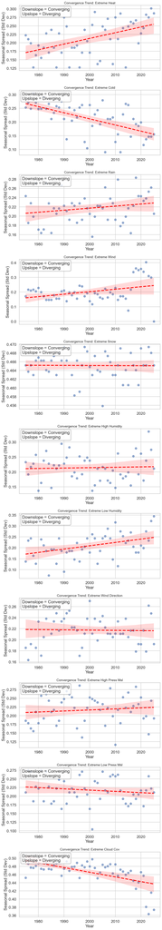

```python
import matplotlib.pyplot as plt
import seaborn as sns

# 1. Define the list of extreme columns to test
extreme_cols = [
    'extreme_heat', 'extreme_cold', 'extreme_rain', 'extreme_wind',
    'extreme_snow', 'extreme_high_humidity', 'extreme_low_humidity',
    'extreme_wind_direction', 'extreme_high_press_msl',
    'extreme_low_press_msl', 'extreme_cloud_cov'
]

# Set up a grid for the plots
n_extremes = len(extreme_cols)
fig, axes = plt.subplots(n_extremes, 1, figsize=(10, 5 * n_extremes))

# If only one extreme, axes won't be a list, so we wrap it
if n_extremes == 1: axes = [axes]

for i, ext in enumerate(extreme_cols):
    # 1. Calculate the spread between seasons per year
    # We group by year and take the standard deviation of the ratios
    spread_data = seasons_df.groupby('year')[ext].std().reset_index(name='std_dev')

    # 2. Plot the trend
    sns.regplot(data=spread_data, x='year', y='std_dev', ax=axes[i],
                scatter_kws={'alpha':0.6}, line_kws={'color':'red', 'linestyle':'--'})

    # 3. Aesthetics
    axes[i].set_title(f'Convergence Trend: {ext.replace("_", " ").title()}', fontsize=14)
    axes[i].set_ylabel('Seasonal Spread (Std Dev)')
    axes[i].set_xlabel('Year')

    # Annotation logic for the user
    axes[i].annotate('Downslope = Converging\nUpslope = Diverging',
                     xy=(0.02, 0.85), xycoords='axes fraction',
                     bbox=dict(boxstyle="round", fc="white", ec="gray", alpha=0.8))

plt.tight_layout()
plt.show()
```

**NOTE:** the above results only concerns the NYC area.

### Applying & Operator Logic with Weather Data

Set theory (Enderton and Stoll, 2026) serves as a foundational mathematical framework for transforming raw weather data into actionable intelligence, such as recognising complexity or phenomenon categorisation. By defining sets of weather parameters (e.g., rainfall, temperature, wind) and applying Boolean logic or fuzzy set membership, analysts can establish rigid "indicators" for dangerous conditions. This approach allows for the categorisation of complex weather scenarios into discrete sets (e.g., "drought," "storm", "blizzard", etc.).

To analyse the shifting patterns of a climate, one can move beyond looking at individual weather variables in isolation. Specific atmospheric events rarely happen in a non-complementary manner; instead, they interact, overlap, and compound. By applying a **&-Operator Logic Model**, we can transform raw binary data—simple "yes/no" outcomes for extremes—into a sophisticated map/rule for signature events.

**The Intersection Logic (&): The Synergy Lens (identification for signature events):**

The **Intersection** operator is the most precise filter, looking only for the "Perfect Storm" where specific independent variables lock together.

Analytical Goal: To track Signature Phenomena (like Blizzards or Tropical Storms).

Intuition: It captures the specific atmospheric "handshake" required for complex, high-impact disasters to occur.

This model looks for the rare "Perfect Storm" where independent variables lock together. Formula: $Y = X_1 \cap X_2$

Best Use: Predicting High-Impact Disasters. If the Mann-Kendall test shows a significant trend in the & based variables, it means the atmosphere is becoming more "synchronized" in its delivery of hazards.

The Mathematical Truth Table for (&) or ($\cap$) --

| Heat $(H)$ | Rain $(R)$ | Intersection ($H \cap R$) |
| --- | --- | --- |
| 0 (No) | 0 (No) | 0 |
| 1 (Yes) | 0 (No) | 0 |
| 0 (No) | 1 (Yes) | 0 |
| 1 (Yes) | 1 (Yes) | 1 |

#### Developing Variables to Identify Weather Phenomena with the "&" Logic Operator

Many weather phenomena are not instantaneous, they are accumulated or persistent processes. Using rolling windows will make the features pursuit much closer to real atmospheric behavior.

**Drought (Persistence + Deficit): Meteorological Drought (WMO-aligned)**

Drought is not “no rain today”, it’s: **sustained dryness over time**

For General/Meteorological Drought (Rapid Onset): 3-month to 6-month rolling periods are considered best for identifying the initial onset of meteorological drought, which impacts soil moisture and agricultural conditions. The World Meteorological Organization (WMO) recommends using SPI at multiple timescales (e.g., 3, 6, 12, 24 months) to capture both short- and long-term droughts (Cavus, Stahl, and Aksoy, 2022). Applying a 3-month (~90d) and 6-month (~180d) rainfall anomalies.

A logic needs to be developed to dentify periods of meteorological drought by evaluating environmental stress across three distinct temporal scales: short-term heat, medium-term moisture deficits, and long-term water cycles.

1. The process begins by calculating the total accumulated rainfall over two specific windows: 90 days and 180 days. Instead of looking at daily rain, this "rolling" approach smooths out volatile weather events to reveal the underlying moisture trend. The 90-day window captures seasonal shifts, while the 180-day window provides a broader view of the hydrological state.
2. Statistical Normalization (The Z-Score).

   To determine if a rainfall total is actually "low," the values are standardized using a Z-score formula:

$$\text{Z} = \frac{x - \mu}{\sigma}$$

Where:

$x$ is the current rolling total.

$\mu$ is the historical average for that period.

$\sigma$ is the standard deviation.

By converting raw millimeters of rain into standard deviations from the mean, the data identifies how "extreme" the current dryness is relative to historical norms. A value of -1 indicates that the rainfall is one full standard deviation below the average, which is a common threshold for a moderate deficit.

3. The Compound Drought Trigger

   The final classification uses a binary logic gate (an "AND" condition) to identify a high-stress environment. A drought is officially flagged only when two specific conditions coexist:

   Hydrological Deficit: The 90-day rainfall Z-score must be less than -1 (significantly drier than usual).

   Thermal Stress: The average maximum temperature over the last 30 days must exceed the 70th percentile of all recorded temperatures.

This mimics SPI-3 / SPI-6 behaviour.

```python
# Rolling rainfall totals
rain_90d = seasons_df["rain_sum"].rolling(90).sum()
rain_180d = seasons_df["rain_sum"].rolling(180).sum()

# Standardized Precipitation Index proxy (z-score)
rain_90d_z = (rain_90d - rain_90d.mean()) / rain_90d.std()
rain_180d_z = (rain_180d - rain_180d.mean()) / rain_180d.std()

seasons_df["met_drought"] = (
    (rain_90d_z < -1) &  # moderate drought
    (seasons_df["temperature_2m_max"].rolling(30).mean() >
     seasons_df["temperature_2m_max"].quantile(0.7))
)

seasons_df['met_drought'].unique()
```

```
array([False,  True])
```

**Flash Flood Proxy (data limitation: daily resolution)**

The logic identifies flash flood events by filtering for atmospheric conditions that represent the extreme upper limit of a region's weather patterns. Rather than using a fixed rainfall amount, it relies on local statistical probability and saturation levels.

1. Statistical Extremity (The 98th Percentile)

   The primary trigger is based on a percentile threshold rather than a hard number (like 50mm). By targeting the 98th percentile of daily rainfall, the logic isolates the top 2% of the heaviest rain events recorded in the dataset.

   This makes the detection adaptive:

   ```
   In a desert, the 98th percentile might be a small but sudden burst.

   In a rainforest, the 98th percentile represents a massive tropical deluge.
   ```

In both cases, it identifies an "extreme" event relative to what the local landscape is equipped to handle.

Papagiannaki, K. et al. (2022)

2. Atmospheric Saturation (Relative Humidity)

   Heavy rain alone doesn't always cause a flash flood; the environment's ability to evaporate that water matters. The second condition requires the maximum relative humidity to be above 90%.

   When humidity is this high:

   ```
   The air is nearly "full" of water vapor.

   Evaporation rates drop significantly.

   The ground is often already damp or the air is primed for high-intensity precipitation.
   ```

3. The Flash Flood Intersection

   A flash flood is flagged only when these two factors occur simultaneously. This "compound logic" ensures that the model ignores heavy rain on very dry, low-humidity days (where the ground might absorb the water quickly) and instead focuses on high-moisture environments where extreme rainfall is likely to result in immediate surface runoff and flooding.

It's possible to approximate sub-daily intensity using extreme daily rainfall:

```python
seasons_df["flash_flood"] = (
    (seasons_df["rain_sum"] > seasons_df["rain_sum"].quantile(0.98)) &
    (seasons_df["relative_humidity_2m_max"] > 90)
)

seasons_df['flash_flood'].unique()
```

```
array([False,  True])
```

**Blizzard Proxy (NWS flanking construction adopted)**

The National Weather Service defines a blizzard as a storm which contains large amounts of snow OR blowing snow, with winds in excess of 56 km/hr and visibilities of less than 1/4 mile for at least 3 hours (NOAA NWS, n.d.).

Since the data applied is daily, there's need to be innovative in a conservative manner.

Wind speeds typically follow a skewed distribution (often a Weibull distribution), where the average is higher than the median because occasional high-speed gusts pull the mean upward.

For persistent overcast (large system) in winter, during frontal passages, or in temperate maritime climates, greater than 80% cloud cover can last for 2 to 3 days or longer. If 2 to 6 inches is typical, such translates to 5 to 15 centimeters; consistently recognised for conventional characterisation of the phenomenon. Additionally, the logic requires a combination of precipitation, high-velocity wind, and sustained atmospheric density (high cloud cover as proxy) to define a severe winter storm.

```python
mean = daily_weather_data_75_2025['wind_speed_10m_max'].mean()

median = daily_weather_data_75_2025['wind_speed_10m_max'].median()

# If 56 km/h minimum is the cutoff, them median speed for that day is.....
target_speed = (median/mean) * 56
target_speed

# Realistically, wind speed will not always be at least 56 km/h.
```

```
np.float32(52.49023)
```

```python
seasons_df["blizzard"] = (
    (seasons_df["snowfall_sum"] >= 5) &
    (seasons_df["wind_speed_10m_max"] > 52) &  # km/h threshold
    (seasons_df["cloud_cover_max"] > 80)
)

seasons_df['blizzard'].unique()
```

```
array([False,  True])
```

**Ice Storm Proxy**

The logic identifies **ice storm** events by detecting a precise "atmospheric sweet spot" where liquid precipitation meets near-freezing surface temperatures. It ignores standard snowstorms or simple rain, focusing instead on the specific conditions required for freezing rain and significant ice accretion.

1. The Thermal "Freezing Point" Window

   The most critical factor for an ice storm is the temperature at the surface. The logic calculates a 3-day rolling average of minimum temperatures and checks if it falls strictly between -2°C and 2°C.

   This narrow window is essential because --

   Above 2°C: The precipitation remains liquid and simply results in a cold rain.

   Below -2°C: The atmosphere is usually cold enough for precipitation to fall as snow or sleet.

   Within the window: Rain can fall through a warm layer aloft and then "supercool" or freeze instantly upon contact with the chilled ground and infrastructure.
2. High-Volume Precipitation (The 90th Percentile)

   To distinguish a minor glaze from a "storm," the logic looks at the total rainfall over a 3-day window. It compares this total to the 90th percentile of all rainfall events in the dataset. This ensures that the event is categorized as a storm only if the volume of liquid is in the top 10% of historical records, indicating enough water to cause heavy ice buildup on power lines and trees.
3. Maximum Saturation (Humidity)

   The final requirement is a maximum relative humidity exceeding 90%. This serves two purposes --

   Saturation: It confirms the air mass is fully saturated, which is necessary for sustained, heavy precipitation.

   Prevents Evaporation: High humidity prevents the "evaporative cooling" that might otherwise turn the rain into snow or cause the water to dry up before it can form a thick layer of ice.

```python
rain_3d = seasons_df["rain_sum"].rolling(3).sum()
temp_min_3d = seasons_df["temperature_2m_min"].rolling(3).mean()

seasons_df["ice_storm"] = (
    (temp_min_3d.between(-2, 2)) &
    (rain_3d > rain_3d.quantile(0.9)) &
    (seasons_df["relative_humidity_2m_max"] > 90)
)

seasons_df['ice_storm'].unique()
```

```
array([False,  True])
```

## Regime Detection - Hidden Markov Model (HMM) and Pursuit of a Markov-Switching Vector Error Correction Model (MS-VECM)

### Hidden Regime Process (HMM core)

A Hidden Markov Model (HMM) for regime processes is a statistical framework used to uncover hidden, unobservable states (regimes) that drive observable data (Baum and Petrie, 1966). It is commonly applied in finance to distinguish between market states—such as high-volatility, low-volatility, bull, or bear markets—based on observable inputs like price returns and volume. HMM is also applicable to meteorological and climatology interests.

**Core Concepts of HMM Regime Processes:**

1. Hidden States (Regimes): These are the underlying, unseen conditions (e.g., "Rainy Season," "Dry Season", "Temperate Climate seasons", **or more micro level phenomena**) that the model aims to infer.
2. Observations (Features): The visible data, such as temperature, precipitation types, winds, pressure levels, etc., that are generated by the hidden regimes.
3. Markov Chain (Memoryless): The model assumes the current state depends only on the previous state. This implies that the regime tomorrow depends only on the regime today, not on the entire history of the ambiance.
4. Emission Probabilities: Each regime has its own statistical distribution (e.g., Gaussian or types with general skewness and kurtosis) that generates the observable data. For example, in finance, a "Bear" regime might have a high-volatility emission distribution, while a "Bull" regime has low volatility.
5. Transition Matrix: Defines the likelihood of switching from one regime to another (e.g., the probability of switching from one season to the next or remaining in the same state).

**Hidden Regime Process (HMM core)**:

Let:

1. $S_t \in \{1,\,,2\,...\,,K\} = $ hidden regime (normal, extreme, etc.)
2. $X_t \in \mathbb{R}^n = $ observed weather vector

State Dynamics:

$$P(S_t = j | S_{t-1} = i) = p_{ij}$$

Observational Model:

$$X_t | S_t = k \sim \mathcal{N}(\mu_k, \Sigma_k) $$

Where:

1. Each regime = mixture of Gaussians
2. Such captures skewness + heavy tails

Such constitution is the **Gaussian Mixture HMM (GMM-HMM)** for regime detection. **NOTE:** will not be adopting a Gaussian framework for simplicity because from prior observations of the weather variables there's respectable asymmetry and kurtosis.

**Regime Interpretation:**

Each regime corresponds to different parameter sets:

$$(\mu_k\,,\,\Sigma_k)$$

1. “Normal regime” $\rightarrow$ moderate mean, low variance
2. “Extreme regime” $\rightarrow$ shifted mean and/or high variance

**Dynamic Dependence (MS-VAR idea):**

To introduce time dependence:

$$X_t = A_{S_t}X_{t-1} + \epsilon_t\,\,\,,\epsilon_t\,\sim\,N(0\,,\,\Sigma_{s_t})$$

Each regime has its own dynamics $A_k$.

### MS-VECM (Cointegration + Regimes)

A Markov-Switching Vector Error Correction Model (MS-VECM) is a sophisticated econometric tool that combines two powerful concepts: Vector Error Correction Models (VECM), which model long-run equilibrium relationships between non-stationary time series, and Markov-Switching (MS) models, which allow for sudden, probabilistic structural breaks or shifts in the dynamics of that relationship (Phoong, Ismail, and Sek, 2014).

The core idea is to allow the parameters of a VECM—such as the intercept, adjustment speed, or variance—to switch between different "regimes" (e.g., expansion vs. recession) according to an unobserved (hidden) Markov process.

**Core Ideas and Components:**

1. VECM Foundation (Long-Run & Short-Run): MS-VECM starts with the idea that non-stationary time series are cointegrated, sharing a long-run equilibrium (e.g., oil and gold prices affecting stock markets).
2. Regime Switching (Non-Linearity): It addresses the limitation of a standard linear VECM (which assumes constant parameters) by allowing the system to shift between different structural regimes (e.g., two or three distinct phases).
3. Markov Chain Structure: The transition between regimes is not assumed to be known (like in a dummy variable model), but is modeled as a stochastic, hidden Markov chain. This makes the model more reliable in capturing sudden market changes.
4. Error Correction Mechanism: Each regime has its own error correction mechanism, meaning that if a shock causes a divergence from the long-run equilibrium, the system adjusts back toward equilibrium, but with a speed specific to the current regime.

**Advantages:**

1. Can handle non-linear relationships among variables.
2. Captures Structural Changes: Ideal for data which often undergo sudden shifts, such as climate shifts or extreme phrenomena-driven structural changes.
3. Flexible Dynamics: It captures both the long-run cointegration and the short-run deviations that vary over time, offering a more flexible model compared to linear VECM.
4. Identifies "Hidden" States: It helps to identify regimes even when they are not directly observed in the data.

**IF** variables are cointegrated:

$$\Delta X_t = \Pi_{S_t}\, X_{t-1} + \sum_{i=1}^{p-1} \Gamma_{i,\, S_t}\, \Delta X_{t-i} + \epsilon_t$$

Where:

$\Pi_{St} = \alpha_{St} \beta'$

Interpretation:

1. $\beta' X_{t-1}\,\rightarrow\, $ long-run equilibrium
2. $\alpha_{S_t}\,\rightarrow\, $ regime-dependent adjustment speed

### Full Unified Model

Hidden States:

$$S_t\,\sim\,\text{Markov}(P)$$

Observations:

$$\Delta X_{t} = \alpha\,S_{t}^{\beta'}\, X_{t-1} + \Gamma_{S_t}\, \Delta X_{t-1} + \epsilon_{t}$$

$$\epsilon_t\,\sim\,N(0,\,\Sigma_{S_t})$$

### The Idea

1. HMM part $\rightarrow$ detects regimes (normal vs extreme)
2. MS-VECM part $\rightarrow$ models:

   equilibrium relationships

   how they change during extremes

### Minimal Practical Version - the simplest usable structure:

1. Estimate HMM:

$$P(s_t | X_t)$$

2. Conditional model:

$$X_t | S_t\,\,=\,\,k\,\sim\,\text{VECM}_k$$

### Transparency:

Regimes Effect:

1. mean $(\mu)$
2. variance $(\Sigma)$
3. dynamics $(A\,,\,\Gamma)$
4. equilibrium adjustement $(\alpha)$

Such above permits the unification of:

1. extreme detection
2. time dynamics
3. structural shifts

Feature Identification:

```python
seasons_df.info()
```

```
<class 'pandas.core.frame.DataFrame'>
RangeIndex: 18628 entries, 0 to 18627
Data columns (total 30 columns):
 #   Column                       Non-Null Count  Dtype
---  ------                       --------------  -----
 0   date                         18628 non-null  datetime64[ns, UTC]
 1   temperature_2m_max           18628 non-null  float32
 2   temperature_2m_min           18628 non-null  float32
 3   rain_sum                     18628 non-null  float32
 4   snowfall_sum                 18628 non-null  float32
 5   wind_speed_10m_max           18628 non-null  float32
 6   wind_direction_10m_dominant  18628 non-null  float32
 7   relative_humidity_2m_max     18628 non-null  float32
 8   relative_humidity_2m_min     18628 non-null  float32
 9   pressure_msl_max             18628 non-null  float32
```

[output cut: 22 more lines]

#### Features Preferences:

**Statistical De-seasoning via Climatological Normalisation**

Applying a Discrete Grouping to define "normal."

The Climatological Mean ($\mu_m$)First, we define a baseline for each specific month. If we have a dataset spanning several years, we group every observation belonging to the same month (e.g., every day in January across 10 years) and calculate their average. The mean for a specific month $m$ is defined as:

$$\mu_m = \frac{1}{N_m} \sum_{i=1}^{N_m} T_{i,m}$$

Where:

$N_m$ is the total number of days recorded for that specific month across the entire history.

$T_{i,m}$ represents each individual temperature reading within those months.

The anomaly (or "residual") is the difference between what actually happened on a specific day and the average of what usually happens during that month.

$$T'_{i,m} = T_{i,m} - \mu_m$$

$\mu_{m}$: The arithmetic mean of all temperatures recorded in that specific month across your entire dataset can be viewed as the "Climatological Mean".

By performing this subtraction, the "Seasonal Signal"—the massive wave that moves from cold winters to hot summers—is mathematically removed.

Mathematically, this transformation changes the nature of your variables in three critical ways:

1. The expected value of your new variable ($T'$) is now $0$.

   If $T'_{i,m} = 0$, the day was perfectly average.

   If $T'_{i,m} > 0$, the day was warmer than the monthly norm.

   If $T'_{i,m} < 0$, the day was cooler than the monthly norm.
2. While the "position" of the data changes (it shifts to zero), the Variance ($\sigma^2$)—the "spread" of how much the temperature fluctuates—remains intact. This allows a Hidden Markov Model to focus entirely on the volatility and extremes of the weather rather than the predictable calendar.
3. Raw temperatures are highly "autocorrelated"—today’s temperature is very likely to be similar to yesterday's because they are in the same season. By subtracting the monthly mean, you reduce this seasonal dependency. This makes it easier for a mathematical model to identify State Transitions (e.g., a sudden shift from a "Stable" regime to a "Heatwave" regime).

In essence, you are telling the math: "Ignore the fact that it is July. Given that it IS July, how unusual is this specific afternoon?" This isolates the "Weather" from the "Climate."

```python
import numpy as np

# Copy data
X = seasons_df.copy()

# --- 1. Temperature anomaly (monthly climatology) ---
monthly_temp_mean = X.groupby('month')['temperature_2m_max'].transform('mean')
X['temp_anom'] = X['temperature_2m_max'] - monthly_temp_mean

# --- 2. Pressure tendency for dynamic (1-step difference) ---
X['pressure_tendency'] = X['pressure_msl_min'].diff()
       # Regimes are driven by dynamics, not absolute pressure. To capture dynamical regimes instead of static states

# --- 3. Final feature set ---
X_model = X[[
    'temp_anom',
    'rain_sum',
    'wind_speed_10m_max',
    'pressure_msl_min',
    'pressure_tendency'
]]

#--- 4. Clip extreme values (rain especially)

def clip_upper_quantile(df, q=0.99, exclude_cols=None):
    df_clipped = df.copy()

    if exclude_cols is None:
        exclude_cols = []

    # Select numeric columns
    num_cols = df_clipped.select_dtypes(include=['number']).columns

    # Columns to clip
    cols_to_clip = [col for col in num_cols if col not in exclude_cols]

    # Compute upper bounds
    upper_bounds = df_clipped[cols_to_clip].quantile(q)

    # Apply clipping
    df_clipped[cols_to_clip] = df_clipped[cols_to_clip].clip(
        upper=upper_bounds,
        axis=1
    )

    return df_clipped

X_model_clipped = clip_upper_quantile(
    X_model,
    q=0.99,
    exclude_cols=['pressure_tendency']
)

# Optional: fill first NaN from diff
X_model_clipped['pressure_tendency'] = X_model_clipped['pressure_tendency'].fillna(0)
```

Checking correlations among the features:

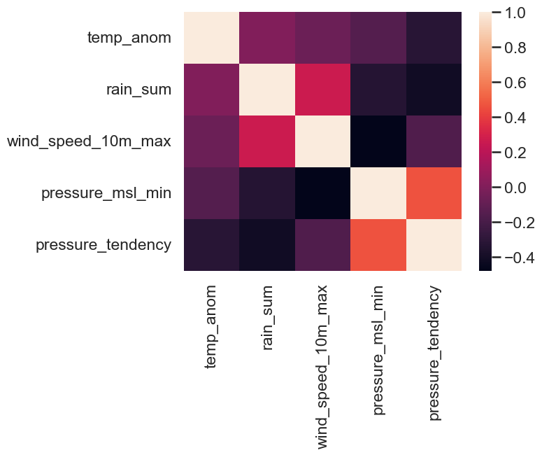

```python
import seaborn as sns
sns.heatmap(X_model_clipped.corr())
```

```python
from sklearn.preprocessing import StandardScaler

scaler = StandardScaler()
X_scaled = scaler.fit_transform(X_model_clipped)
```

Observing the distribution of for each scaled attribute:

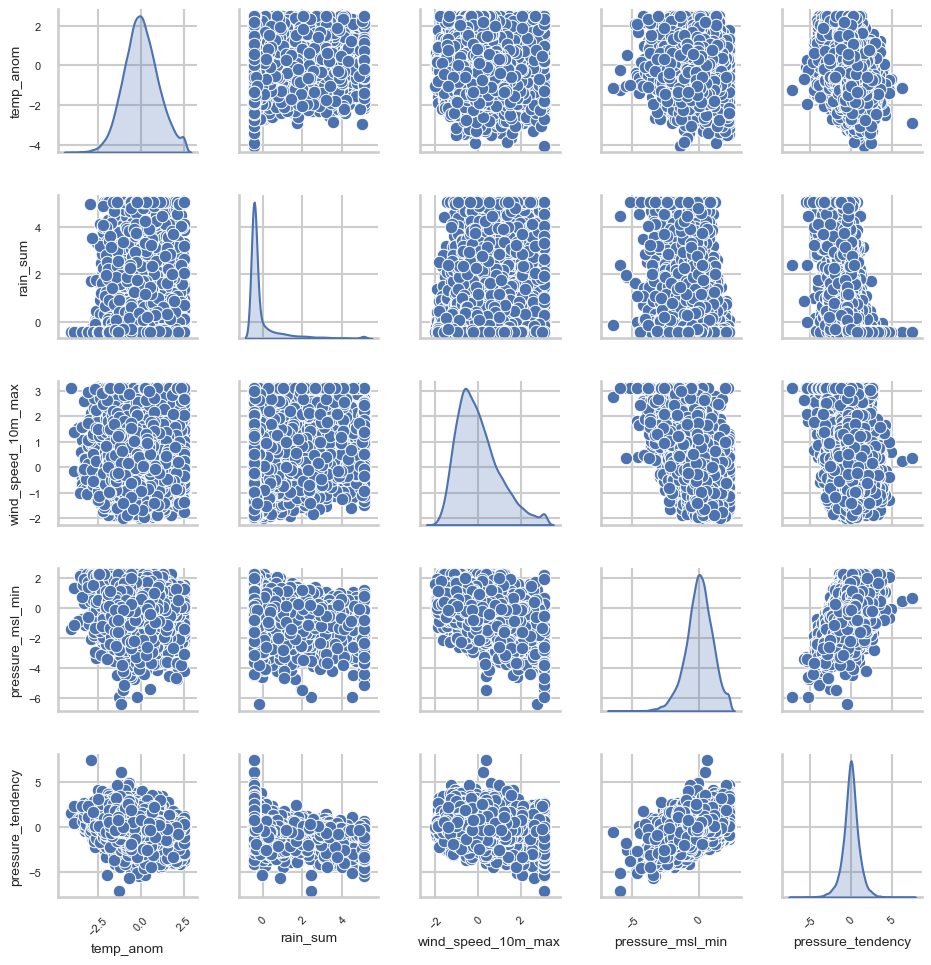

```python
import seaborn as sns
import matplotlib.pyplot as plt

# Recreate DataFrame with original column names
X_scaled_df = pd.DataFrame(X_scaled, columns=X_model_clipped.columns)

# 1. Create the pairplot
# We use 'height' to control the overall scale of the subplots
g = sns.pairplot(X_scaled_df, diag_kind='kde', height=2)

# 2. Iterate through the axes to shrink labels and ticks
for ax in g.axes.flatten():
    if ax is not None:
        # Shrink the Variable Names (e.g., 'temp_anom')
        ax.xaxis.label.set_size(10)
        ax.yaxis.label.set_size(10)

        # Shrink the Tick Numbers (e.g., -2.5, 0, 2.5)
        ax.tick_params(axis='both', which='major', labelsize=8)

        # Optional: Rotate x-labels to save space
        ax.tick_params(axis='x', rotation=45)

# 3. Adjust spacing so labels don't overlap neighboring plots
plt.subplots_adjust(wspace=0.3, hspace=0.3)
plt.show()
```

From prior observation of the empirical densities for the scaled features, there's skewness and non-Gaussian kurtosis that can't be ignored.

Will apply the **Yeo-Johnson transformation** for normailty type character (Hamasha et al, 2022).

```python
from sklearn.preprocessing import PowerTransformer

pt = PowerTransformer(method='yeo-johnson')
X_transformed = pt.fit_transform(X_scaled)
```

Appying Gaussian HMM:

```python
import numpy as np
from hmmlearn.hmm import GaussianHMM

n_range = range(2, 7)
results = []

for n in n_range:
    model = GaussianHMM(
        n_components=n,
        covariance_type='diag',
        n_iter=300,
        min_covar=1e-3,
        random_state=42,
        init_params='stmc'   # 🔥 prevents empty states
    )
    model.fit(X_transformed)

    # Calculate number of free parameters
    # (Transitions + Means + Covariances + Initial Probs)
    n_features = X_transformed.shape[1]
    n_params = n**2 + 2*n*n_features - 1

    log_likelihood = model.score(X_transformed)

    aic = -2 * log_likelihood + 2 * n_params
    bic = -2 * log_likelihood + np.log(X_transformed.shape[0]) * n_params

    results.append({'n': n, 'aic': aic, 'bic': bic, 'll': log_likelihood})

# Convert to DataFrame to find the minimums
perf_df = pd.DataFrame(results)
```

```python
print(perf_df)
```

```
   n            aic            bic            ll
0  2  125856.505459  126036.651145 -62905.252730
1  3  119874.792552  120172.424554 -59899.396276
2  4  115434.359530  115865.142690 -57662.179765
3  5  112866.624895  113446.224057 -56359.312448
4  6  112601.456471  113345.536476 -56205.728236
```

| States | AIC ↓ | BIC ↓ | Log-Likelihood ↑ |
| --- | --- | --- | --- |
| 2 | 125856 | 126036 | -62905 |
| 3 | 119874 | 120172 | -59899 |
| 4 | 115434 | 115865 | -57662 |
| 5 | 112866 | 113446 | -56359 |
| 6 | **112601** | **113345** | **-56205** |

**AFTER CLOSER OBSERVATION:**

| Transition | ΔBIC improvement |
| --- | --- |
| 2 → 3 | **~5864** 🔥 |
| 3 → 4 | **~4307** 🔥 |
| 4 → 5 | **~2419** |
| 5 → 6 | **~101** ⚠️ |

the jump from 5 $\rightarrow$ 6 is tiny

There's hitting a diminishing returns region:

1. Up to 4–5 states $\rightarrow$ capturing real regimes
2. 6th state $\rightarrow$ likely:

   ```
   splitting an existing regime

   capturing tail behaviour / noise
   ```

Identifying 5 states as practically optimal:

1. Much simpler interpretation
2. Almost identical fit to 6 states
3. Avoids “ghost regimes” (hard to explain physically)

```python
best_model = GaussianHMM(
    n_components=5,
    covariance_type='diag',
    n_iter=300,
    min_covar=1e-3,
    random_state=42,
    init_params='stmc'
)

best_model.fit(X_transformed)
states = best_model.predict(X_transformed)
```

Interpreting Regimes - checking what each regime represents:

```python
seasons_df['regime'] = states

seasons_df.groupby('regime').agg({
    'temperature_2m_max': ['mean', 'std'],
    'rain_sum': ['mean', 'median', 'max'],
    'wind_speed_10m_max': ['mean', 'std'],
    'pressure_msl_min': ['mean']
})
```

| regime | temperature_2m_max mean | temperature_2m_max std | rain_sum mean | rain_sum median | rain_sum max | wind_speed_10m_max mean | wind_speed_10m_max std | pressure_msl_min mean |
| --- | --- | --- | --- | --- | --- | --- | --- | --- |
| 0 | 14.012565 | 6.442140 | 19.451773 | 15.9 | 122.199989 | 26.497076 | 7.878945 | 1000.586792 |
| 1 | 19.796436 | 8.947021 | 1.057813 | 0.7 | 7.400000 | 15.654048 | 4.406698 | 1014.353638 |
| 2 | 14.693351 | 10.687381 | 0.000000 | 0.0 | 0.000000 | 17.118359 | 5.591929 | 1015.498779 |
| 3 | 14.068859 | 8.030684 | 1.993608 | 1.4 | 22.799999 | 23.923330 | 6.202172 | 1003.421814 |
| 4 | 19.914062 | 7.940356 | 11.313345 | 8.2 | 187.199982 | 17.297367 | 5.118251 | 1012.047852 |

**Regime-Wise Climatological Statistics**

The table below summarizes the statistical properties of each detected regime.

| Regime | Temperature Mean | Temperature Std | Rain Mean | Rain Median | Rain Max | Wind Mean | Wind Std | Pressure Mean |
| --- | --- | --- | --- | --- | --- | --- | --- | --- |
| 0 | 14.01 | 6.44 | 19.45 | 15.90 | 122.20 | 26.50 | 7.88 | 1000.59 |
| 1 | 19.80 | 8.95 | 1.06 | 0.70 | 7.40 | 15.65 | 4.41 | 1014.35 |
| 2 | 14.69 | 10.69 | 0.00 | 0.00 | 0.00 | 17.12 | 5.59 | 1015.50 |
| 3 | 14.07 | 8.03 | 1.99 | 1.40 | 22.80 | 23.92 | 6.20 | 1003.42 |
| 4 | 19.91 | 7.94 | 11.31 | 8.20 | 187.20 | 17.30 | 5.12 | 1012.05 |

**PHYSICAL INTERPRETATION OF REGIMES**

**Regime 0 — Extreme convective / storm regime**

- Very high rainfall variability (max > 120 mm)
- Strong winds
- Lowest pressure $$\rightarrow$$ **Severe storm / extreme precipitation events**

**Regime 1 — Warm dry trade-wind regime**

**Regime 2 — Dry stable high-pressure regime**

- Zero rainfall
- Highest pressure $$\rightarrow$$ **Suppressed convection / dry season baseline**

**Regime 3 — Dynamical disturbance regime**

**Regime 4 — Convective rainfall regime**

- Moderate to high rainfall
- Warm conditions
- Moderate winds $$\rightarrow$$ **Typical wet-season convection**

**Key Insight**

The regimes separate into three physical classes:

- 🌵 Dry stable states (Regimes 1 & 2)
- 🌧️ Convective rainfall states (Regimes 0 & 4)
- 🌪️ Dynamical forcing state (Regime 3)

This indicates a strong physical structure learned from the data rather than purely statistical clustering.

#### Annual Regime Frequency - Relative Frequency Analysis

Quantifying the Structural Composition of each year: calculating the Empirical Occupancy Frequency of the atmosphere’s hidden states over a temporal grid.

Creating a frequency count ($n$). For every year ($t$) and every detected regime ($j$), the model counts the total number of days ($d$) where the state was active.

$$n_{t,j} = \sum_{d=1}^{365} [S_d = j]$$

Where:

$S_d$ is the state of the weather on day $d$.

$[S_d = j]$ is an indicator function that equals $1$ if the day matches the regime, and $0$ otherwise.

There's need to transform raw days into a Probability Mass Function (PMF). This is necessary because leap years have 366 days, and missing data can skew raw counts. By dividing each regime count by the total days recorded that year, a Proportion ($\pi$) is created:

$$\pi_{t,j} = \frac{n_{t,j}}{\sum_{k=1}^{K} n_{t,k}}$$

1. Constraint: For any given year, the sum of all proportions must equal $1$ ($\sum \pi = 1$).
2. Result: This converts the data into a Compositional Time Series, where the regimes compete for "space" within the 365-day calendar.

When plotting this as a Stacked Bar, there' **visual representation of the Evolution of the State Space**.

1. Stationary Hypothesis: In a stable climate, the ratio $\pi_{0} : \pi_{1}$ remains constant over time (within a margin of standard error).Non-
2. Stationary (Climate Change) Hypothesis: The "Extreme" regime ($\pi_1$) exhibits a positive trend ($\frac{\Delta \pi_1}{\Delta t} > 0$), meaning it is systematically displacing the "Stable" regime ($\pi_0$).

This structure treats each year as a "Probability Bucket." By looking at how the colours shift from the late 1970s to 2026, there's identification of a Phase Transition in the local climate—quantifying exactly how much of the "Normal" year has been lost to the "Extreme" state.

The proportions act as a "Signal" for the trend analysis

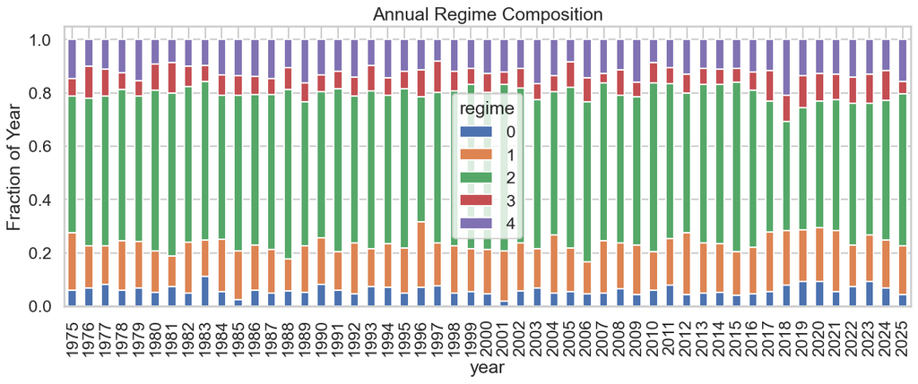

```python
annual = seasons_df.groupby(['year', 'regime']).size().unstack(fill_value=0)
annual_pct = annual.div(annual.sum(axis=1), axis=0)

annual_pct.plot(kind='bar', stacked=True, figsize=(15,5))
plt.title("Annual Regime Composition")
plt.ylabel("Fraction of Year")
plt.show()
```

To now calculate the Transition Probability Matrix ($P$) for the weather regimes. While the previous analysis looked at the total volume of each regime per year, to now reveal the Internal Dynamics—how the atmosphere actually moves from one state to another. Mathematically, this transforms the sequence of weather states into a First-Order Markov Chain.

**The Mathematical Mechanism:** $t-1 \to t$

There's need to create "Pairs" of consecutive days. For every point in time, to look at the "Past" and the "Present".

Row Index (regime.shift(1)): Represents the state at time $t-1$ (Yesterday).

Column Index (regime): Represents the state at time $t$ (Today).

The crosstab counts how many times the sequence $(0 \to 0)$, $(0 \to 1)$, $(1 \to 0)$, and $(1 \to 1)$ occurred in your 18,000+ days.

**The Normalisation: Conditional Probability**

The **normalize='index'** argument is the most crucial part of the logic. It ensures that each row sums exactly to $1.0$. This converts raw counts into Conditional Probabilities:

$$P(S_t = j \mid S_{t-1} = i)$$

This answers the question: "Given that we are in Regime $i$ today, what is the probability we will be in Regime $j$ tomorrow?"

**Interpreting the Matrix Structure**

The resulting matrix $P$ will look like the following:

**The "Diagonal" ($p_{00}$ and $p_{11}$): Persistence --**

These represent the probability of the weather staying put.

If $p_{11}$ is high (e.g., $0.85$), it means once an "Extreme" regime starts, it has an $85\%$ chance of continuing the next day. This measures Climatic Stagnation or the duration of heatwaves/storm cycles.

**The "Off-Diagonal" ($p_{01}$ and $p_{10}$): Volatility --**

These represent the probability of a Switch.

$p_{01}$ is the "Entry Rate" into the extreme state.

$p_{10}$ is the "Recovery Rate" back to the stable state.

**Climate Change Analytical Value**

By running the succeeeding code on different slices of the data (e.g., the 1990s vs. the 2020s), to detect Structural Decay in the climate:

1. Increased Persistence: If $p_{11}$ is higher in 2026 than in 1990, extreme events aren't just more frequent—they are getting "stuck" for longer periods (e.g., longer droughts or multi-day flood events).
2. Faster Triggering: If $p_{01}$ (Stable $\to$ Extreme) is increasing, the "buffer" of the atmosphere is weakening, and it takes less energy to flip the system into a hazardous state.

**Summary Table:**

| Matrix Component | Mathematical Term | Climate Meaning |
| --- | --- | --- |
| Rows | $S_{t-1}$ (Condition) | "Where we are starting from" |
| Columns | $S_{t}$ (Outcome) | "Where we are going" |
| Diagonal | Self-Transition | Stability/Duration: How long a regime lasts. Persistence |
| Off-Diagonal | State Switch | Sensitivity: How easily the weather flips. Switching probability |

While the previous "Stacked Bar" chart exhibited the composition of the year, this matrix shows the behaviour of the atmosphere. It proves whether the "Extreme" regime is becoming a more "sticky" or "absorptive" state in the 2026 environment.

```python
transitions = pd.crosstab(
    seasons_df['regime'].shift(1),
    seasons_df['regime'],
    normalize='index'
)

print(transitions)
```

```
regime         0         1         2         3         4
regime
0.0     0.147163  0.000887  0.465426  0.386525  0.000000
1.0     0.070362  0.291806  0.381663  0.037770  0.218398
2.0     0.047096  0.158196  0.665648  0.052254  0.076806
3.0     0.068729  0.021993  0.676976  0.227491  0.004811
4.0     0.060183  0.277366  0.321849  0.007414  0.333188
```

The above transition matrix represents the Transition Probability Matrix ($A$) of your Hidden Markov Model (HMM). Each cell $(i, j)$ represents the probability $P(S_t = j \mid S_{t-1} = i)$, or the likelihood of moving from one climate regime to another in the next time step.

**The Dominant "Gravitational" State: Regime 2**

Regime 2 acts as the absorptive center of this system.

**High-Volatility / Transient States: Regimes 0 and 3**

These regimes are the least stable.

1. Regime 0: Has a self-transition of only 14.7%. It almost immediately collapses into Regime 2 (46.5%) or Regime 3 (38.6%).
2. Regime 3: Similarly unstable, with a 22.7% persistence. It has a 67.6% chance of shifting directly into Regime 2.
3. Interpretation: These likely represent extreme, short-lived spikes or "inter-annual noise" (like a strong ENSO influence) that the model struggles to maintain over long periods.

**The "Closed Loop": Regimes 1 and 4**

There is a distinct mathematical relationship between Regimes 1 and 4.

1. Mutual Exchange: When the system leaves Regime 1, it has a high probability (21.8%) of going to 4. Conversely, when it leaves 4, it has a high probability (27.7%) of returning to 1.
2. Regime 3 Exclusion: Both Regimes 1 and 4 have nearly 0% probability of moving into Regime 3.
3. Interpretation: This suggests Regimes 1 and 4 might represent opposite phases of a specific oscillation (like a Warm vs. Cold AMO phase), whereas Regime 3 belongs to a completely different physical process.

**Summary Table**

| Regime | Persistence ($P_{i \to i}$) | Primary Exit Path | Classification |
| --- | --- | --- | --- |
| 0 | 0.14 (Low) | To 2 (46%) or 3 (38%) | Unstable / Transient |
| 1 | 0.29 (Moderate) | To 2 (38%) or 4 (21%) | Cyclical / Linked |
| 2 | 0.66 (High) | To 1 (15%) | Anchor / Steady State |
| 3 | 0.22 (Low) | To 2 (67%) | Short-lived Anomaly |
| 4 | 0.33 (Moderate) | To 2 (32%) or 1 (27%) | Cyclical / Linked |

### Appying Observed Regimes from Hidden Markov Models to Boolean Features

Earlier, boolean features for extreme flags and phenomena were created based on the use of the "&" operator, set conditions, quantiles and rolling smoothers/filters upon weather attributes for a respective month throughout each year, or by a specified duration. To now reacquaint with such features to apply to HMM.

The aim now is to map extremes and phenomena to regimes observed/acquired prior.

In Python / pandas:

True $\rightarrow$ 1

False $\rightarrow$ 0

Hence:

$$\text{mean} = \frac{\text{\# True}}{\text{total observations}}$$

In this **special case** use of the mean is the same as calculation of probability. The goal is to determine:

$$P(\text{weather flag type}\, |\, \text{regime}) = \frac{P(\text{weather flag type}\,\cap\,\text{regime})}{P(\text{regime})}$$

| Case | Meaning |
| --- | --- |

[output not shown]

So group mean gives, for example:

| Regime-conditioned Probabilities |
| --- |
| Heat extreme probability per regime |
| Rain extreme probability per regime |
| Wind extreme probability per regime |
| Flash Flood probability per regime |

```python
bool_df = seasons_df.select_dtypes(include='bool')

regime_probs = seasons_df.groupby('regime')[bool_df.columns].mean()

print(regime_probs)
```

```
        extreme_heat  extreme_cold  extreme_rain  extreme_wind  \
regime
0           0.074468      0.007979      0.483156      0.265957
1           0.063357      0.018276      0.000000      0.013402
2           0.045945      0.077658      0.000000      0.025981
3           0.074227      0.017182      0.001375      0.156701
4           0.029655      0.017008      0.174444      0.042739

        extreme_wind_direction  extreme_snow  extreme_high_humidity  \
regime
0                     0.046099      0.562057               0.203901
1                     0.038989      0.808407               0.058788
2                     0.057312      0.630528               0.015570
3                     0.039175      0.612371               0.063918
4                     0.045355      0.862625               0.116441

        extreme_low_humidity  extreme_high_press_msl  extreme_low_press_msl  \
regime
0                   0.000887                0.009752               0.348404
1                   0.013707                0.036247               0.010052
2                   0.080523                0.074315               0.016716
3                   0.032990                0.007560               0.205498
4                   0.001744                0.015700               0.024858

        extreme_cloud_cov  met_drought  flash_flood  blizzard  ice_storm
regime
0                0.999113     0.003546     0.207447  0.000000   0.075355
1                0.796528     0.021931     0.000000  0.000000   0.000914
2                0.507021     0.017385     0.000000  0.000096   0.001051
3                0.867354     0.006873     0.000000  0.000000   0.017182
4                0.956825     0.017444     0.059311  0.000000   0.004797
```

Before proceeding with MS-VECM, cointegration is required. Cointegration requires non-stationarit; VECM requires cointegration. If stationarity exists, then it's not possible to move forwards with MS-VECM.

```python
# Import the adfuller function
from statsmodels.tsa.stattools import adfuller

for col in X_scaled_df.columns:
    # Access the column data directly
    result = adfuller(X_scaled_df[col])
    p_value = result[1]
    is_stationary = "Stationary" if p_value < 0.05 else "Non-Stationary"
    print(f"Feature {col} | p-value: {p_value:.4f} | Result: {is_stationary}")
```

```
Feature temp_anom | p-value: 0.0000 | Result: Stationary
Feature rain_sum | p-value: 0.0000 | Result: Stationary
Feature wind_speed_10m_max | p-value: 0.0000 | Result: Stationary
Feature pressure_msl_min | p-value: 0.0000 | Result: Stationary
Feature pressure_tendency | p-value: 0.0000 | Result: Stationary
```

## Event Alignment + Validation Dataset

Now, to reacquaint with the developed extreme weather flags and phenomena indicators/variables. The current goal is to apply event alignment with validation statistics or metrics, to determine the robustness or credibility of the engineered extreme weather flag and phenomena.

Now, the fundamental question: **“Do weather-condition flags correctly predict or coincide with verified storm events?”** That is essentially a binary **event attribution + detection validation** problem.

To now commence the data assimilation and wrangling process.

Data assimilation:

```python
import pandas as pd
import requests
import re
import io
import gzip

def pull_storm_data(start_year, end_year, state='NEW YORK', event_types=None):
    base_url = "https://www.ncei.noaa.gov/pub/data/swdi/stormevents/csvfiles/"

    # Get the file list from the server
    r = requests.get(base_url)
    all_files = re.findall(r'href="(StormEvents_details-ftp_v1\.0_d\d{4}_c\d+\.csv\.gz)"', r.text)

    combined_data = []

    for year in range(start_year, end_year + 1):
        # Find the specific file for this year
        year_pattern = f"_d{year}_"
        target_file = next((f for f in all_files if year_pattern in f), None)

        if target_file:
            print(f"Downloading data for {year}...")
            file_url = base_url + target_file

            # Download and decompress in memory
            response = requests.get(file_url)
            with gzip.open(io.BytesIO(response.content), 'rb') as f:
                df = pd.read_csv(f, low_memory=False)

            # Filter for State and Event Types
            df_filtered = df[df['STATE'] == state.upper()]
            if event_types:
                df_filtered = df_filtered[df_filtered['EVENT_TYPE'].isin(event_types)]

            combined_data.append(df_filtered)

    return pd.concat(combined_data, ignore_index=True)

# Define your parameters
my_events = ['Blizzard', 'Flash Flood', 'Heat', 'Drought', 'Excessive Heat', 'Ice Storm']

# Execute the 'pull'
ny_storms_df = pull_storm_data(1990, 2025, event_types=my_events)

# Show result
print(ny_storms_df[['BEGIN_DATE_TIME', 'EVENT_TYPE', 'CZ_NAME', 'SOURCE']].head())
```

```
Downloading data for 1990...
Downloading data for 1991...
Downloading data for 1992...
Downloading data for 1993...
Downloading data for 1994...
Downloading data for 1995...
Downloading data for 1996...
Downloading data for 1997...
Downloading data for 1998...
Downloading data for 1999...
Downloading data for 2000...
Downloading data for 2001...
Downloading data for 2002...
Downloading data for 2003...
Downloading data for 2004...
Downloading data for 2005...
Downloading data for 2006...
Downloading data for 2007...
Downloading data for 2008...
Downloading data for 2009...
Downloading data for 2010...
Downloading data for 2011...
Downloading data for 2012...
Downloading data for 2013...
Downloading data for 2014...
Downloading data for 2015...
Downloading data for 2016...
Downloading data for 2017...
Downloading data for 2018...
Downloading data for 2019...
Downloading data for 2020...
Downloading data for 2021...
Downloading data for 2022...
Downloading data for 2023...
Downloading data for 2024...
Downloading data for 2025...
      BEGIN_DATE_TIME   EVENT_TYPE                CZ_NAME SOURCE
0  19-JAN-96 08:30:00  Flash Flood                 BROOME    NaN
1  19-JAN-96 08:30:00  Flash Flood                 ONEIDA    NaN
2  21-FEB-96 01:00:00  Flash Flood                   ERIE    NaN
3  20-FEB-96 23:30:00  Flash Flood                   ERIE    NaN
4  19-JAN-96 00:00:00         Heat  NORTHERN ST. LAWRENCE    NaN
```

Glimpse of the data:

```python
ny_storms_df.info()
```

```
<class 'pandas.core.frame.DataFrame'>
RangeIndex: 6431 entries, 0 to 6430
Data columns (total 51 columns):
 #   Column              Non-Null Count  Dtype
---  ------              --------------  -----
 0   BEGIN_YEARMONTH     6431 non-null   int64
 1   BEGIN_DAY           6431 non-null   int64
 2   BEGIN_TIME          6431 non-null   int64
 3   END_YEARMONTH       6431 non-null   int64
 4   END_DAY             6431 non-null   int64
 5   END_TIME            6431 non-null   int64
 6   EPISODE_ID          6431 non-null   float64
 7   EVENT_ID            6431 non-null   int64
 8   STATE               6431 non-null   object
 9   STATE_FIPS          6431 non-null   float64
```

[output cut: 43 more lines]

```python
ny_storms_df['CZ_NAME'].unique()
```

```
array(['BROOME', 'ONEIDA', 'ERIE', 'NORTHERN ST. LAWRENCE', 'ORANGE',
       'PUTNAM', 'OTSEGO', 'WESTERN ALBANY', 'EASTERN ALBANY', 'DELAWARE',
       'SULLIVAN', 'STEUBEN', 'CHEMUNG', 'SCHUYLER', 'YATES', 'SENECA',
       'CAYUGA', 'TOMPKINS', 'TIOGA', 'ONONDAGA', 'CORTLAND', 'HERKIMER',
       'MADISON', 'CHENANGO', 'WESTCHESTER', 'BRONX',
       'RICHMOND (STATEN IS.)', 'KINGS (BROOKLYN)', 'QUEENS', 'NASSAU',
       'NORTHWEST SUFFOLK', 'NORTHEAST SUFFOLK', 'SOUTHWEST SUFFOLK',
       'SOUTHEAST SUFFOLK', 'ROCKLAND', 'NORTHERN WESTCHESTER',
       'SOUTHERN WESTCHESTER', 'NEW YORK (MANHATTAN)', 'CHAUTAUQUA',
       'CATTARAUGUS', 'SCHOHARIE', 'ALBANY', 'DUTCHESS', 'COLUMBIA',
       'FRANKLIN', 'ESSEX', 'RENSSELAER', 'LIVINGSTON', 'CLINTON',
       'GENESEE', 'MONROE', 'WYOMING', 'ST. LAWRENCE', 'OSWEGO', 'WAYNE',
       'NEW YORK', 'FULTON', 'ULSTER', 'ORLEANS', 'MONTGOMERY',
       'RICHMOND', 'HAMILTON', 'ONTARIO', 'WASHINGTON', 'WARREN', 'KINGS',
       'GREENE', 'SUFFOLK', 'ALLEGANY', 'LEWIS', 'NIAGARA', 'SCHENECTADY',
       'NORTHERN ONEIDA', 'SOUTHERN ONEIDA', 'NORTHERN HERKIMER',
       'JEFFERSON', 'EASTERN DUTCHESS', 'WESTERN DUTCHESS',
       'WESTERN COLUMBIA', 'WESTERN SCHENECTADY', 'EASTERN SCHENECTADY',
       'SOUTHERN SARATOGA', 'EASTERN ESSEX', 'EASTERN COLUMBIA',
       'NORTHEAST CLINTON', 'SARATOGA', 'WESTERN RENSSELAER',
       'NORTHERN FRANKLIN', 'SOUTHWEST CLINTON', 'WESTERN ULSTER',
       'WESTERN GREENE', 'NORTHERN SARATOGA', 'EASTERN RENSSELAER',
       'EASTERN GREENE', 'EASTERN ULSTER', 'SOUTHERN HERKIMER',
       'SOUTHERN CAYUGA', 'NORTHERN CAYUGA', 'NORTHERN ERIE',
       'WESTERN ESSEX', 'EASTERN CLINTON', 'SOUTHERN FRANKLIN',
       'SOUTHEASTERN ST. LAWRENCE', 'WESTERN CLINTON',
       'SOUTHWESTERN ST. LAWRENCE', 'NORTHERN WASHINGTON',
       'NORTHERN FULTON', 'SOUTHERN FULTON', 'SOUTHEAST WARREN',
       'SOUTHERN WASHINGTON', 'NORTHERN WARREN', 'SOUTHERN QUEENS',
       'SOUTHERN NASSAU', 'NORTHERN QUEENS', 'NORTHERN NASSAU',
       'SOUTHERN ERIE'], dtype=object)
```

```python
selected_zones = [
    'BRONX',
    'RICHMOND (STATEN IS.)',
    'KINGS (BROOKLYN)',
    'QUEENS',
    'NEW YORK (MANHATTAN)',
    'WESTCHESTER',
    'NASSAU'
]

nyc_storms_df = ny_storms_df[ny_storms_df['CZ_NAME'].isin(selected_zones)].copy()
```

```python
print(nyc_storms_df.head(3)) # observation of three rows
```

```
    BEGIN_YEARMONTH  BEGIN_DAY  BEGIN_TIME  END_YEARMONTH  END_DAY  END_TIME  \
30           199605         11        1700         199605       11      1700
31           199601          7        1600         199601        8      1500
32           199601          7        1600         199601        8      1500

    EPISODE_ID  EVENT_ID     STATE  STATE_FIPS  ...  END_RANGE END_AZIMUTH  \
30   2053740.0   5580980  NEW YORK        36.0  ...        NaN         NaN
31   2040524.0   5561729  NEW YORK        36.0  ...        NaN         NaN
32   2040525.0   5561730  NEW YORK        36.0  ...        NaN         NaN

   END_LOCATION BEGIN_LAT  BEGIN_LON END_LAT END_LON  \
30    CHAPPAQUA       NaN        NaN     NaN     NaN
31          NaN       NaN        NaN     NaN     NaN
32          NaN       NaN        NaN     NaN     NaN

                                    EPISODE_NARRATIVE EVENT_NARRATIVE  \
30  As a cold front moved southeast toward the are...             NaN
31                                                NaN             NaN
32                                                NaN             NaN

   DATA_SOURCE
30         PDC
31         PDC
32         PDC

[3 rows x 51 columns]
```

Building proper datetime columns:

```python
def make_datetime(yearmonth, day, time):
    # convert HHMM → HH and MM
    hour = time // 100
    minute = time % 100

    return pd.to_datetime(
        yearmonth.astype(str) + day.astype(str).str.zfill(2),
        format="%Y%m%d"
    ) + pd.to_timedelta(hour, unit="h") + pd.to_timedelta(minute, unit="m")


nyc_storms_df["BEGIN_DATETIME"] = make_datetime(
    nyc_storms_df["BEGIN_YEARMONTH"],
    nyc_storms_df["BEGIN_DAY"],
    nyc_storms_df["BEGIN_TIME"]
)

nyc_storms_df["END_DATETIME"] = make_datetime(
    nyc_storms_df["END_YEARMONTH"],
    nyc_storms_df["END_DAY"],
    nyc_storms_df["END_TIME"]
)
```

```python
print(nyc_storms_df.head(2))
```

```
    BEGIN_YEARMONTH  BEGIN_DAY  BEGIN_TIME  END_YEARMONTH  END_DAY  END_TIME  \
30           199605         11        1700         199605       11      1700
31           199601          7        1600         199601        8      1500

    EPISODE_ID  EVENT_ID     STATE  STATE_FIPS  ...  END_LOCATION BEGIN_LAT  \
30   2053740.0   5580980  NEW YORK        36.0  ...     CHAPPAQUA       NaN
31   2040524.0   5561729  NEW YORK        36.0  ...           NaN       NaN

   BEGIN_LON END_LAT  END_LON  \
30       NaN     NaN      NaN
31       NaN     NaN      NaN

                                    EPISODE_NARRATIVE EVENT_NARRATIVE  \
30  As a cold front moved southeast toward the are...             NaN
31                                                NaN             NaN

   DATA_SOURCE      BEGIN_DATETIME        END_DATETIME
30         PDC 1996-05-11 17:00:00 1996-05-11 17:00:00
31         PDC 1996-01-07 16:00:00 1996-01-08 15:00:00

[2 rows x 53 columns]
```

Converting floats that are actually IDs:

```python
nyc_storms_df["EPISODE_ID"] = nyc_storms_df["EPISODE_ID"].astype("Int64")
nyc_storms_df["STATE_FIPS"] = nyc_storms_df["STATE_FIPS"].astype("Int64")

nyc_storms_df[["EPISODE_ID", "STATE_FIPS"]].info()
```

```
<class 'pandas.core.frame.DataFrame'>
Index: 723 entries, 30 to 6418
Data columns (total 2 columns):
 #   Column      Non-Null Count  Dtype
---  ------      --------------  -----
 0   EPISODE_ID  723 non-null    Int64
 1   STATE_FIPS  723 non-null    Int64
dtypes: Int64(2)
memory usage: 18.4 KB
```

Dropping tornado-only columns (they are empty here and overall useful for interest):

```python
drop_cols = [
    "MAGNITUDE_TYPE", "CATEGORY",
    "TOR_F_SCALE", "TOR_LENGTH", "TOR_WIDTH",
    "TOR_OTHER_WFO", "TOR_OTHER_CZ_STATE",
    "TOR_OTHER_CZ_FIPS", "TOR_OTHER_CZ_NAME"
]

nyc_storms_df = nyc_storms_df.drop(columns=drop_cols)
```

Standardizing EVENT_TYPE (crucial for matching logic):

```python
nyc_storms_df["EVENT_TYPE"] = nyc_storms_df["EVENT_TYPE"].str.upper().str.strip()
```

Filtering to New York CZ events (being the focus area):

```python
nyc_events = nyc_storms_df[
    (nyc_storms_df["STATE"] == "NEW YORK")
].copy()
```

Engineering useful derived features (VERY IMPORTANT for event matching):

```python
nyc_events["DURATION_HOURS"] = (
    (nyc_events["END_DATETIME"] - nyc_events["BEGIN_DATETIME"])
    .dt.total_seconds() / 3600
)
```

Binary severe event indicator (useful for validation):

```python
nyc_events["SEVERE_EVENT"] = (
    (nyc_events["INJURIES_DIRECT"] > 0) |
    (nyc_events["DEATHS_DIRECT"] > 0) |
    (nyc_events["DAMAGE_PROPERTY"].notna())
).astype(int)

nyc_events["SEVERE_EVENT"].dtype
```

```
dtype('int64')
```

Cleaning damage fields (very important). These are strings like "10K", "2.5M":

```python
def parse_damage(x):
    if pd.isna(x):
        return 0
    x = str(x).upper().replace("K", "e3").replace("M", "e6").replace("B", "e9")
    try:
        return float(eval(x))
    except:
        return 0

nyc_events["DAMAGE_PROPERTY_NUM"] = nyc_events["DAMAGE_PROPERTY"].apply(parse_damage)
nyc_events["DAMAGE_CROPS_NUM"] = nyc_events["DAMAGE_CROPS"].apply(parse_damage)
```

Spatial sanity check for location:

```python
nyc_events = nyc_events.dropna(subset=["BEGIN_LAT", "BEGIN_LON"])

print(nyc_events[["BEGIN_LAT", "BEGIN_LON"]].head(20))
```

```
      BEGIN_LAT  BEGIN_LON
1677   41.01667  -73.78333
1678   40.86667  -73.53333
1707   41.13333  -73.76667
1716   40.93333  -73.83333
1722   40.70000  -73.85000
1729   41.30000  -73.81667
1730   40.76667  -73.61667
1732   40.75000  -73.08333
1881   40.83000  -73.90000
1884   41.02000  -73.78000
1892   40.93000  -73.85000
1968   40.82000  -73.57000
1969   40.98000  -73.68000
1975   40.72890  -73.82000
1976   40.93000  -73.85000
1984   40.83000  -73.50000
1985   41.02000  -73.78000
1986   40.75000  -73.83000
1987   40.75000  -73.83000
1988   41.30000  -73.82000
```

```python
nyc_events['EVENT_TYPE'].unique()
```

```
array(['FLASH FLOOD'], dtype=object)
```

```python
nyc_events['EVENT_TYPE'].value_counts()
```

```
EVENT_TYPE
FLASH FLOOD    492
Name: count, dtype: int64
```

To now prepare the extreme weather flags and phenomena dataset:

```python
# Manually grab 'date' plus all boolean columns
cols = ['date'] + seasons_df.select_dtypes(include='bool').columns.tolist()
weather_flags_df = seasons_df[cols].copy()

weather_flags_df.info()
```

```
<class 'pandas.core.frame.DataFrame'>
RangeIndex: 18628 entries, 0 to 18627
Data columns (total 16 columns):
 #   Column                  Non-Null Count  Dtype
---  ------                  --------------  -----
 0   date                    18628 non-null  datetime64[ns, UTC]
 1   extreme_heat            18628 non-null  bool
 2   extreme_cold            18628 non-null  bool
 3   extreme_rain            18628 non-null  bool
 4   extreme_wind            18628 non-null  bool
 5   extreme_wind_direction  18628 non-null  bool
 6   extreme_snow            18628 non-null  bool
 7   extreme_high_humidity   18628 non-null  bool
 8   extreme_low_humidity    18628 non-null  bool
 9   extreme_high_press_msl  18628 non-null  bool
 10  extreme_low_press_msl   18628 non-null  bool
 11  extreme_cloud_cov       18628 non-null  bool
 12  met_drought             18628 non-null  bool
 13  flash_flood             18628 non-null  bool
 14  blizzard                18628 non-null  bool
 15  ice_storm               18628 non-null  bool
dtypes: bool(15), datetime64[ns, UTC](1)
memory usage: 418.5 KB
```

**TIME INCREMENT MATCHING DILEMMA**

Dataframe weather_flags_df (or the complete data set) is daily with time increments, so it's neccessary to align the storm events dataframe to daily resolution. “Event-window aggregation”, “Point-in-time matching”, and "Windowed classification" don't seem feasible with verified storm events data since the elapse times for storm events are often hourly in nature; **not even close to 24 hours**.

Cataching/extracting storm event days and defining a daily expansion:

```python
# 1. TRUNCATING TIMESTAMPS
# The original NOAA data includes hours/minutes (e.g., 2024-01-01 14:30:00).
# Since your daily weather data is a single row per day, to strip the time
# to get a clean calendar date (e.g., 2024-01-01).
nyc_events["EVENT_DATE_BEGIN"] = nyc_events["BEGIN_DATETIME"].dt.date
nyc_events["EVENT_DATE_END"] = nyc_events["END_DATETIME"].dt.date

# 2. DEFINING THE EXPANSION LOGIC
# This function calculates all the days falling between a start and end point.
# If an event starts on Monday and ends on Wednesday, it generates [Mon, Tue, Wed].
def expand_to_days(row):
    return pd.date_range(row["BEGIN_DATETIME"].date(), row["END_DATETIME"].date())

# 3. APPLYING THE EXPANSION
# Applying the function to every row in the NOAA dataset.
# At this stage, 'expanded' is a Series where each cell contains a LIST of dates.
expanded = nyc_events.apply(expand_to_days, axis=1)

# 4. EXPLODING THE LISTS
# .explode() takes those lists and creates a new row for every individual date.
# If one storm lasted 5 days, it now occupies 5 separate rows in 'storm_days'.
# .rename("date") names the new column for easy merging later.
# .to_frame() converts the Series back into a structured DataFrame.
storm_days = expanded.explode().rename("date").to_frame()

# 5. CREATING THE TARGET VARIABLE
# Assigning a value of 1 to every row created.
# This becomes the "Ground Truth" or "Input Feature" for the HMM,
# signaling that a recorded storm was active on this specific date.
storm_days["storm_flag"] = 1
```

Aligning storm events dataframe with the daily extreme weather flag dataframe:

```python
weather_flags_df["date"] = pd.to_datetime(weather_flags_df["date"]).dt.date
storm_days["date"] = pd.to_datetime(storm_days["date"]).dt.date
```

Merging both datasets:

```python
daily_flags_storm_event_df = weather_flags_df.merge(
    storm_days,
    on="date",
    how="left"
)

daily_flags_storm_event_df["storm_flag"] = daily_flags_storm_event_df["storm_flag"].fillna(0)
```

```python
daily_flags_storm_event_df.info()
```

```
<class 'pandas.core.frame.DataFrame'>
RangeIndex: 19000 entries, 0 to 18999
Data columns (total 17 columns):
 #   Column                  Non-Null Count  Dtype
---  ------                  --------------  -----
 0   date                    19000 non-null  object
 1   extreme_heat            19000 non-null  bool
 2   extreme_cold            19000 non-null  bool
 3   extreme_rain            19000 non-null  bool
 4   extreme_wind            19000 non-null  bool
 5   extreme_wind_direction  19000 non-null  bool
 6   extreme_snow            19000 non-null  bool
 7   extreme_high_humidity   19000 non-null  bool
 8   extreme_low_humidity    19000 non-null  bool
 9   extreme_high_press_msl  19000 non-null  bool
 10  extreme_low_press_msl   19000 non-null  bool
 11  extreme_cloud_cov       19000 non-null  bool
 12  met_drought             19000 non-null  bool
 13  flash_flood             19000 non-null  bool
 14  blizzard                19000 non-null  bool
 15  ice_storm               19000 non-null  bool
 16  storm_flag              19000 non-null  float64
dtypes: bool(15), float64(1), object(1)
memory usage: 575.3+ KB
```

```python
print(daily_flags_storm_event_df.head(5))
```

```
         date  extreme_heat  extreme_cold  extreme_rain  extreme_wind  \
0  1975-01-01         False         False         False         False
1  1975-01-02         False         False         False         False
2  1975-01-03         False         False         False         False
3  1975-01-04         False         False         False         False
4  1975-01-05         False         False         False         False

   extreme_wind_direction  extreme_snow  extreme_high_humidity  \
0                   False         False                  False
1                   False         False                  False
2                   False         False                  False
3                   False         False                  False
4                   False         False                  False

   extreme_low_humidity  extreme_high_press_msl  extreme_low_press_msl  \
```

[output cut: 19 more lines]

```python
daily_flags_storm_event_df['storm_flag'].unique()
```

```
array([0., 1.])
```

```python
daily_flags_storm_event_df['storm_flag'].value_counts()
```

```
storm_flag
0.0    18499
1.0      501
Name: count, dtype: int64
```

```python
daily_flags_storm_event_df['storm_flag'].dtype
```

```
dtype('float64')
```

### Classification Evaluation \ Validation

How well does the detector (the boolean flash_flood flag) identifies the ground truth (the integer storm_flag based on NOAA NCEI verified storm events)?

Observed:

y_true = daily_flags_storm_event_df['storm_flag'] (0/1, NOAA truth)

y_pred = daily_flags_storm_event_df['flash_flood'] (True/False detector)

Transform to same data type:

```python
# Converting to same type
CEV_data = daily_flags_storm_event_df.copy()

y_true = CEV_data['storm_flag'] # (0/1, NOAA truth)

y_pred = CEV_data['flash_flood'] # (True/False detector)

CEV_data['y_true'] = CEV_data['storm_flag'].astype(int)
CEV_data['y_pred'] = CEV_data['flash_flood'].astype(int)
```

A **confusion matrix** is a table used to describe the performance of a classification model. In this particular case, it compares the "detector" (the prediction) against the NOAA NCEI "storm_flag" (the actual ground truth).

The matrix compares the **Actual Class** (NOAA data) against the **Predicted Class** (Your detector).

| Actual Classes | Predicted: NO STORM | Predicted: STORM |
| --- | --- | --- |
| Actual: NO STORM | True Negative (TN) | False Positive (FP) |
| Actual: STORM | False Negative (FN) | True Positive (TP) |

1. True Positive (TP): You predicted a storm, and there was a storm. (Success)
2. True Negative (TN): You predicted no storm, and there was no storm. (Success)
3. False Positive (FP): You predicted a storm, but there was none. (Type I Error / False Alarm)
4. False Negative (FN): You predicted no storm, but there was one. (Type II Error / Missed Event)

**Accuracy**

The overall proportion of correct guesses.

**Note:** This can be misleading if storm days are very rare.

$$Accuracy = \frac{TP + TN}{TP + TN + FP + FN}$$

**Precision (Positive Predictive Value)**

When the detector says "Flash Flood," how often is it right?

$$Precision = \frac{TP}{TP + FP}$$

**Recall (Sensitivity / Probability of Detection)**

Out of all the real storms that happened, how many did the detector actually catch?

$$Recall = \frac{TP}{TP + FN}$$

**F1-Score**

The harmonic mean of Precision and Recall. It is the best "all-around" metric for imbalanced weather data.

$$F1 = 2 \cdot \frac{Precision \cdot Recall}{Precision + Recall}$$

**Critical Success Index (CSI / Threat Score)**

Standard in meteorology, this ignores True Negatives (the "easy" days with no rain) and focus only on how well the events were forecasted.

$$CSI = \frac{TP}{TP + FP + FN}$$

**False Alarm Ratio (FAR)**

The fraction of your "storm" predictions that were actually false alarms.

$$FAR = \frac{FP}{TP + FP}$$

```python
from sklearn.metrics import confusion_matrix

cm = confusion_matrix(CEV_data['y_true'], CEV_data['y_pred'])
print(cm)
```

```
[[18168   331]
 [  276   225]]
```

Interpretation:

|  | Predicted 0 | Predicted 1 |
| --- | --- | --- |
| Actual 0 | TN | FP |
| Actual 1 | FN | TP |

Adding labels:

```python
from sklearn.metrics import confusion_matrix

cm = confusion_matrix(y_true, y_pred, labels=[0, 1])
tn, fp, fn, tp = cm.ravel()

tn, fp, fn, tp
```

```
(np.int64(18168), np.int64(331), np.int64(276), np.int64(225))
```

**Key performance metrics --** the ones that actually matter for this use case:

```python
from sklearn.metrics import accuracy_score, precision_score, recall_score, f1_score

accuracy  = accuracy_score(CEV_data['y_true'], CEV_data['y_pred'])
precision = precision_score(CEV_data['y_true'], CEV_data['y_pred'])
recall    = recall_score(CEV_data['y_true'], CEV_data['y_pred'])
f1        = f1_score(CEV_data['y_true'], CEV_data['y_pred'])

print(f"Accuracy : {accuracy:.3f}")
print(f"Precision: {precision:.3f}")
print(f"Recall   : {recall:.3f}")
print(f"F1 Score : {f1:.3f}")
```

```
Accuracy : 0.968
Precision: 0.405
Recall   : 0.449
F1 Score : 0.426
```

**Adding event imbalance awareness**

Storm events are rare $\rightarrow$ accuracy can be misleading.

Check base rate:

```python
CEV_data['y_true'].mean()
```

```
np.float64(0.02636842105263158)
```

If the result is low (e.g., <5%), then:

1. High accuracy ≠ good model
2. Focus on recall + precision

**Skill vs random baseline**

To compare against a naive model:

```python
# Always predict "no storm"
baseline_accuracy = (CEV_data['y_true'] == 0).mean()
print("Baseline accuracy:", baseline_accuracy)
```

```
Baseline accuracy: 0.9736315789473684
```

If the model doesn’t beat this (above) meaningfully $\rightarrow$ it’s weak.

**More meteorology-style metrics**

These are commonly used in forecast verification:

```python
# Probability of Detection (same as recall)
POD = tp / (tp + fn)

# False Alarm Ratio
FAR = fp / (tp + fp)

# Critical Success Index (CSI / Threat Score)
CSI = tp / (tp + fn + fp)

print(f"POD (Recall): {POD:.3f}")
print(f"FAR        : {FAR:.3f}")
print(f"CSI        : {CSI:.3f}")
```

```
POD (Recall): 0.449
FAR        : 0.595
CSI        : 0.270
```

| Metric | Good sign |
| --- | --- |
| Recall (POD) | High → catching storms |
| FAR | Low → few false alarms |
| CSI | High → overall event detection quality |

**Matthews Correlation Coefficient (MCC)**

Unlike Accuracy or F1 Score, which can be misleading on imbalanced data, MCC provides a robust assessment by accounting for true/false positives and negatives.

$$\text{MCC} = \frac{\text{TP} \times \text{TN} - \text{FP} \times \text{FN}}{\sqrt{(\text{TP}+\text{FP})(\text{TP}+\text{FN})(\text{TN}+\text{FP})(\text{TN}+\text{FN})}}$$

Interpretation:

| MCC | Meaning |
| --- | --- |
| +1 | Perfect prediction |
| 0 | No skill (random) |
| -1 | Completely wrong (inverse prediction) |

How MCC compares to CSI:

| Metric | Uses TN? | Best for |
| --- | --- | --- |
| CSI | ❌ No | Event detection focus |
| MCC | ✅ Yes | Overall balanced skill |

```python
from sklearn.metrics import matthews_corrcoef

mcc = matthews_corrcoef(CEV_data['y_true'], CEV_data['y_pred'])
print(f"MCC: {mcc:.3f}")
```

```
MCC: 0.410
```

**Target performance (realistic) - For this kind of problem:**

| Metric | Good target |
| --- | --- |
| POD | 0.4 – 0.7 |
| FAR | 0.2 – 0.4 |
| CSI | 0.3 – 0.5 |
| MCC | 0.4 – 0.6 |

**The Model Performance**

POD (Recall): 0.449

```
Catching 44.9% of actual events

❗ This is moderate → a decent amount of true events are being missed (moderate false negatives)
```

FAR (False Alarm Ratio): 0.595

[output not shown]

CSI (Critical Success Index): 0.270

```
Accounts for hits, misses, and false alarms

❗ Low → overall event detection skill is limited
```

MCC (Matthews Correlation Coefficient): 0.410

```
Balanced metric (handles class imbalance well)

👍 Decent, suggests the model has good predictive signal
```

The model is:

1. Conservative

   MCC $\approx$ 0.410 means better than random

The detector appears to be legitimate and working, but:

### Direct Model of Storm Occurrence - Logit Regression Baseline

In a Logistic Regression model with boolean features, we are predicting the probability ($p$) that a specific day is a "Storm Event" ($y=1$) based on a set of True/False weather flags (e.g., extreme_heat, extreme_wind).

Unlike linear regression, which predicts a continuous number, Logit uses the Sigmoid function to squash the output between 0 and 1.

**The Linear Predictor ($z$)**

First, to calculate a weighted sum of the boolean features ($x_1, x_2, \dots, x_n$). Since the features are boolean, $x_i$ is either 1 or 0.

$$z = \beta_0 + \beta_1 x_1 + \beta_2 x_2 + \dots + \beta_n x_n$$

$\beta_0$ (Intercept): The "baseline" log-odds of a storm when no extreme flags are present.

$\beta_i$ (Coefficients): The weight of each specific flag. If extreme_wind has a high $\beta$, it strongly drives the prediction toward a storm.

**The Logistic (Sigmoid) Function**

To turn that linear value $z$ into a probability $p$, to pass it through the Logit Link Function:

$$p = \sigma(z) = \frac{1}{1 + e^{-z}}$$

**Interpreting the Boolean "Impact"**

In this structure, the impact of a boolean feature is best understood through Odds Ratios. If you "turn on" a flag (changing $x_i$ from 0 to 1), the odds of a storm occurring are multiplied by $e^{\beta_i}$.

1. If $\beta_i > 0$: The presence of that extreme flag increases the probability of a storm.
2. If $\beta_i < 0$: The presence of that flag actually decreases the probability (e.g., perhaps extreme_high_pressure correlates with clear skies).

**The Log-Likelihood (The "Fit")**

The model finds the best $\beta$ values by maximizing the Log-Likelihood function ($L$). For your 50 years of data ($N$ days), it tries to make the predicted probability $p$ as close as possible to the actual $y$ (0 or 1) for every single day:

$$\log L = \sum_{i=1}^{N} [y_i \log(p_i) + (1 - y_i) \log(1 - p_i)]$$

The model is essentially a "weighted vote." Every time a boolean flag like extreme_rain or flash_flood trips to True, it adds its specific "weight" to the total, and if the sum pushes the probability $p$ past a threshold (usually 0.5), the model classifies that day as a "Storm Event."

Will first apply the Statsmodels framework/environment to observe an explicit model fit.

```python
import statsmodels.api as sm

logit_data = daily_flags_storm_event_df.copy()

X = logit_data.drop(columns=["date", "storm_flag"])
y = logit_data["storm_flag"]

# Ensure target and features are binary
X = X.astype(int)
y = y.astype(int)

# IMPORTANT: Statsmodels requires adding a constant (the Intercept)
X = sm.add_constant(X)

# Initialize and fit the model
logit_model = sm.Logit(y, X)
result = logit_model.fit(method='bfgs', maxiter=200)

# Display the statistical summary
print(result.summary())
```

```
Optimization terminated successfully.
         Current function value: 0.081845
         Iterations: 160
         Function evaluations: 161
         Gradient evaluations: 161
                           Logit Regression Results
==============================================================================
Dep. Variable:             storm_flag   No. Observations:                19000
Model:                          Logit   Df Residuals:                    18984
Method:                           MLE   Df Model:                           15
Date:                Sat, 04 Apr 2026   Pseudo R-squ.:                  0.3285
Time:                        21:03:48   Log-Likelihood:                -1555.0
converged:                       True   LL-Null:                       -2315.8
Covariance Type:            nonrobust   LLR p-value:                     0.000
==========================================================================================
                             coef    std err          z      P>|z|      [0.025      0.975]
------------------------------------------------------------------------------------------
const                     -8.5734      0.398    -21.562      0.000      -9.353      -7.794
extreme_heat               0.8255      0.219      3.772      0.000       0.397       1.254
extreme_cold             -12.9316    192.009     -0.067      0.946    -389.262     363.399
extreme_rain               1.4833      0.170      8.705      0.000       1.149       1.817
extreme_wind               0.3713      0.158      2.348      0.019       0.061       0.681
extreme_wind_direction     0.1745      0.240      0.727      0.467      -0.296       0.645
extreme_snow               2.7085      0.269     10.065      0.000       2.181       3.236
extreme_high_humidity     -0.3633      0.188     -1.937      0.053      -0.731       0.004
extreme_low_humidity     -10.9626     87.026     -0.126      0.900    -181.530     159.605
extreme_high_press_msl    -0.8996      0.475     -1.892      0.058      -1.831       0.032
extreme_low_press_msl      0.3091      0.160      1.938      0.053      -0.003       0.622
extreme_cloud_cov          2.2786      0.299      7.630      0.000       1.693       2.864
met_drought               -0.1258      0.465     -0.270      0.787      -1.038       0.786
flash_flood                1.8412      0.180     10.227      0.000       1.488       2.194
blizzard                  -0.4028      5.423     -0.074      0.941     -11.033      10.227
ice_storm                  0.0303      0.429      0.071      0.944      -0.811       0.871
==========================================================================================
```

**Interpreting the Summary Table**

1. The P-Values ($P > |z|$)

   If a p-value is < 0.05, that weather variable is a statistically significant predictor of a storm. If it's higher, that variable might just be "noise" for the specific events you're tracking (e.g., Humidity might not predict a Blizzard well).
2. The Coefficients ($coef$)

   In Logistic Regression, these are in Log-Odds.Positive coef: As this variable increases, the probability of a storm increases (e.g., Rain).Negative coef: As this variable increases, the probability of a storm decreases (e.g., Pressure).
3. Pseudo R-squared

   Unlike linear regression, Logistic uses "Pseudo R-squared" (like McFadden's). A value between 0.2 and 0.4 is considered an excellent fit for weather data.

**Note:** the primary goal of the Statsmodel based model in this case isn't towards classification predicting, rather, observing whether the flag features are statistically meaningful.

Now, onwards to the Sklearn framework/environment to apply strong validation:

```
--- Classification Report ---
              precision    recall  f1-score   support

           0       0.99      0.88      0.93      3700
           1       0.13      0.66      0.22       100

    accuracy                           0.88      3800
   macro avg       0.56      0.77      0.58      3800
weighted avg       0.97      0.88      0.91      3800

ROC-AUC Score: 0.8849
Brier Score Loss: 0.1317
```

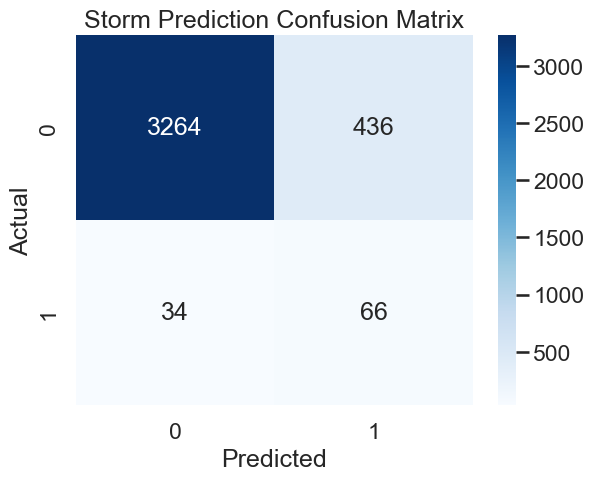

```python
from sklearn.model_selection import train_test_split
from sklearn.linear_model import LogisticRegression
from sklearn.metrics import classification_report, confusion_matrix, roc_auc_score, brier_score_loss

X = logit_data.drop(columns=["date", "storm_flag"])
y = logit_data["storm_flag"]

# Ensure target is binary
X = X
y = y.astype(int)

# Splitting the data (80% Train, 20% Test)
# We use 'stratify=y' to ensure both sets have the same percentage of storms
X_train, X_test, y_train, y_test = train_test_split(
    X, y, test_size=0.2, random_state=42, stratify=y
)

# Fitting the logistic model to the features' data
# 'liblinear' is great for smaller/binary datasets
log_reg = LogisticRegression(solver='liblinear', max_iter=1000, class_weight='balanced')
log_reg.fit(X_train, y_train)

# Generating Predictions
y_pred = log_reg.predict(X_test)
y_prob = log_reg.predict_proba(X_test)[:, 1] # Probability of "1"

# Printing Metrics
print("--- Classification Report ---")
print(classification_report(y_test, y_pred))

print(f"ROC-AUC Score: {roc_auc_score(y_test, y_prob):.4f}")
print(f"Brier Score Loss: {brier_score_loss(y_test, y_prob):.4f}")

# Confusion Matrix Visualization
sns.heatmap(confusion_matrix(y_test, y_pred), annot=True, fmt='d', cmap='Blues')
plt.xlabel('Predicted')
plt.ylabel('Actual')
plt.title('Storm Prediction Confusion Matrix')
plt.show()
```

**The Raw Numbers**

1. True Negatives (TN): 3264 (Correctly predicted "No Storm")
2. True Positives (TP): 66 (Correctly predicted "Storm")
3. False Negatives (FN): 34 (Missed storms; predicted "No Storm" when one occurred)
4. False Positives (FP): 436 (False alarms; predicted "Storm" when none occurred)

**Key Metrics**

| Metric | Formula | Result |
| --- | --- | --- |
| Accuracy | $\frac{TP + TN}{TP + TN + FP + FN}$ | 87.6% |
| Precision | $\frac{TP}{TP + FP}$ | 13.1% |
| Recall (Sensitivity) | $\frac{TP}{TP + FN}$ | 66.0% |
| F1-Score | $2 \cdot \frac{Precision \cdot Recall}{Precision + Recall}$ | 21.9% |

**Analysis & Insights**

High Accuracy (87.6%)

```
⚠️ Misleading due to class imbalance (many non-events)
```

Low Precision (13%)

```
❗ Too many false alarms
```

Good Recall (66%)

```
✅ Strong event detection
```

Low F1 (0.22)

```
❗ Imbalance between precision and recall
```

A model that:

```
✅ Detects events well (high recall)

❗ But over-predicts heavily (low precision)
```

```python
# 1. Initialize with 'balanced' weights
# This automatically adjusts weights inversely proportional to class frequencies
log_reg_balanced = LogisticRegression(
    class_weight='balanced',
    solver='liblinear',
    max_iter=1000
)

# 2. Re-fit on the same training data
log_reg_balanced.fit(X_train, y_train)

# 3. Predict
y_pred_bal = log_reg_balanced.predict(X_test)

# 4. Compare the new metrics
print("--- Balanced Classification Report ---")
print(classification_report(y_test, y_pred_bal))
```

```
--- Balanced Classification Report ---
              precision    recall  f1-score   support

           0       0.99      0.88      0.93      3700
           1       0.13      0.66      0.22       100

    accuracy                           0.88      3800
   macro avg       0.56      0.77      0.58      3800
weighted avg       0.97      0.88      0.91      3800
```

After running the balanced model, to plot the Probability Distribution to see how the model's "confidence" has changed.

This plot will show if the "Red" (Storms) and "Blue" (No Storms) curves are separating. The less they overlap, the more "discriminatory power" the weather variables have:

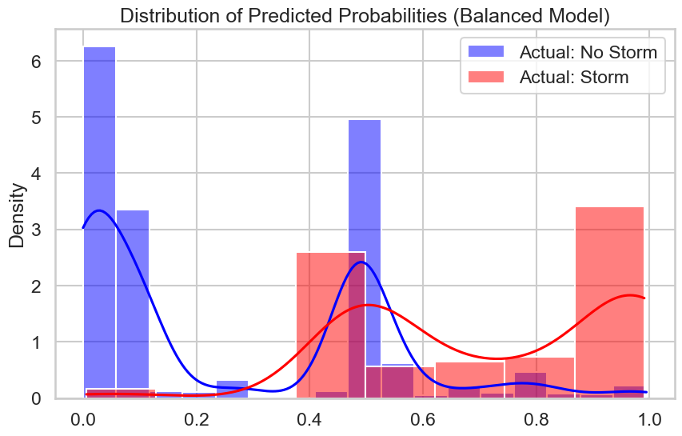

```python
y_prob_bal = log_reg_balanced.predict_proba(X_test)[:, 1]

plt.figure(figsize=(10, 6))
sns.histplot(y_prob_bal[y_test==0], color='blue', label='Actual: No Storm', kde=True, stat="density", alpha=0.5)
sns.histplot(y_prob_bal[y_test==1], color='red', label='Actual: Storm', kde=True, stat="density", alpha=0.5)
plt.title("Distribution of Predicted Probabilities (Balanced Model)")
plt.legend()
plt.show()
```

### Conditional Probability (most interpretable metric)

**Interpretation:**

“Probability of a storm event given weather phenomena or extreme event condition”.

$$P(\text{Storm Event} \mid \text{flash\_flood\_flag})$$

The code looks specifically at the storm_flag column for the flash flood attribute. This is checking if a storm occurred with the specific phenomena.

An example, for the case of flash flood flag in code:

```python
daily_flags_storm_event_df.groupby("flash_flood")["storm_flag"].mean()
```

```
flash_flood
False    0.014964
True     0.404676
Name: storm_flag, dtype: float64
```

The above code partitions the dataset into two subsets based on the value of flash_flood (True and False), and then computes the average of storm_flag within each subset. Because both variables are boolean, pandas implicitly treats True as 1 and False as 0. As a result, taking the mean of storm_flag within each group is equivalent to computing the proportion of observations where storm_flag = True in that group.

$$P(\text{storm\_flag} = 1 \mid \text{flash\_flood\_flag})$$

In other words, it tells you how frequently storm events occur given the presence or absence of a flash flood. This makes the operation a simple but powerful way to quantify the association between the two binary variables and serves as an empirical estimate of their relationship prior to more formal modelling.

**Question to independently ponder on: why not sum to 1?**

To now view probabilities for all extreme cases and weather phenomena where outcome is true:

```python
# 1. Identify all boolean columns (your predictors)
# We exclude 'storm_flag' itself because we are using it as the target
flag_cols = daily_flags_storm_event_df.select_dtypes(include='bool').columns
results = {}

print(f"{'Weather Flag':<25} | {'Storm Probability (%)':<20}")
print("-" * 50)

for col in flag_cols:
    if col != 'storm_flag':
        # Calculate the mean of storm_flag when the flag is TRUE
        # This tells us: "When this flag is active, what is the chance it's a storm?"
        prob = daily_flags_storm_event_df.groupby(col)["storm_flag"].mean().get(True, 0)
        results[col] = prob
        print(f"{col:<25} | {prob*100:>18.2f}%")
```

```
Weather Flag              | Storm Probability (%)
--------------------------------------------------
extreme_heat              |               2.69%
extreme_cold              |               0.00%
extreme_rain              |              23.56%
extreme_wind              |              12.44%
extreme_wind_direction    |               2.61%
extreme_snow              |               3.68%
extreme_high_humidity     |               4.52%
extreme_low_humidity      |               0.00%
extreme_high_press_msl    |               0.52%
extreme_low_press_msl     |              11.33%
extreme_cloud_cov         |               3.80%
met_drought               |               1.62%
flash_flood               |              40.47%
blizzard                  |               0.00%
ice_storm                 |               6.43%
```

**So, what if only concerned with true cases for flash flood?**

If only concerned with the flash_flood = True cases, then there's restricting attention to a single conditional subset of the data. In that case, the computation simplifies conceptually to:

$$P(\text{storm\_flag} = 1 \mid \text{flash\_flood\_flag} = 1)$$

This represents the probability (or frequency) of a storm event occurring specifically on days when a flash flood is present. Instead of comparing across both groups (True vs False), you are focusing entirely on the conditional behavior within the flash flood regime. Practically, this is equivalent to filtering the dataset to flash_flood == True and then taking the mean of storm_flag, which yields the proportion of those flash flood days that also experienced a storm.

Analytically, this isolates the **co-occurrence** rate of storms given flash floods and can be interpreted as a measure of how strongly storm events are associated with flash flood conditions. However, note that by ignoring the flash_flood = False group, you lose the comparative baseline needed to assess whether storms are more likely during flash floods versus normal conditions—so this becomes a descriptive conditional frequency rather than a full measure of association.

The code for such:

```python
df_ff = daily_flags_storm_event_df[daily_flags_storm_event_df["flash_flood"] == True]
df_ff["storm_flag"].mean()
```

```
np.float64(0.40467625899280574)
```

### Combining Multiple Conditions

It is possible to stipulate particular multiple conditions with the raw meteorological measures possessed from the beginning. However, to do such, there's need to merge the full daily weather data set (such seasons_df) with the cleaned and time synchronised NOAA/NCEI storm events data. Similar to prior, however, focusing on the multiple raw/natural meterological attributes rather than the engineered features for observation of extremes or phenomena. An example:

```python
# Acquiring a copy of the full data set
bulk_data = seasons_df.copy()

# Synchronising time standard
bulk_data["date"] = pd.to_datetime(weather_flags_df["date"]).dt.date
storm_days["date"] = pd.to_datetime(storm_days["date"]).dt.date

# Merging process
bulk_data_storm_event_df = bulk_data.merge(
    storm_days,
    on="date",
    how="left"
)
bulk_data_storm_event_df["storm_flag"] = bulk_data_storm_event_df["storm_flag"].fillna(0)
```

```python
bulk_data_storm_event_df.info()
```

```
<class 'pandas.core.frame.DataFrame'>
RangeIndex: 19000 entries, 0 to 18999
Data columns (total 32 columns):
 #   Column                       Non-Null Count  Dtype
---  ------                       --------------  -----
 0   date                         19000 non-null  object
 1   temperature_2m_max           19000 non-null  float32
 2   temperature_2m_min           19000 non-null  float32
 3   rain_sum                     19000 non-null  float32
 4   snowfall_sum                 19000 non-null  float32
 5   wind_speed_10m_max           19000 non-null  float32
 6   wind_direction_10m_dominant  19000 non-null  float32
 7   relative_humidity_2m_max     19000 non-null  float32
 8   relative_humidity_2m_min     19000 non-null  float32
 9   pressure_msl_max             19000 non-null  float32
```

[output cut: 24 more lines]

#### The case of:

$$P(\text{Storm Event} =1 \mid \text{Total Rain} \mid \text{Maximum Relative Humidity} \mid \text{Maximum Temperature})$$

Here, there's grouping the data by unique combinations of three continuous variables (rain_sum, relative_humidity_2m_max, temperature_2m_max). For each unique combination, the computing of the mean of storm_flag. Since storm_flag is boolean, its mean still represents the proportion of times a storm occurred within each group.

However, because the grouping variables are continuous, most combinations will either:

1. occur only once, or
2. occur very few times

This means the “mean” will often just be 0 or 1, making the result noisy and not very informative. In practice, this behaves less like a smooth conditional probability and more like a lookup of individual observations.

**Crucial idea:**

1. With categorical grouping → meaningful conditional probabilities
2. With continuous grouping (no binning) → sparse groups, unstable estimates

#### Analytical Practicality with Discretization

For analytical usefulNESS, THERE should BE binning (discretization) of the continuous variables towards the following computation:

$$P(\text{Storm Event} \mid \text{Rain Range} \mid \text{Humidity Range} \mid \text{Temperature Range})$$

being far more stable and interpretable.

Divides the data into quartiles (or other equal partitions). Namely, splitting the data by population, ensuring that an equal number of weather cases fall into each bin.

**The Quartile Exaplanation**

When setting q=4, Pandas calculates the 25th, 50th, and 75th percentiles of the data to create four distinct buckets:

Bin 1 (0-25%): The "Lowest" values.

Bin 2 (25-50%): The "Below Average" values.

Bin 3 (50-75%): The "Above Average" values.

Bin 4 (75-100%): The "Highest" values.

By using q=4,there's transformation of continuous numbers into categories.

So, the .groupby().mean() operation is calculating the storm probability for **combinations of intensity** rather than specific numbers. For example, one group might represent:

*"Trips that occurred during the highest 25% of rainfall AND the lowest 25% of temperature."*

To now:

1. Select all float columns except storm_flag
2. Create bins for each using a loop
3. Grouping on all those bins

```python
import pandas as pd

# Step 1: select float columns (excluding storm_flag if needed)
float_cols = bulk_data_storm_event_df.select_dtypes(include="float").columns.tolist()

# If storm_flag somehow got included, remove it
float_cols = [col for col in float_cols if col != "storm_flag"]

# Step 2: create bins dynamically
bin_cols = []
for col in float_cols:
    bin_col = f"{col}_bin"
    bulk_data_storm_event_df[bin_col] = pd.qcut(bulk_data_storm_event_df[col], q=4, duplicates="drop")
    bin_cols.append(bin_col)
```

#### Weather Profiles

The "Weather Profile" concept is basically a way of turning messy, chaotic natural data into a structured library or archive of scenarios. Since weather variables like temperature and humidity are continuous (meaning they have infinite decimal points), no two cases can ever have the exact same weather w.r.t. to precision.

By binning the continuuous variables, there's creation of "Profiles" that allow finding of patterns across thousands of independent cases or values.

To now observe the count of existing weather profiles (**with calculation of probabilities included**):

```python
# Grouping by all bins and computing probability
weather_profiles = bulk_data_storm_event_df.groupby(bin_cols, observed=True)["storm_flag"].mean().dropna()

len(weather_profiles)
```

```
9774
```

```python
print(weather_profiles.head(10))
```

```
temperature_2m_max_bin        temperature_2m_min_bin  rain_sum_bin   snowfall_sum_bin  wind_speed_10m_max_bin  wind_direction_10m_dominant_bin  relative_humidity_2m_max_bin  relative_humidity_2m_min_bin  pressure_msl_max_bin  cloud_cover_max_bin  pressure_msl_min_bin
(-15.043999999999999, 8.257]  (-25.544, 0.157]        (-0.001, 2.3]  (-0.001, 30.8]    (5.717, 13.48]          (-0.0009815, 135.665]            (35.488, 82.236]              (13.616000000000001, 40.309]  (1015.3, 1019.7]      (97.0, 100.0]        (1008.2, 1013.2]        0.0
                                                                                                                                                                                                            (1019.7, 1024.6]      (97.0, 100.0]        (1013.2, 1018.2]        0.0
                                                                                                                                                                                                            (1024.6, 1051.7]      (-0.001, 97.0]       (1018.2, 1047.9]        0.0
                                                                                                                                                                                                                                  (97.0, 100.0]        (1018.2, 1047.9]        0.0
                                                                                                                                                                              (40.309, 49.978]              (1015.3, 1019.7]      (-0.001, 97.0]       (1008.2, 1013.2]        0.0
                                                                                                                                                                                                            (1019.7, 1024.6]      (97.0, 100.0]        (1013.2, 1018.2]        0.0
                                                                                                                                                                                                                                                       (1018.2, 1047.9]        0.0
                                                                                                                                                                                                            (1024.6, 1051.7]      (-0.001, 97.0]       (1018.2, 1047.9]        0.0
                                                                                                                                                                                                                                  (97.0, 100.0]        (1018.2, 1047.9]        0.0
                                                                                                                                                                              (49.978, 63.075]              (1015.3, 1019.7]      (97.0, 100.0]        (1013.2, 1018.2]        0.0
Name: storm_flag, dtype: float64
```

```python
# Convert the Series to a DataFrame and sort by the highest storm probability
weather_profiles_sample = weather_profiles.reset_index()
weather_profiles_sample = weather_profiles_sample[weather_profiles_sample['storm_flag'] > 0].sort_values(by='storm_flag', ascending=False)

print(weather_profiles_sample.head(10))
```

```
     temperature_2m_max_bin temperature_2m_min_bin   rain_sum_bin  \
9772         (24.957, 40.4]         (16.407, 29.0]   (2.3, 187.2]
9599         (24.957, 40.4]         (16.407, 29.0]   (2.3, 187.2]
9351         (24.957, 40.4]         (16.407, 29.0]   (2.3, 187.2]
9371         (24.957, 40.4]         (16.407, 29.0]   (2.3, 187.2]
9430         (24.957, 40.4]         (16.407, 29.0]   (2.3, 187.2]
8265         (24.957, 40.4]         (16.407, 29.0]  (-0.001, 2.3]
8164         (24.957, 40.4]         (16.407, 29.0]  (-0.001, 2.3]
8015         (24.957, 40.4]        (8.128, 16.407]   (2.3, 187.2]
7893         (24.957, 40.4]        (8.128, 16.407]  (-0.001, 2.3]
9478         (24.957, 40.4]         (16.407, 29.0]   (2.3, 187.2]

     snowfall_sum_bin wind_speed_10m_max_bin wind_direction_10m_dominant_bin  \
9772   (-0.001, 30.8]       (21.413, 60.587]                (291.135, 360.0]
9599   (-0.001, 30.8]        (13.48, 16.874]                (291.135, 360.0]
```

[output cut: 44 more lines]

**NOTICE:** Observe for some cases the mathematical impossibility of negative vaules for certain features, such as rain fall and cloud cover.

This is actually a common "trick" performed by the Pandas qcut and cut functions to handle the way intervals are calculated. It doesn't mean the data actually contains negative rain (or cloud cover or for other features); it’s about interval boundary logic.

The example case of (-0.001, 0.1]:

1. In math, intervals are usually written as (min, max].

   ```
   The parenthesis ( means "exclusive" (greater than).

   The bracket ] means "inclusive" (less than or equal to).
   ```

2. If the lowest rainfall value is exactly 0.0, and Pandas set the bin starting point at 0.0, an "exclusive" start would look like (0.0, 0.1]. This would actually exclude all the rows where rain is exactly 0.0!
3. To make sure those 0.0 values are actually included in the first bin, pd.qcut automatically nudges the lower boundary slightly below the actual minimum value in your data.

   ```
   Actual Data Min: 0.0

   Pandas Adjustment: -0.001

   Resulting Bin: (-0.001, 0.1]

   This ensures that a value of exactly 0.0 is mathematically "greater than -0.001" and therefore falls safely into that first category.
   ```

4. It’s purely a labeling convention.

   ```
   It does not change the underlying data in merged_df.

   It does not mean the model thinks it rained negative amounts.

   It simply ensures that the "Dry Day" (0.0 rain) cases aren't dropped from the analysis.
   ```

5. If the negative signs are repulsive or confusing for direct interpretation for a report, such be resolved by manually overriding the labels when the bins are created. Instead of letting Pandas name them, provide meteorologically interpretal designations. For example:

bulk_data_storm_event_df["rain_bin"] = pd.qcut( bulk_data_storm_event_df["rain_sum"], q=4, labels=["No/Trace Rain", "Light Rain", "Moderate Rain", "Heavy Rain"] )

**Thermal Profile: High Heat & Warm Floors**

Every single top profile falls into the highest bin for Maximum Temperature $(24.96°C \text{ to } 40.4°C)$.

1. Insight: Heat is the engine for these storms.
2. Sustainability: Most profiles also show Minimum Temperatures staying above $16.4°C$. This indicates "warm nights," where the atmosphere doesn't cool down enough to stabilize, maintaining the convective energy needed for storm activity.

**Moisture & Clouds: Near Saturation**

1. Relative Humidity (Max): Almost all profiles show max humidity in the 91% to 100% range.
2. Cloud Cover: There is a heavy concentration in the 97% to 100% bin.
3. Interpretation: The model is identifying a "saturated" column of air. When you have maximum heat combined with maximum moisture and total cloud cover, the statistical probability of a storm event in your dataset reaches certainty.

**Pressure Dynamics: The "Low Pressure" Trigger**

Most of the $1.0$ flags are associated with:

**Wind & Directional Variability**

Interestingly, the model is triggering a $1.0$ flag across all dominant wind directions (indicated by the various bins like $291°-360°$ and $135°-232°$).

1. Insight: This suggests that once the thermal and moisture conditions (Heat + Humidity + Low Pressure) are met, the specific direction the wind is blowing from becomes less important—the storm is happening regardless of the fetch.

**Summary of the "Certain Storm" Profile**

If to describe the "Perfect Storm" according to the data, it looks like this:

1. Very Hot: Day temps above $25°C$.
2. Very Humid: Max humidity near $100\%$.
3. Very Cloudy: Complete or near-complete overcast.
4. Low Pressure: A distinct dip in barometric pressure.

**Caveat on "1.0:"**

To observe whether such profiles are actually "reliable" or just "lucky," to check the count of cases in these groups:

```python
# This will show you how many trips actually fell into these '1.0' profiles
count_check = bulk_data_storm_event_df.groupby(bin_cols, observed=True)["storm_flag"].count()
print(count_check.loc[weather_profiles[weather_profiles == 1.0].index])
len(count_check)
```

```
temperature_2m_max_bin  temperature_2m_min_bin  rain_sum_bin   snowfall_sum_bin  wind_speed_10m_max_bin  wind_direction_10m_dominant_bin  relative_humidity_2m_max_bin  relative_humidity_2m_min_bin  pressure_msl_max_bin  cloud_cover_max_bin  pressure_msl_min_bin
(16.857, 24.957]        (8.128, 16.407]         (2.3, 187.2]   (-0.001, 30.8]    (5.717, 13.48]          (291.135, 360.0]                 (96.265, 100.0]               (49.978, 63.075]              (1015.3, 1019.7]      (97.0, 100.0]        (1008.2, 1013.2]                1
                                                                                 (21.413, 60.587]        (291.135, 360.0]                 (91.056, 96.265]              (13.616000000000001, 40.309]  (1015.3, 1019.7]      (97.0, 100.0]        (961.6990000000001, 1008.2]     3
                        (16.407, 29.0]          (2.3, 187.2]   (-0.001, 30.8]    (21.413, 60.587]        (135.665, 232.367]               (91.056, 96.265]              (63.075, 98.665]              (1015.3, 1019.7]      (97.0, 100.0]        (961.6990000000001, 1008.2]     1
(24.957, 40.4]          (8.128, 16.407]         (-0.001, 2.3]  (-0.001, 30.8]    (16.874, 21.413]        (135.665, 232.367]               (96.265, 100.0]               (49.978, 63.075]              (1015.3, 1019.7]      (97.0, 100.0]        (1008.2, 1013.2]                1
                                                (2.3, 187.2]   (-0.001, 30.8]    (13.48, 16.874]         (135.665, 232.367]               (91.056, 96.265]              (49.978, 63.075]              (989.799, 1015.3]     (97.0, 100.0]        (961.6990000000001, 1008.2]     5
                        (16.407, 29.0]          (-0.001, 2.3]  (-0.001, 30.8]    (5.717, 13.48]          (135.665, 232.367]               (82.236, 91.056]              (40.309, 49.978]              (989.799, 1015.3]     (-0.001, 97.0]       (1008.2, 1013.2]                1
                                                                                                         (232.367, 291.135]               (82.236, 91.056]              (13.616000000000001, 40.309]  (989.799, 1015.3]     (-0.001, 97.0]       (961.6990000000001, 1008.2]     4
                                                (2.3, 187.2]   (-0.001, 30.8]    (5.717, 13.48]          (-0.0009815, 135.665]            (91.056, 96.265]              (63.075, 98.665]              (1015.3, 1019.7]      (97.0, 100.0]        (1013.2, 1018.2]                3
                                                                                                         (135.665, 232.367]               (82.236, 91.056]              (40.309, 49.978]              (989.799, 1015.3]     (97.0, 100.0]        (961.6990000000001, 1008.2]     1
                                                                                                                                                                                                      (1015.3, 1019.7]      (97.0, 100.0]        (1008.2, 1013.2]               24
                                                                                                                                          (91.056, 96.265]              (40.309, 49.978]              (989.799, 1015.3]     (97.0, 100.0]        (1008.2, 1013.2]                1
                                                                                                         (232.367, 291.135]               (96.265, 100.0]               (40.309, 49.978]              (989.799, 1015.3]     (97.0, 100.0]        (961.6990000000001, 1008.2]     4
                                                                                 (13.48, 16.874]         (-0.0009815, 135.665]            (91.056, 96.265]              (49.978, 63.075]              (1015.3, 1019.7]      (97.0, 100.0]        (1013.2, 1018.2]                8
                                                                                                         (135.665, 232.367]               (91.056, 96.265]              (40.309, 49.978]              (1019.7, 1024.6]      (97.0, 100.0]        (1013.2, 1018.2]                2
```

[output cut: 8 more lines]

```
9774
```

**How to see the "Middle" Probabilities**

To observe profiles where storms are possible but not guaranteed (e.g., a 0.3 or 0.5 probability), to look at the rows likely skipped over or filtered out. To see a broader range of probabilities, reduce the number of variables in the groupby. When applying fewer variables, more casess fall into each "bucket," giving a more realistic average.

```python
# Grouping by only the top 3 most likely drivers
simplified_probes = bulk_data_storm_event_df.groupby(
    ["temperature_2m_max_bin", "relative_humidity_2m_max_bin", "pressure_msl_min_bin"],
    observed=True
)["storm_flag"].mean()

# Show me profiles that aren't just 0 or 1
print(simplified_probes[(simplified_probes > 0) & (simplified_probes < 1)])

len(simplified_probes)
```

```
temperature_2m_max_bin  relative_humidity_2m_max_bin  pressure_msl_min_bin
(8.257, 16.857]         (91.056, 96.265]              (961.6990000000001, 1008.2]    0.013699
                        (96.265, 100.0]               (961.6990000000001, 1008.2]    0.042408
                                                      (1008.2, 1013.2]               0.011583
(16.857, 24.957]        (91.056, 96.265]              (961.6990000000001, 1008.2]    0.032491
                                                      (1008.2, 1013.2]               0.020408
                                                      (1013.2, 1018.2]               0.002899
                        (96.265, 100.0]               (961.6990000000001, 1008.2]    0.174812
                                                      (1008.2, 1013.2]               0.051282
                                                      (1013.2, 1018.2]               0.008929
                                                      (1018.2, 1047.9]               0.203252
(24.957, 40.4]          (35.488, 82.236]              (961.6990000000001, 1008.2]    0.024590
                        (82.236, 91.056]              (961.6990000000001, 1008.2]    0.037838
                                                      (1008.2, 1013.2]               0.054737
                        (91.056, 96.265]              (961.6990000000001, 1008.2]    0.085366
                                                      (1008.2, 1013.2]               0.057592
                                                      (1013.2, 1018.2]               0.044150
                        (96.265, 100.0]               (961.6990000000001, 1008.2]    0.241379
                                                      (1008.2, 1013.2]               0.097727
                                                      (1013.2, 1018.2]               0.101737
                                                      (1018.2, 1047.9]               0.054054
Name: storm_flag, dtype: float64
```

```
64
```

### Feature Importance for Storm Events

Feature importance refers to a set of techniques used in machine learning to calculate a score for input features (variables) that represent their relative contribution to a model’s predictions. It acts as a ranking system, identifying which variables have the most, or least, influence on the outcome.

**Expectations:**

1. Tree-based methods can artificially favour features with many unique values. Based on the short periods for snow precipitation, it's anticipated that snowfall_sum will be quite low in rank.
2. Cloud cover maximum (max) often shows low feature importance in machine learning models designed to flag storm events because it is an indirect, highly variable, and often ambiguous indicator. . While clouds are associated with precipitation, high cloud cover can exist without severe weather, and severe weather can occur with low cloud cover. Storms are driven by complex interactions of atmospheric and thermodynamical proces. Clouds are consequence, not driver of storms. Cloud cover is highly variable in terms of time and location. A "max cloud cover" reading might capture a brief passing cloud layer rather than a lasting, deep convective system

#### Random Forest: Gini Importance (Mean Decrease Impurity)

Random Forest (Breiman, 2001) calculates importance based on how much each feature helps "purify" the data nodes.

Each time a feature $X_j$ is used to split a node, the Gini Impurity ($G$) decreases. The importance is the sum of all decreases caused by that feature, averaged across all trees in the forest.

For a single node $i$, the Gini Impurity is:

$$G = 1 - \sum_{k=1}^{n} p_k^2$$

(Where $p_k$ is the fraction of items labeled with class $k$ in that node.)

The Importance ($I$) of feature $j$ is calculated as:

$$I_j = \frac{\sum_{t \in \text{trees}} \sum_{n \in \text{nodes}_t(j)} \Delta G_n}{\text{Total Trees}}$$

#### XGBoost: Gain (Gradient Boosting)

XGBoost is more surgical. It doesn't just look at "purity" (Chen & Guestrin, 2016) ; it looks at how much each split improves the Loss Function (how much it reduces the error).

XGBoost uses a "Similarity Score" to determine the best split. The "Gain" is the improvement in this score when a node is split into a left ($L$) and right ($R$) child.

For a potential split, the Gain is calculated as:

$$\text{Gain} = \frac{1}{2} \left[ \frac{(\sum G_L)^2}{\sum H_L + \lambda} + \frac{(\sum G_R)^2}{\sum H_R + \lambda} - \frac{(\sum G_{Parent})^2}{\sum H_{Parent} + \lambda} \right] - \gamma$$

$G$ (Gradients): The first derivative of the loss function (the "error").

$H$ (Hessians): The second derivative (the "curvature" of the error).

$\lambda, \gamma$: Regularisation terms that prevent the model from becoming too complex (overfitting).

Dataset Identification:

```python
vars_df = bulk_data_storm_event_df.select_dtypes(include="float").copy()

vars_df.info()
```

```
<class 'pandas.core.frame.DataFrame'>
RangeIndex: 19000 entries, 0 to 18999
Data columns (total 12 columns):
 #   Column                       Non-Null Count  Dtype
---  ------                       --------------  -----
 0   temperature_2m_max           19000 non-null  float32
 1   temperature_2m_min           19000 non-null  float32
 2   rain_sum                     19000 non-null  float32
 3   snowfall_sum                 19000 non-null  float32
 4   wind_speed_10m_max           19000 non-null  float32
 5   wind_direction_10m_dominant  19000 non-null  float32
 6   relative_humidity_2m_max     19000 non-null  float32
 7   relative_humidity_2m_min     19000 non-null  float32
 8   pressure_msl_max             19000 non-null  float32
 9   cloud_cover_max              19000 non-null  float32
 10  pressure_msl_min             19000 non-null  float32
 11  storm_flag                   19000 non-null  float64
dtypes: float32(11), float64(1)
memory usage: 965.0 KB
```

Declaration of features and target. In addition, using 80% of data to train a model:

```python
from sklearn.model_selection import train_test_split

X = vars_df.drop(columns=["storm_flag"])

y = vars_df["storm_flag"].astype(int)

X_train, X_test, y_train, y_test = train_test_split(
    X, y,
    test_size=0.2,
    random_state=42,
    stratify=y # Keeps value counts proportion between train set and test set similar
)
```

Train Random Forest + XGBoost on train set:

```python
from sklearn.ensemble import RandomForestClassifier
from xgboost import XGBClassifier

rf = RandomForestClassifier(
    n_estimators=300,
    random_state=42,
    class_weight="balanced_subsample",
    n_jobs=-1
)

xgb = XGBClassifier(
    n_estimators=300,
    max_depth=5,
    learning_rate=0.05,
    subsample=0.8,
    colsample_bytree=0.8,
    eval_metric="logloss",
    random_state=42
)

rf.fit(X_train, y_train)
xgb.fit(X_train, y_train)
```

```
XGBClassifier(base_score=None, booster=None, callbacks=None,
              colsample_bylevel=None, colsample_bynode=None,
              colsample_bytree=0.8, device=None, early_stopping_rounds=None,
              enable_categorical=False, eval_metric='logloss',
              feature_types=None, feature_weights=None, gamma=None,
              grow_policy=None, importance_type=None,
              interaction_constraints=None, learning_rate=0.05, max_bin=None,
              max_cat_threshold=None, max_cat_to_onehot=None,
              max_delta_step=None, max_depth=5, max_leaves=None,
              min_child_weight=None, missing=nan, monotone_constraints=None,
              multi_strategy=None, n_estimators=300, n_jobs=None,
              num_parallel_tree=None, ...)
```

Evaluating on test set:

```python
from sklearn.metrics import roc_auc_score, classification_report

rf_probs = rf.predict_proba(X_test)[:, 1]
xgb_probs = xgb.predict_proba(X_test)[:, 1]

print("RF AUC:", roc_auc_score(y_test, rf_probs))
print("XGB AUC:", roc_auc_score(y_test, xgb_probs))
```

```
RF AUC: 0.9795459459459459
XGB AUC: 0.9889675675675677
```

**Preliminary Assessment:**

The AUC (Area Under the ROC Curve) measures how well the model separates the "Storm" class from the "No Storm" class.

1. 0.5: Random guessing (no better than a coin flip).
2. 0.7 - 0.8: Solid, usable model.
3. 0.9 - 0.95: Excellent, high-performing model.
4. 0.99+: Near-perfect separation. Your model is almost never wrong when it predicts a storm.

Feature importance (train-only):

```python
features = X_train.columns

rf_importance = pd.DataFrame({
    "feature": features,
    "importance": rf.feature_importances_,
    "model": "Random Forest"
})

xgb_importance = pd.DataFrame({
    "feature": features,
    "importance": xgb.feature_importances_,
    "model": "XGBoost"
})

importance_df = pd.concat([rf_importance, xgb_importance])

importance_df["importance_norm"] = (
    importance_df.groupby("model")["importance"]
    .transform(lambda x: x / x.sum())
)
```

Feature Importance Comparison Bar Plot:

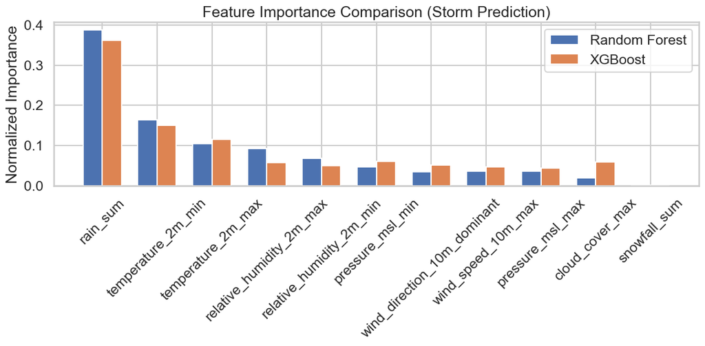

```python
import numpy as np
import pandas as pd
import matplotlib.pyplot as plt

features = X_train.columns

# --- extract importance ---
rf_importance = rf.feature_importances_
xgb_importance = xgb.feature_importances_

importance_df = pd.DataFrame({
    "feature": features,
    "Random Forest": rf_importance,
    "XGBoost": xgb_importance
})

# normalize (important for comparison)
importance_df["RF_norm"] = importance_df["Random Forest"] / importance_df["Random Forest"].sum()
importance_df["XGB_norm"] = importance_df["XGBoost"] / importance_df["XGBoost"].sum()

# top features
top_features = (
    importance_df[["feature", "RF_norm", "XGB_norm"]]
    .assign(mean=lambda x: (x["RF_norm"] + x["XGB_norm"]) / 2)
    .sort_values("mean", ascending=False)
    .head(12)["feature"]
)

plot_df = importance_df[importance_df["feature"].isin(top_features)]

x = np.arange(len(top_features))
width = 0.35

plt.figure(figsize=(12, 6))

plt.bar(x - width/2, plot_df.set_index("feature").loc[top_features, "RF_norm"], width, label="Random Forest")
plt.bar(x + width/2, plot_df.set_index("feature").loc[top_features, "XGB_norm"], width, label="XGBoost")

plt.xticks(x, top_features, rotation=45)
plt.ylabel("Normalized Importance")
plt.title("Feature Importance Comparison (Storm Prediction)")
plt.legend()

plt.tight_layout()
plt.show()
```

Correlation Heat Map:

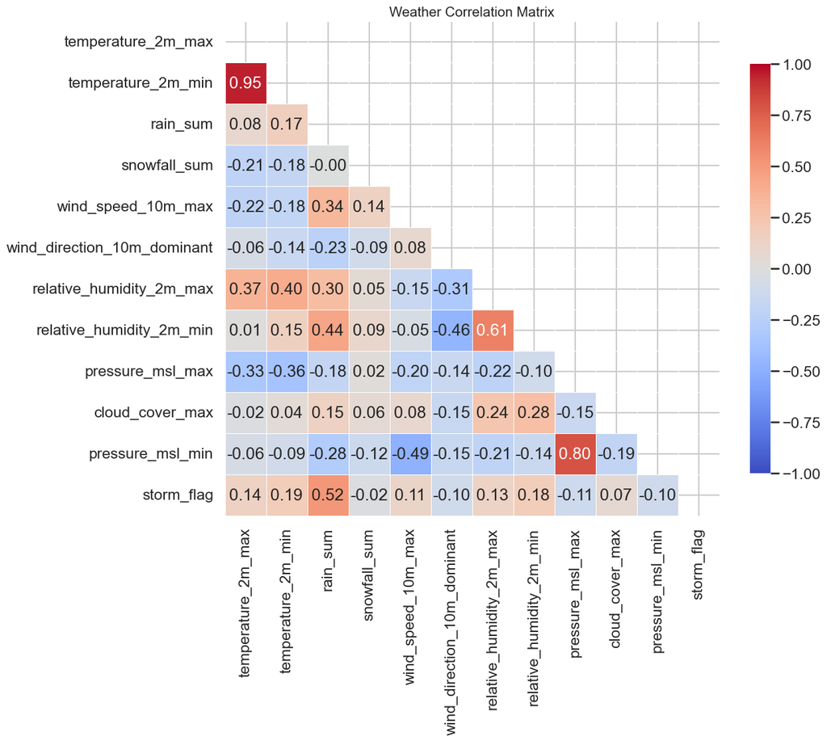

```python
import seaborn as sns
import matplotlib.pyplot as plt
import numpy as np

# Set up the figure
plt.figure(figsize=(12, 10))

# Create a mask to hide the upper triangle (it's redundant)
mask = np.triu(np.ones_like(vars_df.corr(), dtype=bool))

# Draw the heatmap with better formatting
sns.heatmap(vars_df.corr(),
            mask=mask,
            annot=True,
            fmt=".2f",
            cmap='coolwarm',
            vmax=1, vmin=-1,
            center=0,
            square=True,
            linewidths=.5,
            cbar_kws={"shrink": .8})

plt.title("Weather Correlation Matrix", fontsize=15)
plt.show()
```

Based on feature importance observation and the correlation heat map, to remove the following features from consideration due to possible threshold redundancy behavour in function or lack of predicting power:

1. temperature_2m_max,
2. pressure_msl_max,
3. relative_humidity_2m_min,
4. snowfall_sum,
5. cloud_cover_max

#### Pursuit of Classisifcation Models Based on Feature Importance

The storm_flag attributed to serve as a binary categorical target, while the features are all continuous variable types. Models that support such a constitution are logit/probit regression models, support vector machine, and ensemble models like Random forest and XGBoost. Logit/probit models are parametric as in having an explicit analytical form for direct interpretation; while the other types are non-parametric (more algorithmic or "black-box oriented") where stability and versatility with data types, and being unrestricted by hard asumptions are their advantages.

Will proceed with the logit model first, because of its transparent interpretability with predicition probabilities. Will begin with the Statsmodels framework followed by the Sklearn framework.

```python
from sklearn.preprocessing import StandardScaler

X_train_features_selected = X_train.drop(columns = ['temperature_2m_max', 'pressure_msl_max',
                                                    'relative_humidity_2m_min', 'snowfall_sum',
                                                    'cloud_cover_max'])

X_train_features_selected.info()
```

```
<class 'pandas.core.frame.DataFrame'>
Index: 15200 entries, 16528 to 16121
Data columns (total 6 columns):
 #   Column                       Non-Null Count  Dtype
---  ------                       --------------  -----
 0   temperature_2m_min           15200 non-null  float32
 1   rain_sum                     15200 non-null  float32
 2   wind_speed_10m_max           15200 non-null  float32
 3   wind_direction_10m_dominant  15200 non-null  float32
 4   relative_humidity_2m_max     15200 non-null  float32
 5   pressure_msl_min             15200 non-null  float32
dtypes: float32(6)
memory usage: 475.0 KB
```

```python
y_train.info()
```

```
<class 'pandas.core.series.Series'>
Index: 15200 entries, 16528 to 16121
Series name: storm_flag
Non-Null Count  Dtype
--------------  -----
15200 non-null  int64
dtypes: int64(1)
memory usage: 237.5 KB
```

```python
 # Initialize the scaler
scaler = StandardScaler()

# Fit and transform the data in one step
# X is your input data (e.g., a NumPy array or Pandas DataFrame)
X_scaled = scaler.fit_transform(X_train_features_selected)

# IMPORTANT: Statsmodels requires adding a constant (the Intercept)
X_sm_train = sm.add_constant(X_scaled)

# Initialize and fit the model
model = sm.GLM(y_train, X_sm_train, family=sm.families.Binomial())
result = result = model.fit_regularized(maxiter=1000)

import numpy as np

# Predicted probabilities from regularized model
p = result.predict(X_sm_train)

# Avoid log(0)
eps = 1e-10
p = np.clip(p, eps, 1 - eps)

# Log-likelihood of fitted model
ll_model = np.sum(
    y_train * np.log(p) + (1 - y_train) * np.log(1 - p)
)

# Null model (intercept only)
p_null = np.mean(y_train)

ll_null = np.sum(
    y_train * np.log(p_null) + (1 - y_train) * np.log(1 - p_null)
)

# Number of parameters (important!)
k = np.sum(result.params != 0)   # for L1 (sparse)
# OR use:
# k = len(result.params)         # for L2 (ridge)

# Adjusted McFadden R²
adj_mcfadden_r2 = 1 - ((ll_model - k) / ll_null)

print("Adjusted McFadden R²:", adj_mcfadden_r2)
```

```
Adjusted McFadden R²: 0.5010632681792884
```

For (McFadden) pseudo $R^2$:

1. 0.02–0.10 $\rightarrow$ weak
2. 0.10–0.20 $\rightarrow$ decent
3. 0.20–0.40 $\rightarrow$ strong
4. $>$ 0.40 $\rightarrow$ very strong / unusual

Yet, applied are no engineered features. Rather, observed storm events from a professional source (NOAA NCEI) integrated with historical weather data.

**The features are physically meaningful predictors of storms:**

| Variable | Storm relevance |
| --- | --- |
| rain_sum | precipitation intensity |
| wind_speed | storm dynamics |
| pressure_msl_min | cyclonic activity (very important) |
| humidity | moisture availability |
| temperature | instability proxy |
| wind direction | flow regime |

Unlike linear regression, which predicts a continuous number, Logit uses the Sigmoid function to squash the output between 0 and 1.

**The Linear Predictor ($z$)**

First, to calculate a weighted sum of the continuous features ($x_1, x_2, \dots, x_n$).

$$z = \beta_0 + \beta_1 x_1 + \beta_2 x_2 + \dots + \beta_n x_n$$

$\beta_0$ (Intercept): The "baseline" log-odds of a storm when no extreme flags are present.

$\beta_i$ (Coefficients): The weight of each specific flag. If extreme_wind has a high $\beta$, it strongly drives the prediction toward a storm.

**The Logistic (Sigmoid) Function**

To turn that linear value $z$ into a probability $p$, to pass it through the Logit Link Function:

$$p = \sigma(z) = \frac{1}{1 + e^{-z}}$$

Now, for validation with the Sklearn framework:

```python
X = vars_df.drop(columns=["storm_flag", 'temperature_2m_max',
                          'pressure_msl_max',
                          'relative_humidity_2m_max', 'snowfall_sum',
                          'cloud_cover_max' ])

y = vars_df["storm_flag"].astype(int)
```

```python
X.info()
```

```
<class 'pandas.core.frame.DataFrame'>
RangeIndex: 19000 entries, 0 to 18999
Data columns (total 6 columns):
 #   Column                       Non-Null Count  Dtype
---  ------                       --------------  -----
 0   temperature_2m_min           19000 non-null  float32
 1   rain_sum                     19000 non-null  float32
 2   wind_speed_10m_max           19000 non-null  float32
 3   wind_direction_10m_dominant  19000 non-null  float32
 4   relative_humidity_2m_min     19000 non-null  float32
 5   pressure_msl_min             19000 non-null  float32
dtypes: float32(6)
memory usage: 445.4 KB
```

```python
from sklearn.linear_model import LogisticRegression
from sklearn.model_selection import train_test_split
from sklearn.preprocessing import StandardScaler
from sklearn import metrics

# 1. Preparation
# Assuming 'X' contains your weather features and 'y' is 'storm_flag'
scaler = StandardScaler()
X_scaled = scaler.fit_transform(X)

X_train, X_test, y_train, y_test = train_test_split(
    X, y,
    test_size=0.2,
    random_state=42,
    stratify=y # Keeps value counts proportion between train set and test set similar
)

# 2. Modeling (Addressing the Separation/Overflow Issue)
# We use a smaller C (0.1) to add regularization and 'liblinear' for stability
model = LogisticRegression(C=0.1, solver='liblinear', penalty='l2', class_weight= 'balanced')
model.fit(X_train, y_train)

# 3. Probability Generation
y_probs = model.predict_proba(X_test)[:, 1]
y_pred = model.predict(X_test)

#. Classification Report
print(metrics.classification_report(y_test, y_pred))
```

```
              precision    recall  f1-score   support

           0       1.00      0.90      0.95      3700
           1       0.20      0.91      0.33       100

    accuracy                           0.90      3800
   macro avg       0.60      0.91      0.64      3800
weighted avg       0.98      0.90      0.93      3800
```

Confusion Matrix:

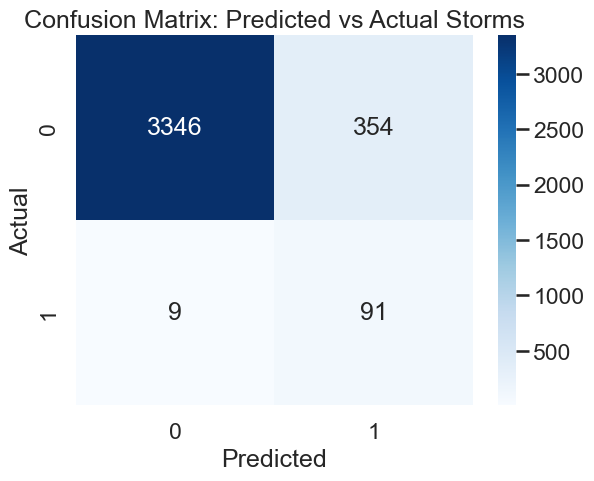

```python
conf_matrix = metrics.confusion_matrix(y_test, y_pred)
sns.heatmap(conf_matrix, annot=True, fmt='d', cmap='Blues')
plt.title('Confusion Matrix: Predicted vs Actual Storms')
plt.ylabel('Actual')
plt.xlabel('Predicted')
plt.show()
```

ROC-AUC and Brier Score:

```python
auc_score = metrics.roc_auc_score(y_test, y_probs)
brier_score = metrics.brier_score_loss(y_test, y_probs)

print(f"ROC AUC: {auc_score:.4f}")
print(f"Brier Score: {brier_score:.4f}")
```

```
ROC AUC: 0.9645
Brier Score: 0.0720
```

Feature Importance (Odds Ratios):

```python
importance = pd.DataFrame({
    'Feature': X.columns,
    'Coefficient': model.coef_[0],
    'Odds_Ratio': np.exp(model.coef_[0]) # A 1-unit increase in X multiplies odds of storm by this
}).sort_values(by='Odds_Ratio', ascending=False)

print(importance)
```

```
                       Feature  Coefficient  Odds_Ratio
0           temperature_2m_min     0.319281    1.376138
1                     rain_sum     0.205297    1.227890
3  wind_direction_10m_dominant     0.000713    1.000713
4     relative_humidity_2m_min    -0.003137    0.996868
5             pressure_msl_min    -0.007046    0.992979
2           wind_speed_10m_max    -0.025995    0.974340
```

Here is the breakdown of what these numbers are telling about the storm predictions:

**Class 0 (majority class)**

```
 Precision: 1.00 → almost no false positives for class 0 predictions

 Recall: 0.90 → you miss ~10% of actual 0s

 F1: 0.95 → strong performance
```

**Class 1 (minority class — the important one)**

```
 Precision: 0.20 → only 20% of predicted positives are correct (many false positives)

 Recall: 0.91 → you catch almost all true positives (very good sensitivity)

 F1: 0.33 → low because precision is poor
```

**Interpretation**

Model is acting like a “high recall alarm system” for class 1:

```
 It successfully finds almost all positives

 But it raises a lot of false alarms
```

**Accuracy is misleading here**

```
 Accuracy = 0.90

 But this is dominated by class 0 (which is 97.4% of data)

 So accuracy is basically saying: “you’re good at predicting the majority class” — not very informative.
```

**ROC AUC = 0.9645 (very strong)**

```
 AUC near 0.96 means your model has excellent ranking ability

 It can clearly separate positives from negatives

 The issue is not the model’s ability — it’s the decision threshold

 Hence: The model is good, but the threshold is not optimised.
```

**Brier Score = 0.072 (good calibration)**

```
 Brier score measures probability quality (lower is better)

 0.072 is quite solid

This suggests the predicted probabilities are reasonably well calibrated
```

So the model is probably predicting class 1 too aggressively

**Considerations**

Tune the decision threshold (most important)

```
 Instead of 0.5:

     Try thresholds like 0.2–0.8

 Optimise for:

     F1 score (if balance matters)

     or recall constraint (e.g., recall ≥ 0.90)
```

**Main Point:**

Very good at ranking risk (AUC 0.96), but poorly calibrated for classification decisions at the chosen threshold.

**NOTE ON NON-PARAMETRIC CLASSIFICATION AND ENSEMBLE MODELS:**

Non-parametric models generally give better results, so the logit model can be viewed as a prospect baseline.

## AMO SST Data Preliminary Data Immersion

The Atlantic Multi-decadal Oscillation (AMO) is recognised as a valid mode of natural variability occurring in the North Atlantic Ocean with an estimated period of 60-80 years. It is based upon the average anomalies of sea surface temperatures (SST) in the North Atlantic basin, typically over 0-80N (UCAR, 2026).

The Extended Reconstructed Sea Surface Temperature (ERSST) dataset is a global monthly analysis of SST data derived from the International Comprehensive Ocean–Atmosphere Dataset (ICOADS). The dataset can be used for long-term global and basin-wide studies and incorporates smoothed local and short-term variations. The NOAA Global Surface Temperature (NOAA GlobalTemp) product integrates ERSST data with land surface air temperature from the Global Historical Climatology Network-Monthly dataset to create integrated surface temperature analyses (NOAA NCEI, n.d.).

**Define the North Atlantic Mask:**

```
AMO (describing the North Atlantic) with coordinates 0°N–70°N and 80°W–0°E.
```

**Anomaly Calculation:**

```
The AMO is calculated from sea surface temperature (SST) anomalies in the North Atlantic (usually between the Equator and 60°N–80°N). Anomaly means the monthly "expected" temperature (seasonal cycle) is removed.
```

**Detrending:**

```
To isolate the internal oscillation from the external, long-term global warming trend, the AMO is often detrended. This is typically achieved by subtracting the global-mean SST anomaly (excluding the North Atlantic) from the North Atlantic SST anomalies.
```

**Smoothing (Low-Pass Filter):**

```
To remove interannual noise and focus on multidecadal variability, a low-pass filter—typically a 10-year, 11-year, or 13-year running mean (moving average)—is applied to the annual or monthly data.
```

**Alternative Definition:** Some studies have used a simple 10-year running mean of linearly detrended North Atlantic SST anomalies, **although** removing the global mean trend is generally considered more robust.

**The Trenberth Detrending (The Modern Standard)**

```
To remove the global warming signal, subtracting the global mean SST anomaly from the North Atlantic mean.
```

Before deep immersion into SST data, will have a introductory probe with a decent sample to gain understanding of the data structure before deep immersion.

**Note:** in NetCDF type data, longitudes are often 0–360. If 80°W is 280, then to adjust the slice accordingly.

Premature probing:

```python
import xarray as xr
import numpy as np

# 1. Load the subset (2015-2026)
# Matches 201x and 202x
dst = xr.open_mfdataset('ersst.v6.20[12]*.nc', combine='by_coords')
```

Chacking the latitude and longitude ranges for the data:

```python
print(dst.lat.min().values, dst.lat.max().values)
```

```
-88.0 88.0
```

```python
print(dst.lon.min().values, dst.lon.max().values)
```

```
0.0 358.0
```

Such above result confirms that for the data distribution:

1. There's (nearly) global coverage
2. Symmetric around the equator
3. Almost symmetric around the prime meridian
4. But slightly truncated at the poles (common for SST datasets like ERSST)
5. A 0-360 longitude convention.

**Features of the SST data**

1. High-frequency variability (monthly noise + signal)
2. Captures:

   ```
   short-term fluctuations

   weather-scale variability
   ```

3. Looks noisy

Practical for:

1. Doing statistical modeling
2. Linking to extreme events (EVT, hurricanes, wind, rainfall)
3. Feeding into regressions / ML models

Checking for dimension

```python
print(dst.dims)
```

```
FrozenMappingWarningOnValuesAccess({'time': 133, 'lev': 1, 'lat': 89, 'lon': 180})
```

```python
print(dst.sizes)
```

```
Frozen({'time': 133, 'lev': 1, 'lat': 89, 'lon': 180})
```

There's only one level.

Almost certainly surface SST only.

For model / reanalysis data lev can also be:

1. sigma levels (terrain-following)
2. hybrid levels

```python
print(dst.lev.values)
```

```
[0.]
```

```python
print(list(dst.variables))
```

```
['sst', 'ssta', 'lat', 'lev', 'lon', 'time']
```

```python
print(dst.lev.attrs)
```

```
{'units': 'meters', 'long_name': 'Depth of sea surface temperature measurements', 'standard_name': 'depth', 'axis': 'Z', 'positive': 'down', '_CoordinateAxisType': 'Height', 'comment': 'Actual measurement depth of in situ sea surface temperature varies from 0.2 to 10 m, but corrected to the nominal …
```

**Key interpretation:**

lev = measurement depth of SST (in meters)

“Actual measurement depth varies from 0.2 to 10 m, but corrected to nominal depth of buoy at 0.2 m”

Even though:

1. Real observations vary slightly
2. The dataset has been standardized to surface (~0.2 m)

Physically:

1. This is surface SST
2. There is NO vertical structure

Structurally --

```
Dataset still includes lev because:

    It follows NetCDF conventions

    Designed for general ocean datasets
```

Even though: lev = 1, xarray still treats your data as:

(time, lev, lat, lon)

Removal:

ds = ds.squeeze('lev', drop=True)

### Spatial Maps

Select a time range. Example: 2019-08 to 2020-01 (6 images)

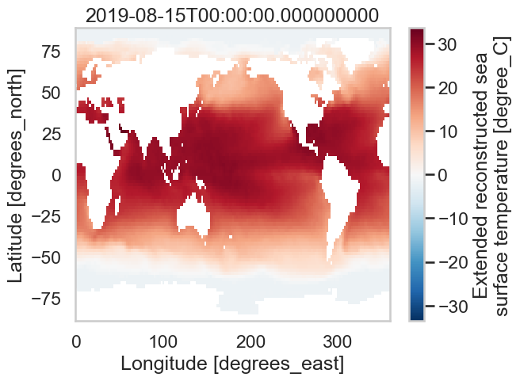

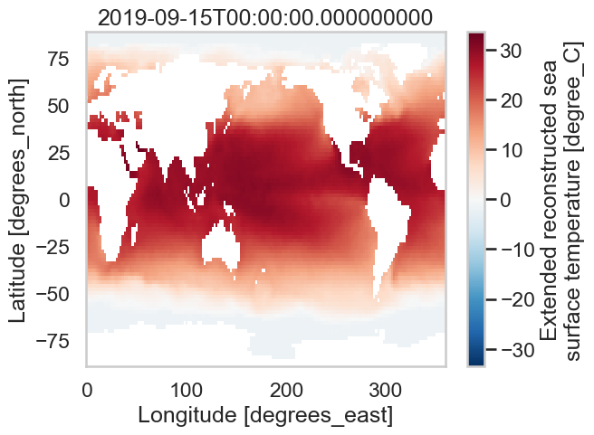

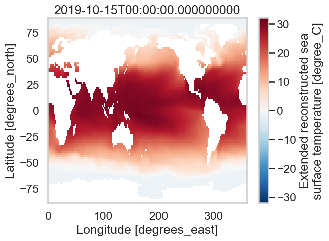

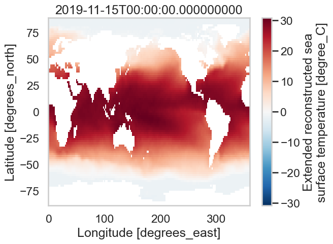

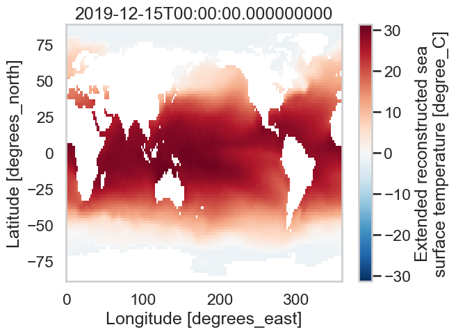

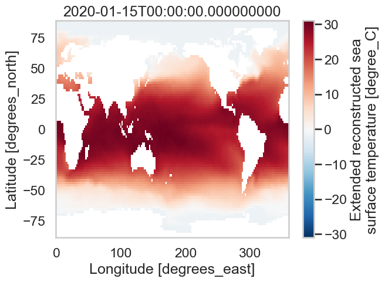

```python
ds_sub = dst.sel(time=slice("2019-08", "2020-01"))

for t in ds_sub.time.values:
    ds_sub.sst.sel(time=t).plot()
    plt.title(str(t))
    plt.show()
```

**Zonal/latitudinal structure:**

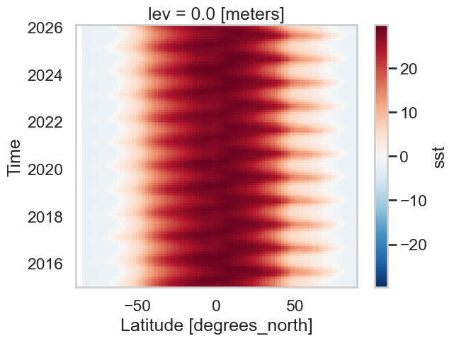

```python
sst_zonal = dst['sst'].mean('lon')
sst_zonal.plot()
```

**Weighted mean SST (climate signal):**

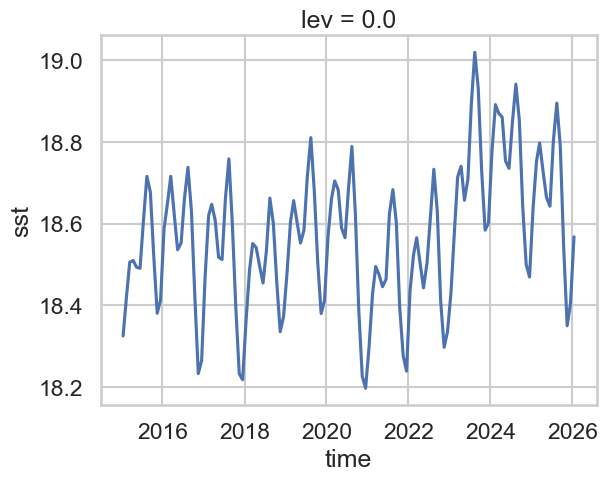

```python
weights = np.cos(np.deg2rad(dst.lat))
global_sst = dst['sst'].weighted(weights).mean(('lat','lon'))
global_sst.plot()
```

## Visualization of AMO

An initial task is to calculate and visualize the **Atlantic Multidecadal Oscillation (AMO) Index**, a climate indicator used to track long-term variations in sea surface temperatures (SST) in the North Atlantic.

Actually, what will be acquired is an **AMO Proxy** since SST is applied directly, and not a detrended basin-only Empirical Orthogonal Function (EOF) method. The actual method applied is the **Trenberth-style residual**, being a method of analysing ocean climate variability by subtracting the global-mean sea surface temperature (SST) anomaly from a regional anomaly (**the North Atlantic Region in this case**). This approach is used to remove the forced global warming trend (**not the geopolitical hot topic**) from the data, **leaving behind the local or "residual" variability** (Trenberth & Fasullo, 2009). Subtracting the global mean serves as a proxy for the externally forced signal, effectively highlighting the "relative" Atlantic warmth index—namely, how much warmer or colder the Atlantic is compared to the rest of the world. Such residual represents internal climate variability, acting to separate the total observed regional variability (e.g., a specific period of warming in the Northern Hemisphere) from the linear or non-linear trend associated with the resulting influence of human beings on nature (Merriam-Webster, n.d.).

What the analysis is achieving:

**Features of AMO smoothed**

1. Low-frequency signal ("true" AMO behaviour)
2. Captures:

   ```
     multi-year to decadal oscillation
   ```

3. Looks clean and interpretable

Practical for:

1. Visualizing climate regimes
2. Identifying:

   ```
     warm AMO phase

     cool AMO phase
   ```

3. Communicating results

Essentially, to see if the North Atlantic is currently behaving "hotter" or "colder" than its historical average once you account for the seasons and the general warming of the planet.

Will be applying SST data ranging from year 1960 to 2025.

**Spatial Aggregation (Area-Weighting)**

Since the Earth is a sphere (or actually spheroidal), grid cells near the poles represent less surface area than those at the equator. To find the mean Sea Surface Temperature (SST), $\bar{T}$, to apply a cosine-latitude weighting:

$$w(\phi) = \cos(\phi)$$

The weighted spatial mean for a region $R$ at time $t$ is defined as:

$$\bar{T}(t) = \frac{\sum_{i \in R} T_i(t) \cdot \cos(\phi_i)}{\sum_{i \in R} \cos(\phi_i)}$$

Where $T_i$ is the temperature at grid point $i$ and $\phi_i$ is the latitude.

**Climatological Detrending (Anomalies)**

To remove the seasonal cycle (e.g., the fact that summer is always warmer than winter), there's calculation of monthly anomalies. Let $m$ be the month ($1, \dots, 12$). The climatology $\mu_m$ is the long-term average for that specific month:

$$\mu_m = \frac{1}{N} \sum_{y=1}^{N} \bar{T}(m, y)$$

The anomaly $T'(t)$ is then the deviation from this seasonal mean:

$$T'(t) = \bar{T}(t) - \mu_{month(t)}$$

**The Residual Index (Signal Isolation)**

To differentiate between "North Atlantic warming" and "Global warming," the code uses a residual approach. If the whole world is warming, the Atlantic will naturally warm too; the AMO represents the Atlantic's specific behavior relative to the rest of the world.

$$I_{AMO}(t) = T'_{North Atlantic}(t) - T'_{Global}(t)$$

North Atlantic Region: $0^\circ\text{N}–70^\circ\text{N}, 280^\circ\text{E}–360^\circ\text{E}$

Global Region: $60^\circ\text{S}–60^\circ\text{N}$

This subtraction removes the common global trend, leaving behind the internal oscillation of the Atlantic basin.

**Temporal Smoothing (Moving Average)**

Finally, to suppress high-frequency weather "noise" and see the multidecadal signal, a 12-month central rolling mean is applied:

$$S(t) = \frac{1}{12} \sum_{k=-5}^{6} I_{AMO}(t+k)$$

**Variables and Logic**

| Mathematical Step | Expression | Code Implementation |
| --- | --- | --- |
| Weighting | $\cos(\text{lat})$ | np.cos(np.deg2rad(da.lat)) |
| Regional Mean | $\int T dA / \int dA$ | da.weighted(weights).mean(...) |
| Anomalies | $T - \mathbb{E}[T_{month}]$ | da.groupby("time.month") - clim |
| AMO Residual | $T'_{Natl} - T'_{Global}$ | natl_anom - global_anom |
| Smoothing | Convolution/Mean | .rolling(time=12, center=True).mean() |

```
Extracting SST regions...
```

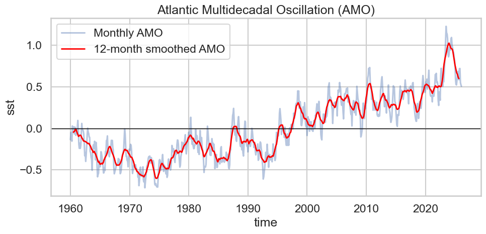

```python
import xarray as xr
import numpy as np
import matplotlib.pyplot as plt

URL = "https://psl.noaa.gov/thredds/dodsC/Datasets/noaa.ersst.v6/sst.mnmean.nc"


# ---------------------------
# 1. Load + standardize data
# ---------------------------
def load_sst(url):
    ds = xr.open_dataset(url, engine="netcdf4")

    # ensure monotonic coords (important for sel slicing)
    ds = ds.sortby(["lat", "lon"])

    # remove singleton dimensions if present
    ds = ds.squeeze(drop=True)

    return ds


# ---------------------------
# 2. Area-weighted mean
# ---------------------------
def area_mean(da):
    weights = np.cos(np.deg2rad(da.lat))
    return da.weighted(weights).mean(("lat", "lon"), skipna=True)


# ---------------------------
# 3. Regional extraction helper
# ---------------------------
def region_mean(ds, lat_range, lon_range, time_slice="1960-01-01"):
    da = ds.sst.sel(
        time=slice(time_slice, None),
        lat=slice(*lat_range),
        lon=slice(*lon_range),
    )
    return area_mean(da)


# ---------------------------
# 4. Climatology anomalies
# ---------------------------
def anomalies(da):
    clim = da.groupby("time.month").mean("time")
    return da.groupby("time.month") - clim


# ---------------------------
# 5. Main AMO workflow
# ---------------------------
ds = load_sst(URL)

print("Extracting SST regions...")

# North Atlantic (AMO region)
natl_mean = region_mean(ds, (0, 70), (280, 360))

# Global (60S–60N)
global_mean = region_mean(ds, (-60, 60), (0, 360))  # safer full lon coverage


# Ensure aligned time index
natl_mean, global_mean = xr.align(natl_mean, global_mean, join="inner")


# ---------------------------
# 6. Compute anomalies
# ---------------------------
natl_anom = anomalies(natl_mean)
global_anom = anomalies(global_mean)


# ---------------------------
# 7. AMO index (Trenberth-style residual)
# ---------------------------
amo_index = (natl_anom - global_anom).squeeze().load()


# ---------------------------
# 8. Smoothing
# ---------------------------
amo_smooth = amo_index.rolling(time=12, center=True).mean()


# ---------------------------
# 9. Plot
# ---------------------------
plt.figure(figsize=(10, 5))

amo_index.plot(alpha=0.4, label="Monthly AMO")
amo_smooth.plot(color="red", linewidth=2, label="12-month smoothed AMO")

plt.axhline(0, color="black", linewidth=1)
plt.title("Atlantic Multidecadal Oscillation (AMO)")
plt.legend()
plt.tight_layout()
plt.show()
```

Interpreting the AMO graph is essentially like looking at the "heartbeat" of the North Atlantic Ocean. Because you have removed the seasonal cycles and the global warming trend, the resulting line tells you specifically about the internal variability of the Atlantic.

**The Zero Line (The Baseline):**

1. The horizontal line at zero represents the "normal" state for the North Atlantic relative to the rest of the world.
2. Above Zero (Positive Phase): The North Atlantic is warmer than the global average. This "Warm Phase" is historically associated with increased hurricane activity in the Atlantic and wetter conditions in Western Europe.
3. Below Zero (Negative Phase): The North Atlantic is cooler than the global average. This "Cold Phase" often correlates with droughts in the African Sahel and fewer major hurricanes.

**Peaks and Valleys (The "Wiggles"):**

1. Short-term spikes: Even with a 12-month smoothing, you will see sharp peaks or dips. These are often caused by specific weather events, like a particularly mild winter or a massive dust cloud from the Sahara that temporarily shades and cools the ocean surface.
2. The Multi-decadal Trend: The "M" in AMO stands for Multidecadal. If you were to look at 50–100 years of data, you would see the line stay above or below zero for 20 to 40 years at a time.

#### Butterworth Low-Pass Filter

Targeting multidecadal variability (AMO scale). The use of a Butterworth filter combined with zero-phase filtering is a premier standard for climate indices. It provides a maximally flat frequency response in the passband and avoids shifting the peaks and troughs of the AMO cycle in time.

**The Frequency Domain Framework**

To isolate the multidecadal signal, defining a boundary in frequency space.

1. Sampling Frequency ($f_s$): Since the data is monthly, $f_s = 1 \text{ cycle/month}$.
2. Nyquist Frequency ($f_N$): The highest frequency that can be resolved by the dataset, defined as:

$$f_N = \frac{f_s}{2} = 0.5 \text{ cycles/month}$$

3. Cutoff Frequency ($f_c$): The target is a 10-year period ($T = 120$ months). The normalized cutoff used by the filter is:

$$f_c = \frac{1}{T} = \frac{1}{120} \approx 0.0083 \text{ cycles/month}$$

4. Normalised Digital Frequency ($W_n$) -- The value passed to the butter function:

$$W_n = \frac{f_c}{f_N} = \frac{1/120}{0.5} = \frac{1}{60}$$

**The Butterworth Transfer Function**

Applying a 4th-order Butterworth filter. The magnitude response $|H(f)|$ is designed to be as smooth as possible in the "passband" (the AMO frequencies we want to keep):

$$|H(f)| = \sqrt{\frac{1}{1 + \left(\frac{f}{f_c}\right)^{2n}}}$$

$n = 4$: This represents the filter order. A higher order creates a sharper "cliff" at the 10-year mark, more aggressively removing high-frequency noise like ENSO (2–7 years).

**The Difference Equation (Digital Implementation)**

In the computer, this continuous curve is converted into a discrete-time linear constant-coefficient difference equation. The values b (feedforward) and a (feedback) coefficients define the relationship between the input signal $x[n]$ and output $y[n]$:

$$\sum_{k=0}^{M} a_k y[n-k] = \sum_{k=0}^{L} b_k x[n-k]$$

Specifically, for a 4th-order filter, the output at any month $n$ is a weighted sum of the current and past 4 months of raw data, minus a weighted sum of the past 4 months of filtered data.

**Zero-Phase Filtering (filtfilt)**

A standard filter causes a phase shift (a time delay) where the filtered red line would appear to "lag" behind the raw blue data. The code solves this using the filtfilt operation --

1. Forward Pass: Filter the data from start to finish.
2. Reverse Pass: Take the result, flip it, and filter it again.Mathematically, if the filter has a frequency response $H(z)$, the total operation is:

$$|H_{total}(z)| = H(z) \cdot H(z)^* = |H(z)|^2$$

The Result: * Zero Phase Distortion: The peaks and valleys of the filtered AMO line align perfectly in time with the raw data.

1. Effective Order Doubling: The 4th-order filter effectively acts as an 8th-order filter, making the transition between "kept" and "removed" frequencies even sharper.

**Summary of Objective**

| Logic Component | Mathematical Intention | Climate Science Purpose |
| --- | --- | --- |
| Cutoff ($f_c$) | $1/120$ months | Remove ENSO and seasonal noise |
| Order ($n=4$) | Transition sharpness | H(f) |
| filtfilt | $\text{Phase}(\theta) = 0$ | Ensure 1995 peak in data stays at 1995 in plot |
| b, a coeffs | Recurrence relation | Convert continuous physics to discrete computation |

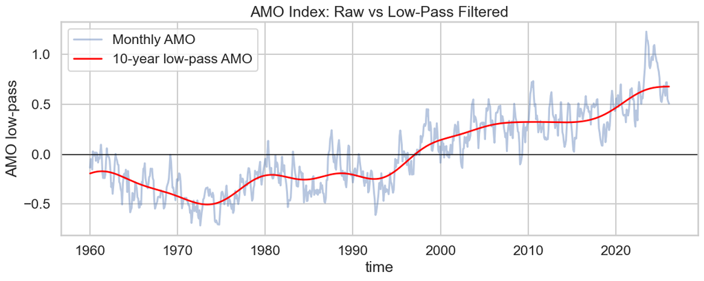

```python
from scipy.signal import butter, filtfilt
import xarray as xr
import matplotlib.pyplot as plt

def lowpass_filter(x, cutoff_years=10, dt=1):
    fs = 1 / dt
    nyquist = 0.5 * fs

    cutoff = 1 / (cutoff_years * 12)  # cycles per month
    b, a = butter(4, cutoff / nyquist, btype="low")

    return filtfilt(b, a, x)


# ---------------------------
# Apply filter
# ---------------------------
amo_lp = lowpass_filter(amo_index.values, cutoff_years=10)

# Convert back to DataArray (important for plotting properly)
amo_lp_da = xr.DataArray(
    amo_lp,
    coords=amo_index.coords,
    dims=amo_index.dims,
    name="AMO low-pass"
)


# ---------------------------
# Plot
# ---------------------------
plt.figure(figsize=(12, 5))

amo_index.plot(alpha=0.4, label="Monthly AMO")
amo_lp_da.plot(color="red", linewidth=2, label="10-year low-pass AMO")

plt.axhline(0, color="black", linewidth=1)
plt.title("AMO Index: Raw vs Low-Pass Filtered")
plt.legend()
plt.tight_layout()
plt.show()
```

#### Band-Pass AMO Extraction

The Band-Pass Filter is a formidable method to isolate the AMO because it treats the index as a "sandwich" of frequencies—discarding both the high-frequency "weather" noise and the ultra-low-frequency "climate trend" (like global warming dynamic).

**Dual Frequency Bounds**

Instead of a single cutoff, the code defines a Passband $[f_L, f_H]$. Any signal outside this range is attenuated.

1. Low-Frequency Cutoff ($f_L$): Targets the 80-year limit.

$$f_L = \frac{1}{80 \times 12} \approx 0.00104 \text{ cycles/month}$$

This removes the "DC component" or very long-term secular trends.

1. High-Frequency Cutoff ($f_H$) -- Targets the 20-year limit.

$$f_H = \frac{1}{20 \times 12} \approx 0.00417 \text{ cycles/month}$$

This removes ENSO (2–7 years) and interannual noise.

**Normalised Frequency Vector**

The scipy.signal.butter function requires these bounds to be normalized against the Nyquist frequency ($f_N = 0.5 \text{ cycles/month}$):

$$W_n = \left[ \frac{f_L}{f_N}, \frac{f_H}{f_N} \right]$$

In this specific code, the normalized passband is roughly $[0.002, 0.008]$. This narrow window is where the "pure" AMO signal is assumed to live.

**The Band-Pass Transfer Function**

For a 4th-order band-pass filter, the magnitude response $|H(f)|$ is calculated as:

$$|H(f)| = \frac{1}{\sqrt{1 + \left( \frac{f^2 - f_0^2}{f \cdot BW} \right)^{2n}}}$$

Where:

$f_0$: The geometric center frequency $\sqrt{f_L \cdot f_H}$.

$BW$: The bandwidth ($f_H - f_L$).

$n=4$: The filter order (defining the "steepness" of the skirts on both sides of the passband).

**Zero-Phase Symmetry (filtfilt)**

Just like the low-pass version, filtfilt performs a forward and backward pass. This is mathematically critical for the AMO because:

```
Phase Preservation: It ensures that a warm peak in the Atlantic in 1945 stays exactly at 1945.

Zero Bias: It prevents the filter from "smearing" the start or end of the time series into the future or past.
```

**Summary of Objective**

| Mathematical Component | Physical Meaning |
| --- | --- |
| Lower Bound ($f_L$) | Filters out Global Warming/Secular trends |
| Upper Bound ($f_H$) | Filters out ENSO, Volcanoes, and Weather |
| Order ($n=4$) | Sharpness of the frequency selection |
| btype="band" | Creates a "window" for the 20–80 year signal |

This approach permits the observation of the "internal heartbeat" of the Atlantic Ocean, stripped of the background noise of the rest of the planet.

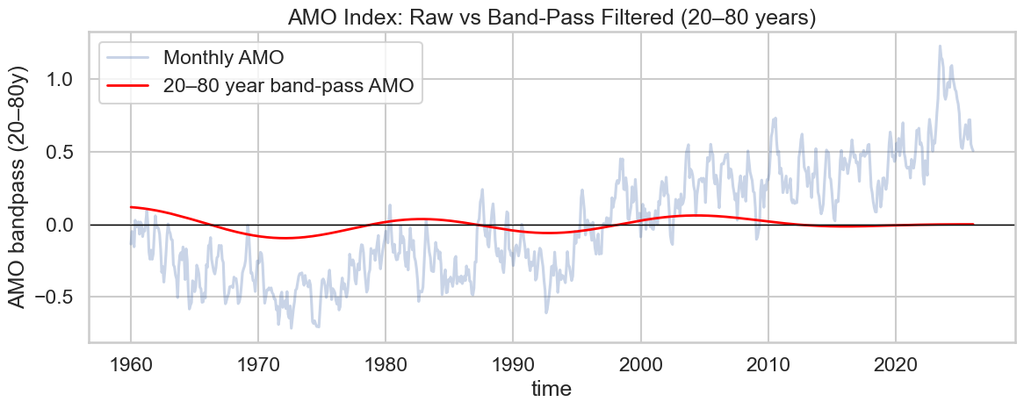

```python
from scipy.signal import butter, filtfilt
import xarray as xr
import matplotlib.pyplot as plt

def bandpass(x, low_years=20, high_years=80, dt=1):
    fs = 1 / dt
    nyq = 0.5 * fs

    low = 1 / (high_years * 12)
    high = 1 / (low_years * 12)

    b, a = butter(4, [low / nyq, high / nyq], btype="band")
    return filtfilt(b, a, x)


# ---------------------------
# Apply band-pass filter
# ---------------------------
amo_bp = bandpass(amo_index.values, low_years=20, high_years=80)

amo_bp_da = xr.DataArray(
    amo_bp,
    coords=amo_index.coords,
    dims=amo_index.dims,
    name="AMO bandpass (20–80y)"
)

# ---------------------------
# Plot
# ---------------------------
plt.figure(figsize=(12, 5))

amo_index.plot(alpha=0.3, label="Monthly AMO")
amo_bp_da.plot(color="red", linewidth=2, label="20–80 year band-pass AMO")

plt.axhline(0, color="black", linewidth=1)
plt.title("AMO Index: Raw vs Band-Pass Filtered (20–80 years)")
plt.legend()
plt.tight_layout()
plt.show()
```

**Key Components of the Above Visualization**

1. Monthly AMO (Light Blue Line): This represents the raw, unfiltered sea surface temperature (SST) anomalies in the North Atlantic. It is highly volatile, showing significant "noise" from month-to-month and year-to-year weather events.
2. 20–80 Year Band-Pass Filter (Red Line): This curve smooths out the noise to highlight multidecadal variability. By filtering for frequencies between 20 and 80 years, it aims to show the "natural" slow-moving oscillation of the Atlantic.
3. The Zero Line: Points above zero indicate warmer-than-average Atlantic temperatures (Positive Phase), while points below indicate cooler-than-average (Negative Phase).

**Trends and Observations**

1. The Decoupling Effect (Post-2010): The most striking feature is the divergence between the raw data and the filtered red line starting around 2010. While the natural cycle (red line) suggests the AMO should be trending toward a neutral or slightly negative phase, the actual monthly data remains consistently and aggressively high.
2. Recent Record Highs: Between 2020 and 2025, the Monthly AMO shows a massive spike, reaching levels significantly higher than any other period shown in the 65-year record (peaking above 1.0).
3. The "Cold Tongue" Era: The period from roughly 1965 to 1995 was dominated by a negative phase, where temperatures were consistently below the long-term average.

**Scientific Implications**

The graph highlights a major debate in contemporary climate science: Natural Variability vs. Anthropogenic Forcing (as in human activity influence on the environment).

1. Failure of the Cycle: The red line represents the traditional understanding of the AMO as a self-correcting internal oscillation. However, the fact that the actual temperatures (blue) are staying high suggests that external warming (global climate change) is now overpowering the natural cooling phase of the cycle.
2. Impact on Weather: High AMO values are historically linked to:
3. Increased Hurricane Activity: Warmer Atlantic waters provide more energy for tropical cyclones.
4. European Weather Patterns: Influence on summer rainfall and winter temperatures.
5. Sahel Rainfall: Positive AMO is often linked to wetter conditions in the African Sahel.

The analysis suggests that the North Atlantic is currently in an extreme warm state that can no longer be explained solely by multidecadal natural cycles. The "band-pass" model, which expects a return to cooler temperatures, is currently failing to track the reality of the rapidly warming ocean.

## Closing Remarks

This project attempted an integrated approach to understanding extreme weather dynamics through the combined use of historical daily observations, statistical modelling, and large-scale climate indicators.

Beginning with the use of NYC focuseded historical daily weather data, the application of extreme value analysis (EVA), providing a strong statistical framework for characterizing the tail behavior of weather variables. By focusing on extremes rather than averages, the analysis captured the low-probability, high-impact events that are most relevant for risk assessment and forecasting. This step ensured that the modelling process remained aligned with the underlying objective of understanding and predicting extreme phenomena.

Following, with the use of the high-resolution daily weather data, for analysis to establish a robust foundation by engineering meaningful features and constructing extreme weather indicators using logical operators. These flags, derived from thresholds and domain-informed criteria, transformed raw meteorological variables into actionable signals representing real-world hazardous conditions.

The project further advanced into classification and ensemble modelling, where logistic regression and tree-based methods were used to determine feature importance and estimate the probability of storm events. These models translated environmental conditions into probabilistic forecasts, highlighting how specific features influence the likelihood of extreme outcomes.

To capture deeper structure in the data, regime-based approaches such as Hidden Markov Models (HMM) were incorporated. These models revealed latent states governing weather behavior, providing insight into how different atmospheric regimes correspond to varying levels of storm risk. This regime perspective is particularly valuable, as it acknowledges that weather processes are not static but evolve through distinct underlying states.

Future extensions may include the incorporation of additional climate indices, spatial SST pattern analysis, causal inference methodologies, and advanced machine learning models. Such developments would further enhance the ability to quantify, predict, and ultimately mitigate the risks associated with extreme weather events in a changing climate.

## References

Abiy, A. Z. et al (2019). Chapter 22 - Drought and Climate Teleconnection and Drought Monitoring. In: Extreme Hydrology and Climate Variability - Monitoring, Modelling, Adaptation and Mitigation. Elsevier, Pages 275 - 295. https://doi.org/10.1016/B978-0-12-815998-9.00022-1

Baum, L. E., & Petrie, T. (1966). Statistical Inference for Probabilistic Functions of Finite State Markov Chains. The Annals of Mathematical Statistics, 37(6), 1554-1563.

Breiman, L. (2001). Random Forests. Machine Learning, 45(1), 5–32.

Cavus, Y., Stahl, K. & Aksoy, H. (2022). Revisiting Major Dry Periods by Rolling Time Series Analysis for Human-Water Relevance in Drought. Water Resour Manage 36, 2725–2739. https://doi.org/10.1007/s11269-022-03171-8

Chen, T., & Guestrin, C. (2016). XGBoost: A Scalable Tree Boosting System. In Proceedings of the 22nd ACM SIGKDD International Conference on Knowledge Discovery and Data Mining (pp. 785–794). doi.org

Coles, S. (2001). An Introduction to Statistical Modelling of Extreme Values. Springer-Verlag. doi.org

Enderton, H., & Stoll, R. R. (2026). Set Theory. In Encyclopedia Britannica. https://www.britannica.com/science/set-theory

Fisher, R. A., & Tippett, L. H. C. (1928). Limiting Forms of the Frequency Distribution of the Largest or Smallest Member of a Sample. Mathematical Proceedings of the Cambridge Philosophical Society, 24(2), 180–190.

Gnedenko, B. V. (1943). Sur la Distribution Limite du Terme Maximum d'une Série Aléatoire [On the Limiting Distribution of the Maximum Term of a Random Series]. Annals of Mathematics, 44(3), 423–453.

Hallam, S. et al (2023). The Relationship Between Sea Surface Temperature Anomalies, Wind and Translation Speed and North Atlantic Tropical Cyclone Rainfall Over Ocean and Land. Environmental Research Communications 5(2) 025007. DOI 10.1088/2515-7620/acb31c

Hamasha, M. M. et al (2022). Ultra-Fine Transformation of Data for Normality. Heliyon. 2022 May 6;8(5):e09370. doi: 10.1016/j.heliyon.2022.e09370. PMID: 35600451; PMCID: PMC9118124.

Kendall, M. G. (1975). Rank Correlation Methods (4th ed.). Charles Griffin, London.

Latif, M. (2013). Chapter 25 - The Ocean's Role in Modelling and Predicting Decadal Climate Variations. In: International Geophysics, volume 103, Academic Press, pages 645 - 665. https://doi.org/10.1016/B978-0-12-391851-2.00025-8

Mann, H. B. (1945). Nonparametric Tests Against Trend. Econometrica: Journal of the Econometric Society, 13, 245–259.

Merriam-Webster. (n.d.). Anthropogenic definition & meaning. Merriam-Webster. https://www.merriam-webster.com/dictionary/anthropogenic

National Weather Service, (n.d.). What is ENSO? National Weather Service. https://www.weather.gov/mhx/ensowhat#:~:text=The%20El%20Ni%C3%B1o%2DSouthern%20Oscillation,or%20%E2%80%9Cwesterly%20winds%E2%80%9D).

Nelsen, R. B. (1999). An introduction to copulas. Springer-Verlag.

NOAA NCEI (n.d.). Extended Reconstructed Sea Surface Temperature (ERSST). NOAA National Centers for Environmental Information. https://www.ncei.noaa.gov/products/extended-reconstructed-sst

NOAA NCEI (n.d.). Meteorological Versus Astronomical Seasons. NOAA NCEI. https://www.ncei.noaa.gov/news/meteorological-versus-astronomical-seasons

NOAA NCEI (n.d.). Storm Events Database. https://www.ncei.noaa.gov/stormevents/choosedates.jsp?statefips=-999%2CALL

NOAA NWS (n.d.). What is Flash Flooding? NOAA NWS. https://www.weather.gov/phi/FlashFloodingDefinition#:~:text=Flash%20flooding%20is%20flooding%20that%20begins%20within,growth/density%20*%20Soil%20type%20*%20Soil%20water%2Dcontent

NOAA NWS (n.d.). Winter Storms and Blizzards. NOAA NWS. https://www.weather.gov/fgz/WinterStorms#:~:text=Mountains%20Fire%20Weather-,Winter%20Storms%20and%20Blizzards,for%20significant%20drifting%20of%20snow

Open-Meteo (n.d.). Free Weather API. Open-Meteo. https://open-meteo.com/

Papagiannaki, K. et al. (2022). Identification of Rainfall Thresholds Likely to Trigger Flood Damages Across a Mediterranean Region, Based on Insurance Data and Rainfall Observations. Water, 14(6), 994. https://doi.org/10.3390/w14060994

Phoong, S. W., Ismail, M. T., & Sek, S. K. (2014). Linear Vector Error Correction Model versus Markov Switching Vector Error Correction Model to Investigate Stock Market Behaviour. Asian Academy of Management Journal of Accounting and Finance, 10(1), 133–149.

Trenberth, K. E., & Fasullo, J. T. (2009). Global Warming Due to Increasing Absorbed Solar Radiation. Geophysical Research Letters, 36(7).

UCAR (2026). Atlantic Multi-decadal Oscillation (AMO) and Atlantic Multidecadal Variability (AMV). UCAR